# 논문작성을 위한 R통계분석: Statistical analysis of papers WithR

Park Joonghee (Yonsei University coginitive Eng. lab)

2023-12-16

# 연구방법과 통계분석

**저자의 말**

이 책에서 다루고자 하는 것은 실제로 논문을 집필하거나 혹은 통계분석을 하고자 하는 경우에 실질적으로 필요한 부분과 집중해야할 부분을 담았다. 연구자로서 직접 분석을 하고 자신의 연구를 정밀하게 담고 싶은 마음은 정말 간절할 것이다. R은 무료로 이 모든 것을 가능하게 해주며, 배우는 것도 그리 어려운 것은 아니다. 그러나, R을 이용하여 통계분석을 하고자 하는 경우, 너무 기초에 매달리다보니 실제로 필요한 것을 익히는데 너무 올래걸리는 것이 현실이다. 연구자들에게 통계분석만을 목적으로 사용한다면 너무 어려운 것은 아님에도 불구하고 코드(syntax)방식이라는 이유로 벽에 부딪히는 경우가 많다. 그러나, 연구를 재현하는 관점에서 접근해보면 이러한 코드형태로 사용하는 방식은 매우 편리한 방법임에는 그 누구도 부인할 수 없다.  
본 책에서는 논문 통계분석의 절차에 따라서 사용하는 R함수와 라이브러리를 소개하여 분석하는 다양한 방법을 소개하면서 R을 익힐 수 있게 하고 있다. 함수를 일일이 기억하는 것은 매우 어려운 일이지만 상황에 맞추어서 최적의 함수를 사용하는 것은 경험으로서 기억이 잘 나고 찾아볼 수 있으므로 그러한 방식으로 분석방법을 소개하려고 한다. 분석후에는 간단하게라도 가능한 APA양식에 맞추어서 보고하는 방식을 소개하고 있다.

이 책에서는 필자가 개발한 R패키지도 사용하고 있다. jjstat라는 패키지를 이용하여 여러가지 분석의 방법과 요약기술등을 편리하게 하는 방법들을 제시하고 있다. 대체로 분석하는 것에 대한 함수는 잘 발달해있지만, 이를 정리하여 논문에 넣기위한 함수나 정리방법은 좀 미흡한 편이다. 따라서, 필자는 분석을 편리하게 하는 방법과 그리고, 결과물을 만들기 위해서 도입해야 하는 함수들을 모아서 jjstat라는 패키지로 담았다.

# 1. 데이터에 대한 이해

## 1. 논문을 위한 기본 개념

### 1.1. 연구주제의 선정

연구 주제 선정의 중요성  
논문 작성의 첫 걸음이자 성공적인 연구의 핵심 요소는 바로 연구 주제의 선정이다. 잘 선택된 주제는 연구의 방향성을 제시하고, 명확한 목표 설정을 가능하게 하며, 학문적 기여도를 높여주게 된다. 반대로, 부적절한 주제는 연구의 어려움, 시간 낭비, 학문적 가치 감소로 이어질 수 있다.

**연구 주제 선정을 위한 5가지 전략**

1. 관심 분야 및 전문성 고려:  
   자신의 관심 분야와 전문 지식을 기반으로 주제를 선정하면 연구에 대한 열정과 몰입도를 높일 수 있다. 이미 갖춘 지식을 바탕으로 연구를 시작하면 학습 곡선을 단축하고 연구 효율성을 높일 수 있다.
2. 최신 동향 및 학문적 격차 파악:  
   최신 학문적 트렌드와 연구 동향을 파악하여 미래 지향적인 주제를 발굴하고, 학문적 격차를 채울 수 있는 연구를 진행하는것이 좋다. 학술 논문, 학회 발표, 전문가 의견 등을 참고하여 최신 연구 동향을 파악하는 것도 매우 중요하다.
3. 연구 가능성 및 실현 가능성 평가:  
   연구 주제의 연구 가능성을 평가하여 성공적인 연구 수행 가능성을 높일 수 있는 방법을 찾아본다. 연구 자료, 방법론, 윤리적 문제 등을 고려하여 연구 가능성을 평가한다. 이때 중요한 것은, 실현 가능성을 위해 연구 시간, 예산, 인력, 장비 등 현실적인 제약 조건을 고려하는 것이 중요하다.
4. 학문적 기여도 및 사회적 영향력 검토:  
   연구 주제의 학문적 기여도와 사회적 영향력을 검토하여 연구의 가치를 높여야 한다. 연구 결과가 학문 분야에 어떤 기여를 할 수 있는지, 사회에 어떤 영향을 미칠 수 있는지 고려한다.
5. 명확한 연구 질문 및 가설 설정:  
   연구 주제를 바탕으로 명확한 연구 질문과 가설을 설정하여 연구 방향성을 명확하게 제시한다. 연구 질문은 연구의 핵심을 요약하고, 가설은 연구 결과를 예측하는 명제이므로 철저한 선행연구와 연구자의 깊은 고민을 통해서 가설에 대한 예측을 하는 것이 중요하다.

# 2. 기초통계분석

## 2.1. 연구에 관한 이해

이제 연구에 필요한 지식을 간단하게 이야기를 하고자 한다. 연구가설, 귀무가설, 대립가설, 연구가설의 유형, 1종오류와 2종오류, 연구모형 설정, 유의수준과 신뢰수준, 유의확률 및 통계적 의사결정에 대한 이해를 하고자 한다.

### 연구가설과 귀무가설

연구 가설은 연구 결과를 예측하는 명제이다. 연구가설은 연구 질문을 바탕으로 설정하며, 연구의 방향성을 제시하고 검증 가능성을 제공하므로, 명확하고 구체적인 가설 설정은 연구의 성공에 중요한 역할을 하게된다.

효과적인 연구 가설 설정 방법을 알아보자.

먼저, 명확하고 구체적인 표현을 해야 한다. 연구 질문에 대한 직접적인 답변을 제공하고, 체계적인 선행연구를 통하여 측정 가능한 변수를 포함해야 한다. 둘째, 검증이 가능해야 한다. 경험적 또는 논리적 방법으로 검증 가능한 연구여야 한다. 셋째, 관련성이 있어야 한다. 연구가설은 선행 연구와 이론적 근거를 바탕으로 설정해야 한다. 특히 조심해야 할 것은 연구자의 개인 경험에 의존해서는 안된다는 것이다. 대체로 선행연구가 부족한 경우 자신의 경험으로 모든 가설을 설정하는 경우가 있는데 이는 피해야 한다. 넷째, 단순해야 한다. 즉 이해하기 쉽고 불필요한 복잡성을 피해야 한다는 것이다. 다섯째, 파괴력이 있어야 한다. 기존 이론이나 가설에 대한 새로운 도전을 제시하는 것이 바람직하다.

연구가설의 예를 들어보자.  
연구 질문: 온라인 학습 참여도가 학습 성취도에 미치는 영향은 무엇인가?  
연구 가설: 온라인 학습 참여도가 높을수록 학습 성취도가 높아질 것이다.

**대립가설 (Alternative Hypothesis)** :

연구자가 검증하고자 하는 가설이다. 즉 연구 결과에 대한 예상이나 가정을 나타낸다. 보통 “H1”로 표기하며, 예를 들어 “A 치료법은 B 치료법보다 더 효과적이다”와 같은 가설이 연구가설을 말한다.

**귀무가설 (Null Hypothesis)**:

연구자가 연구가설을 검증하기 위해 반박하려는 가설이다. 통계적 검정에서 기본적으로 설정되는 가설이다. 보통 “H0”로 표기하며, 예를 들어 “A 치료법과 B 치료법은 효과적인 차이가 없다”와 같은 가설이 귀무가설이다. 연구가설과 귀무가설은 통계적 검정에서 중요한 역할을 하며, 연구 결과를 평가하고 결론을 도출하는데 사용된다.

**연구 가설의 유형**:  
연구가설의 유형으로는 다음과 같은 것들이 있다.  
- 서술적 가설: 두 변수 간의 관계를 단순히 서술하는 가설  
- 관계적 가설: 두 변수 간의 방향 또는 강도를 명시하는 가설  
- 원인적 가설: 한 변수가 다른 변수에 영향을 미치는 관계를 명시하는 가설

### 제 1종오류와 2종 오류

1종 오류와 2종 오류는 통계적 검정에서 중요한 개념이다.

**1종 오류 (Type I Error)**:  
- 의미: 귀무가설이 실제로 참인데도, 이에 불구하고 귀무가설을 기각하는 오류이다. 예를 들어보면, 의사가 환자에게 병이 없다고 진단했는데, 실제로는 병이 없는 경우이거나, 신약의 효과가 없는데 있다고 잘못 판단한 경우 등이다.

**2종 오류 (Type II Error)**:  
- 의미: 귀무가설이 실제로 거짓인데도, 이에 불구하고 귀무가설을 기각하지 못하는 오류이다. 예를 들면, 의사가 환자에게 병이 있다고 진단했는데, 실제로는 병이 있는 경우이다. 혹은 신약의 효과가 있는데 없다고 잘못 판단한 경우이다.  
이 두 오류는 통계적 검정에서 발생할 수 있으며, 연구 결과를 평가하고 결론을 도출하는데 중요한 역할을 한다. 1종 오류는 실제 음성인 것을 양성으로 판정하는 경우이고, 2종 오류는 실제 양성인 것을 음성으로 판정하는 경우이다.

### 연구모형의 설정

연구 모형은 연구 변수 간의 관계를 시각적으로 표현한 도식으로, 연구 가설을 검증하기 위한 구조를 제시하며, 연구 변수 간의 상호 작용을 이해하는 데 도움을 준다.

연구 모형 설정 방법은 다음과 같다. (1) 연구 가설을 기반으로 연구 가설을 검증하기 위한 변수와 그 관계를 명확하게 설정해야 한다. (2) 변수 선정시에는 연구 질문과 가설에 부합하는 주요 변수를 선정하고, 변수 간의 논리적 관계를 설정한다. (3) 변수 간의 관계를 화살표로 표현하여 나타낸다. 화살표 방향은 영향 관계를 나타낸다. (4) 모형 유형의 설정을 한다. 연구 목적에 따라 다양한 모형 유형을 선택할 수 있다. 예를 들어, 경로 분석, 구조 방정식 모델링, 회귀 분석 등이 있다.

### 연구 가설 및 연구 모형 설정 시 고려해야 할 사항

1. 연구의 목적과 범위:  
   연구 목적과 범위를 명확하게 설정해야 연구 가설과 연구 모형을 효과적으로 설정할 수 있다.
2. 선행 연구:  
   선행 연구 결과를 참고하여 연구 가설과 연구 모형을 설정하는 것이 바람직하다.
3. 통계적 검증 가능성:  
   연구 가설과 연구 모형은 통계적 방법으로 검증 가능해야 한다.
4. 윤리적 문제:  
   연구 가설과 연구 모형 설정 과정에서 윤리적 문제를 고려해야 합니다.

### 유의수준과 신뢰수준, 유의확률

1. 유의수준 (α):  
   귀무가설이 사실인데도 불구하고 기각할 확률을 의미한다. 일반적으로 0.05 또는 0.01로 설정한다.
2. 신뢰수준 (1-α):  
   귀무가설이 사실인 경우 기각하지 않을 확률을 의미한다. 즉, 연구 결과가 신뢰할 수 있는 정도를 나타낸다.
3. 유의확률 (p-value):  
   표본 데이터에서 관찰된 결과가 우연히 발생할 확률을 의미한다. 유의확률이 유의수준보다 작으면 귀무가설을 기각하고 대립가설을 채택한다.

### 통계적 의사결정

통계적 의사결정 과정은 데이터를 기반으로 합리적인 의사결정을 내리는 과정이라고 할 수 있다. 불확실성이 존재하는 상황에서 데이터 분석을 통해 가능성을 추정하고, 이를 바탕으로 최적의 선택을 하는 방법을 통계적 의사결정이라고 한다.

**통계적 의사 결정 단계**

통계적 의사결정 과정은 다음과 같은 단계로 구성됩니다.

가. 연구 목적 설정  
먼저, 연구 목적을 명확하게 설정해야 한다. 이를 통해 필요한 데이터를 수집하고 적절한 분석 방법을 선택할 수 있다.

나. 가설 설정  
연구 목적에 따라 귀무가설과 대립가설을 설정한다. 귀무가설은 일반적으로 유지하고자 하는 가설이며, 대립가설은 귀무가설을 기각할 때 채택되는 가설이다.

다. 데이터 수집 연구 목적에 맞는 데이터를 수집한다. 데이터 수집 방법에는 설문조사, 실험, 관찰 등이 있다. 물론 연구방법에 따라 양적연구와 질적연구의 수집방법에는 차이가 있다.

라. 데이터 분석  
수집된 데이터를 분석한다. 데이터 분석 방법에는 다양한 통계 검정 방법을 사용하며 특히 연구목적과 연구문제를 잘 설명해주고, 근거를 마련해줄 수 있는 통계적 검정 방법을 시행하여 분석한다. 특히 연구자는 자신이 분석할 연구에 대하여 명확히 이해하고 이 연구문제를 잘 설명해줄 적절한 통계기법을 사용해야 한다.

바. 결론 도출  
데이터 분석 결과를 바탕으로 귀무가설을 기각하거나 유지한다. 귀무가설을 기각하면 대립가설을 채택한다.

사. 의사결정  
데이터 분석 결과와 결론을 바탕으로 최종적인 의사결정을 내린다.

## 2.2. 데이터의 처리와 이해

이제 데이터를 처리하는 방법 및 변형하여 분석에 적합하게 구성하는 방법을 알아보고자 한다.

### 2.2.1. 데이터 사례 추출 및 변수 추출

데이터의 결합에는 열결합과 행결합, 공통열에 의한 결합등이 있다. 데이터 프레임을 다루다보면 행의 이름을 변수로 만들어야 하는 경우가 더러 생긴다. 이런 경우 빠르게 만드는 방법을 먼저 알아보자.

#### 2.2.1.1. 데이터에 행번호 붙이기

먼저 R에서 데이터를 다룰때 행이름을 열의 변수로만들어야 하는 경우가 자주 생긴다. 최근 R에서는 data.frame및 tibble데이터가 자주 사용되면서, 행이름(rownames)를 열 변수로 포함해서 분석해야 하는 경우가 자주 생기기 때문이다. mtcars데이터를 이용하여 이 과정을 살펴보자.

```r
mtcars %>% head()
```

데이터에서 행이름을 추출하는 방법은 rownames()를 이용한다.

```r
rownames(mtcars)
```

데이터의 열이름을 추출하는 방법은 colnames()를 이용한다.

```r
colnames(mtcars)
```

행이름을 열에 포함하는 방법은 tibble::rownames_to_column()을 이용하는 것이다. 이함수에는 인수로는 data와 변수명을 정하는 var가 있다. 이 기능은 분석한 데이터를 정리해서 출력되는 표를 만들 때 상당히 유용한 기능이다.

```r
mtcars  %>%
  tibble::rownames_to_column(var = "car")  %>%
  head()
```

이러한 변환에 사용하는 함수로는 다음과 같은 것들이 있다.

```
has_rownames(.data)
remove_rownames(.data)
rownames_to_column(.data, var = "rowname")
rowid_to_column(.data, var = "rowid")
column_to_rownames(.data, var = "rowname")
```

#### 2.2.1.2. 데이터 선택과 추출

이 함수는 데이터의 일부를 추출하는 기능이다. dplyr패키지의 filter()와 select() 함수의 기능을 동시에 활용이 가능한 함수이다. 다만 사용성에서 dplyr보다는 직관적성은 떨어지지만, 매우 유용한 기능이다.

일반적으로 R에서의 데이터프레임은 인덱싱을 하는 방법이 여러가지가 있다. 먼저 $ 기호를 이용하여 변수를 추출한다. 변수를 추출할 때, 벡터로 추출하는 방법과 데이터프레임으로 추출하는 방법이 있다.  
##### (1) R-base방법

```r
mtcars$mpg
```

두번째로는 [[]]기호를 이용하여 번호를 이용해서 추출한다.

```r
mtcars[[1]]
```

데이터에 변수명을 넣어서 벡터로 추출할 수 있다. ’데이터[, 변수명]’으로 벡터를 추출할 수 있다.

```r
mtcars[,"mpg"]
```

벡터로 추출된 형태에서 데이터프레임으로 만들어서 추출하려면 drop = FALSE 옵션을 사용한다.

```r
mtcars[,"mpg",  drop=FALSE]  %>%  head()
```

기호를 사용할 때 []를 한번만 사용하면 데이터프레임으로 추출이 된다.

```r
 mtcars[1]  %>%  head()
```

데이터[변수명]만 넣으면 데이터 프레임으로 추출이 된다.

```r
mtcars["mpg"]  %>%  head()
```

**조건에 맞는 데이터 추출**  
조건을 사용할 때에는 데이터[데이터$변수에 대한 조건 ,]으로 해서 열에 대한 성분을 추출한다. 예를 들어 mpg값이 30보다 큰 값을 추출해보자.

```r
mtcars[mtcars$mpg > 30 ,1:8]
```

범주형 변수에 대하여 이용하여 추출하면 다음과 같이 할 수 있다.

```r
mtcars[mtcars$cyl == 6, 1:8]
```

##### (2) subset을 이용한 추출

subset을 이용하면 인수는 데이터와 행을 선택하는 ‘subset= 행성분’ 인수와 열을 선택하는 select변수가 있다. 보통은 데이터에 대하여 subset을 이용하여 조건을 사용하여 추출이 가능하다. 함수명과 인수가 같은 용어라서 헷갈릴 수 있지만, 함수와 인수를 명확히 구분하면 사용이 불편하지 않을 것이다.

먼저, mtcars데이터에서 mpg값이 30이상이 되어야한다고 생각할 때, subset = mpg > 30으로 설정하여 추출한다.

```r
mtcars[,1:5]  %>%
  subset( subset = mpg > 30)
```

동일한 방법으로 다음과 같이 인수를 select로 이용하여 열을 선택하는 방법도 있다. select를 사용할 때는 여러개의 변수를 선택해야 하므로 c()를 사용한다.

```r
mtcars  %>%
  subset( subset=(mpg) > 30, select=c(1:5))
```

열변수를 선택할 때, 번호를 이용하여 선택해도 된다. 필요한 변수의 열의 위치를 알면 그 번호를 선택하여 변수를 선택할 수 있다.

```r
mtcars  %>%
  subset( select = c(1, 2))  %>%
  head()
```

변수명을 직접 안다면 변수를 직접 설정해서 선택해도 된다. 이 역시도 c()을 이용하여 선택하면 된다.

```r
mtcars  %>%
  # subset( select = c("mpg", "cyl"))  %>%
  subset( select = c("mpg", "cyl"))  %>%
        head()
```

##### (3) tidyverse의 select, filter이용한 추출

이번에는 tidyverse를 이용하여 mtcars데이터에서 mpg값이 30이상의 값을 추출해보자. 조건은 mpg > 30으로 설정하여 추출한다.

```r
mtcars[,1:5]  %>%
  filter( mpg > 30)
```

mpg > 30 이상이면서 열을 1~5열까지를 추출해보자. v

```r
mtcars  %>%
  filter(mpg > 30)  %>%
  select(1:5)
```

select함수도 역시 변수명을 안다면 변수 이름을 직접 지정해서 추출할 수 있다. 다만, “cyl”와 같이 입력하면 오류가 나고 그냥 cyl을 입력해야 변수로 인식한다.

```r
mtcars  %>%
  select(mpg, cyl)  %>%
  head()
```

#### 2.2.1.3. 변수 생성 및 변수 변환

transform()을 이용하여 변수를 생성하거나 변환하는 방법은 dplyr::mutate()와 같은 역할을 한다. 인수로는 데이터을 넣고, 나머지 인수는 변환이나 생성에 관한 식을 넣으면 된다. 이 파트에서는 가능한 R-base에 존재하는 함수를 최대한 사용하여 분석하는 방법을 제시했다.

**변수리코딩**  
먼저 변수를 factor로 변경하는 변환을 해보자. 먼저 기본적인 base R에서 하는 방법과 transform을 이용한 방법을 사용해보자.

1. R-base에서 변수 리코딩

일단적으로 factor()처리를 하기 위해서 사용하는 방법을 아래에 설명했다.

```r
#R- base
data(mtcars)
Mtcars <- mtcars
# Engine (0 = V-shaped, 1 = straight)
Mtcars$vs = factor(Mtcars$vs,
                   levels = c(0,1),
                   labels = c("V_shaped"," straight") )

Mtcars$vs
```

다음은 transform()을 이용하여 변수를 변형한 것이다.

2. transform()을 이용한 리코딩

```r
#transform
data(mtcars)
Mtcars1 <- mtcars
# Engine (0 = V-shaped, 1 = straight)
Mtcars1  %>%
  transform(vs = factor(vs,
                        levels=c(0,1),
                        labels=c("V_shaped"," straight"))) %>%
  head(10)
```

3. dplyr::mutate()에서 변수 리코딩

dplyr::mutate()에서 변수를 factor로 만드는 과정을 다시 한번 해보도록 하자. dplyr::mutate는 library(tidyvers) 혹은 library(dplyr)을 수행한 후에는 그냥 mutate만 써도 된다. 독자들에게 어떤 패키지이지 정화히 알려주기 위해서 패키지명을 앞에 쓴 것이다.

```r
data(mtcars)
Mtcars2 <- mtcars

Mtcars2  %>%
  dplyr::mutate(vs = factor(vs, levels=c(0,1), labels=c("V_shaped"," straight")))  %>%
  head(10)
```

(4)새로운 변수의 생성

예륻 들어 새변수 두 변수의 평균 혹은 합을 이용하여 새로운 변수를 만든다고 하자. 그런 경우에는 R-base와 trandfomrm(), aplyr::mutate()를 사용하면 편리하게 만들 수 있다. 몇개이 함수의 합이나 평균을 구하거나 혹은 요인에 맞는 항목을 묶어 항목묶음(Item parceling)을 하는 경우에 새로운 변수를 만들어 내는 경우가 많다.

```r
mtcars  %>%
  transform(sum_hp_wt = hp + wt)  %>%
  subset(select=c(mpg, hp, wt, sum_hp_wt))  %>%
  head(10)
```

두 변수의 평균을 구해서 하나의 변수 생성하는 경우는 다음과 같이 직접 식을 입력한다.

```r
mtcars  %>%
  transform(mean_hp_wt = (hp + wt)/2 )  %>%
  subset(select=c(mpg, hp, wt, mean_hp_wt))  %>%
  head(10)
```

**airquality 데이터를 이용하여 변수 생성 연습** airquality(New York Air Quality Measurements) 데이터는 1973년 5월부터 9월까지 뉴욕의 일일 대기질 측정한 데이터이다. 이 데이터를 이용하여 새로운 변수를 리코딩해보도록 하자. 먼저 오존(Ozone)데이터에는 부호를 바꾸고, 온도에 대한 단위를 변경해서 새롭게 데이터를 만들어보려고 한다.

```r
airquality  %>%  head()
```

airquality에 나타나는 Temp는 화씨($℉$) 로나타나있다.
이것을 섭씨$℃$ 로 바꾸는 것을 해보자. 바꾸는 공식은 다음과 같다.
$$℃ = \frac{ ℉
- 32}{1.8}$$
이것을 새로운 변수를 변수를 만들 때 사용할 수 있다.
원래 변수명을 입력하면 데이터의 내용이 교체되어 원본데이터가 없어지기 때문에 가능한 새로운 데이터를 만들어서 사용하는 것을 권장한다. C_Temp라는 변수명을 만들어서 섭씨로 전환시킨 변수를 새롭게 하는 것은 아래 코드에서 확인할 수 있다.

```r
# transform(airquality, Ozone = -Ozone)
#Ozone은 new변수로 마이너스를 붙여서 생성
# F(Fahrenheit )   -> C(Celsius)  = (F-32)/1.8
transform(airquality, new = -Ozone, C_Temp = (Temp-32)/1.8)  %>%
  head()
```

#### 2.2.1.4. 역코딩

**변수변환 처리 recode**  
다음은 일반적으로 변수를 리코딩, 즉 역코딩을 하는 방법이다.if문을 사용하면 너무 복자하게 된다. 따라서, 이련 경우는 dplyr::case_when()을 이용하여 바꾸면 된다. `조건 ~ 내용`형식으로 적용한다.

```r
library(dplyr)
# generate data
y <- seq(1, 5, by = 1)
## recoding variable
data.frame(y) %>%
  mutate(rev = case_when(
            y == 5 ~ 1,
            y == 4 ~ 2,
            y == 3 ~ 3,
            y == 2 ~ 4,
            y == 1 ~ 5
        ))
```

그러나, 매번 역코딩에서는 이러한 방법으로 코딩하여 바꾸는 것은 불편한 일이다.  
따라서, 역코딩 기법을 이용하여 변수를 변환하는 것이 더 좋은 방법이 된다.  
역코딩 방법 데이터를 역코딩 하는 방법은 단순하다. 5점 척도라면, 다음과 같은 규칙으로 바꾸면 된다.

$$5->1,\;\;4->2,\; \quad
3->3,\;\quad 2->4,\quad 1->5$$

이렇게 만드는 방법은 5점 척도이면 $역코딩 = 6 - 변수$로 하면 된다. 7점척도이면 8-변수로 하여 게산하면 자연습럽게 계산이 된다. 그렇다면 4,6,8로 구성된 변수라면 어떻게 하면될까? 생각해보면 간단한 문제이다. 12-변수를 하면 된다. 8->4로, 6->6으로, 4->8로 만들려면 가장 작은수(minimun value)와 가장 큰 수(Maximum value)를 더한 값에서 각각의 변수를 빼는 것이 역코딩의 원리이다.

그렇다면, mtcars에서 cyl변수를 역코딩해서 확인해보도록 하자. 이때 12(= 4+8)에서 빼게 되는 이유는 최솟값 4와 최대값 8의 합을 이용하여 빼야 반대로 나타나기 때문이다.

역코딩을 하기 위해서 사용하는 함수는 R-base에서는 transform()함수이다. transform(변형시키다 (=convert))라는 단어에서 볼 수 있듯이 이 함수는 새로운 변수를 만들거나 혹은 리코딩해서 변수를 수정해야 하는 경우 매우 편리한 함수이다. transform(Transform an Object, for Example a Data Frame)은 변환을 하는 함수이며, 데이터프레임을 받아서첫 번째 인수를 데이터프레임으로 변환하는 함수이다. 변환을 한 후에 subset(select = c(cyl, cyl_reverse)을 사용한 것은 변환된 것만을 보이게 하기 위해서 변수를 선택한 것이다.

```r
mtcars  %>%
   transform(cyl_reverse = 12- cyl)  %>%
   subset(select = c(cyl, cyl_reverse))  %>%  # 변수를 선택: 원래변수와 역코딩된 변수만 선택
   head(n= 10)
```

결과를 보면, 각각의 값이 역코딩 되어 들어가 있는 것을 확인할 수 있다. 그리고, 역코딩한 변수를 만들때에는 원래의 변수를 바꾸기 보다는 새로운 변수를 만드는 것을 추천한다. 분석을 하다가 원래것으로 다시 돌리는 일도 생기기 때문에 가능한 역코딩을 한 변수는 새로운 변수를 만드는 것이 낫다.

tidyverse 패키지를 이용하여 mutate를 이용하는 방법도 있다. 일반적으로 타이디버스(tidyverse)를 이용하는 방법이 더 만힝 알려져있고, mutate(;(새로운 형태로) 변형되다)라는 단어의 의미가 직관적이이기 때문에 함수를 기억하기 좋다는 장점이 있다. 또한 필자의 입장에서는 변수를 선택함에 있어서 select()도 subset()보다는 활용하기가 더 편리하다는 생각이 든다. 여하튼 tidyverse는 여러 가지 면에서 활용하기 좋은 패키지이다.

```r
library(tidyverse)

mtcars  %>%
   mutate(cyl_reverse = 12- cyl)  %>%
   select(cyl, cyl_reverse)  %>%
   head(n= 10)
```

**jjstat를 이용한 역코딩 방법: rc, rev_coding, revcode**  
역코딩을 하는 것은 어려운 것은 아니지만, 역코딩을 직접적인 코딩을 하다보면 실수가 자주 생기곤 한다. 그래서 이러한 부분에서 함수를 이용하여 실수를 줄이는 것도 좋은 방법이 된다. 보통 교육학 연구나 심리학 및 경영학 연구에서는 여러 가지 면에서 주의(attention)을 주기 위해서 측정도구내에 역코딩을 하는 경우가 많다보니 변수의 역코딩을 자주 활용하게 된다.

이때 사용하면 좋은 것이 jjstat패키지의 rc() 혹은 rev_coding()함수이다. 이를 이용하여 역코딩을 해보면 된다. 옵션으로 n은 리커트 척도에서 설정된 값을 최솟값+최댓값의 합을 입력해야 한다. 즉, 1~5점 척도는 n = 6이고, 1~7점 척도이면 n=8이다. 그리고, 인수중에서 check = TRUE로 하면 원래의 소스와 역코딩된 값을 함께 보여주어 제대로 잘 변환이 되었는지 점검을 할 수 있다.  
rc과 rev_coding의 함수는 같은 함수인데, 하나는 이름을 명확하게 하기 위해 이름을 길게 둔 것이고 익숙해지면 쉽게 사용할 수 있도록 이름을 줄여놓은 함수이다.

```r
jjstat::rc(mtcars$cyl, n=12)
```

이번에는인수에서 check = TRUE로 설정한 경우를 보자. 결과값을 확인해보면, 원래의 입력된 소스와 역코딩된 결과를 확인할 수 있다. check는 제대로 코딩이 되었는지 점검용으로 확인하기 위한 인수이다.

```r
jjstat::rc(mtcars$cyl, n = 12, check=TRUE)  %>%  head(10)
```

이것을 데이터내에서 활용하려고 하면, tidyvers함수들과 함께 이용하려면 새로운 변수를 만들때 유용하다. 먼저 두가지 rc()함수나 rev_coding()함수를 이용하면 된다.

1. rc함수이용

```r
mtcars  %>%
   mutate(cyl_reverse = rc(cyl, 12))  %>%    # reverse code(간편한 이름 )
   select(cyl, cyl_reverse)  %>%
   head()
```

(2) rev_coding함수 이용

```r
mtcars  %>%
   mutate(cyl_reverse = rev_coding(cyl, 12))  %>%    # reverse code(명확한 이름 )
   select(cyl, cyl_reverse)  %>%
   head()
```

그런데, 한 두개의 변수를 처리할 때에는 나름대로 괜찮지만, 데이터내에서 여러개의 변수를 역코딩히야 하는 경우는 이또한 상당히 불편해진다.  
따라서 데이터 내에서 이를 처리하는 것을 알아보자.

#### 2.2.1.5. 데이터내에서 한번에 처리하기

데이터 내에서 처리하려면 jjstat::revcode을 이용하면 된다. 인수로는 데이터를 받아서 n(= max + min)을 지정하고, 변수명을 선택하면 된다. cyl의 변수를 역코딩을 해보자. cyl은 4, 6,8로 구성이 되어있어서 4->8로 6->6으로 8->4로 바꾼다.  
데이터에 변환된 것을 쉽게 보이게 하기 위해서 select함수를 이용하여 필요한 변수를 선택하여보이게 하였다.  
먼저 데이터에서 tidyverse를 통해서 생성하는 것이 아니라 그냥 데이터 내에서 처리하는 방법이다. 아래의 코드는 데이터가 길어서 보기 힘들수 있어서 알아보기 쉽게 데이터를 구성하여 역코딩한 결과를 보여주었다.

```r
MTCARS <- mtcars %>%  select(mpg, am, vs, gear, carb, cyl) #변수의 선택
MTCARS  %>%  jjstat::revcode(n=12, "cyl")  %>%

  head()
```

revcode함수는 변수하나만을 할 수 있는 것이 아니라, 여러개의 변수를 바꿀 수도 있다. 이번에는 mtcars데이터의 vs, am은 0,1로 코딩된 데이터인데 이것을 역코딩해보자.  
n=1로 지정된 것은 모든 변수를 이것을 이용하여 역코딩을 한다는 의미가 된다.

```r
# MTCARS <- mtcars %>%  select(mpg, am, vs, gear, carb, cyl)
jjstat::revcode(MTCARS,   #변수의 선택
                n = 1,    #역코딩 계수
                "am","vs")  %>%   #역코딩할 변수
  head()
```

만약에 변수의 코딩을 해야 하는데, 척도가 다른 변수가 있다면 어떻게 해야할까? 이는 각각의 빼야할 n값을 달리해야할 것이다. mtcars데이터에서 cyl은 4,6,8이므로 역코딩을 하려면 12에서 빼야 하고, gear(3 ,4, 5)은 1~5로 되어있으니 n을 6로 해야한다. 그리고 crab는 1~8까지 척도로 되어있어서 역코딩을 하려면 n=9에서 빼야 한다. 이렇게 각각의 역코딩해야할 값이 다르다면 n값을 c()함수로 결합한 값으로 설정하면된다.

```r
# MTCARS <- mtcars %>%  select(mpg, am, vs, gear, carb, cyl)
jjstat::revcode(MTCARS,
                n = c(12, 6, 9), # 역코딩 계수
                "cyl","gear","carb")  %>%  #역코딩할 변수
  head(10)
```

간단한 데이터를 다룰 때에는 불편함이 없을 수 있으나, 다루는 데이터가 많은 경우에는 revcode를 이용하여 처리하는 것이 시간을 절약해준다.  
이번에는 박중희(2020)의 스마트러닝 기술수용 모델 연구자료(sats)를 이용해보자. jjstat패키지에서 data(sats)로 불러올 수 있다. sats데이터에서 sux1~ sux5를 모두 역코딩해보자.이것은 1~7점 척도이다. 데이터가 변수가 많아 실제로 변경할 변수만 선택하여 결과를 비교해보자. 여기에서는 모든 변수가 1-7점 척도이므로 이때의 n값은 8만 하나만 입력해도 모든 변수에 적용이 된다. 입력되는 것은 변수명이므로 변수의 이름이 동일해야 한다. c()함수로 묶어도 되며, 입력된 순서대로 역코딩을 한다.아래의 코드에서는 sux3, sux2를 순서를 바꾸어서 입력했는데 나타난 결과도 순서가 바뀌어서 나타났다.

```r
#변수선별
SATS1 = sats %>%  select(sux1:sux5)

#역코딩 진행:  n=8을 모든 변수에 한번에 적용하는 방법
revcode(SATS1, n=8, "sux1", "sux3", "sux2", "sux4", "sux5")  %>%
  head(10)
```

만약 변수명이 아니라 열번호를 선택한다면 열번호 명에 “_r”을 붙여서 나타내게 된다. 입력하는 방식은 c(1:5)로 하거나 1:5도 가능하고, c(1, 3, 5) 나 1, 3, 5 등으로 어떤 방식으로 입력해도 가능하다.

```r
#변수선별
SATS1 = sats %>%  select(sux1:sux5)
#역코딩 진행
revcode(SATS1, n=8, 1,3,5 )  %>%
  head(10)
```

### 2.2.2. 데이터 형태 변형

통계분석을 위해서는 데이터를 크게 2가지로 구분되는데, 롱포맷(long foramat)데이터와 와이드포맷(wide format)데이터로 구분할 수 있다.  
데이터 분석을 하다 보면 종종 데이터의 형식을 변환해야 할 때가 있다. 연구자가 사용하는 통계 도구에서 원하는 데이터의 모습이 아닌 경우가 많기 때문이다. 이때 롱포맷과 와이드포맷은 많이 사용되는 방법들이다. 롱포맷은 데이터를 행 기반으로 정리하는 형식이라고 할 수 있다. 여러 변수를 하나의 열로 정리하여 데이터를 구조화하는데, 주로 다양한 통계 분석 기법(다변량분석, 회귀분석, ANOVA 등)에 적합하다. 롱포맷은 매우 유연해서 변수를 추가하거나 삭제하거나 하는 재구성에 매우 유리하며, 시각화를 할때 적합한 형식이다.  
반면 와이드포맷은 데이터를 열 기반으로 정리하는 형식이다. 여러 관측치를 하나의 행으로 집계하여 데이터를 요약한다. 주로 데이터 저장과 기본적인 통계 분석에 유용하다. 데이터를 간결하게 표현하기에 적합한 만큼 변수가 적을 때 유리하다고 할 수 있다. 대체로 기본 통계분석에 유리한 형식이다.  
데이터 분석을 할 때는 연구 주제와 분석 목적에 맞게 데이터 형식을 변환해야 하는 경우가 많다. 이렇게 자유롭게 형식을 변경할 수 있으면 데이터를 효율적으로 다룰 수 있고 정확한 분석 결과를 얻을 수 있기 때문에 이러한 형식의 전환은 중요하다고 할 수 있다.  
이 절에서는 가능한 다양한 방법의 롱포맷과 와이드 포맷을 바꾸는 방법을 배우도록 하자. r-base에 있는 stats::reshape()함수를 이용하는 방법과 tidyverse패키지중 tidyr::gather, spread와 pivot_longer, pivot_wider 이용한 방법, 그리고, reshape2::melt, dcast를 이용한 방법을 익혀보도록 하자. 참고로 reshape::reshape()함수에서는 함수명이 동일하고, 긴데이터는 direction =“long”로 설정해야 하며, 넓은데이터는 direction =“wide”로 설정해서 변경한다. reshape패키지의 긴데이터로 변경할 때 melt는 특이점이 없으나, dcast는 formula를 이용하게 되므로 주의깊게 살펴볼 필요가 있다.

실제 분석을 하는 경우에는 각 상황에 잘 맞는 방법을 사용하면 될 것이기 때문에 상황에 맞게 익혀서 사용하면 된다.

**일반데이터를 긴데이터(long format)으로 변경**

일반데이터를 긴데이터로 변경하는 개념은 다음과 같다.  
일단 데이터내에서 유지해야하는 데이터를 선정하는 것과 길에 늘어서는 데이터의 변수들의 이름을 정하는 부분, 그리고 값들이 위치하는 곳의 이름을 정해주어야 하는 것이 변형시키는 기본적인 방법이라고 할 수 있다.  
이제 제시된 그림 1. 긴데이터로 변경에 대한 내용을 이해해보도록 하자. 일반적인 데이터(주로 넓은데이터)인 경우 봐야할 부분이 바로 열부분의 변수와 해당하는 값들에 대한 것들이다. 긴 데이터로 만들기 위해서는 다음과 같이 생각해보자.

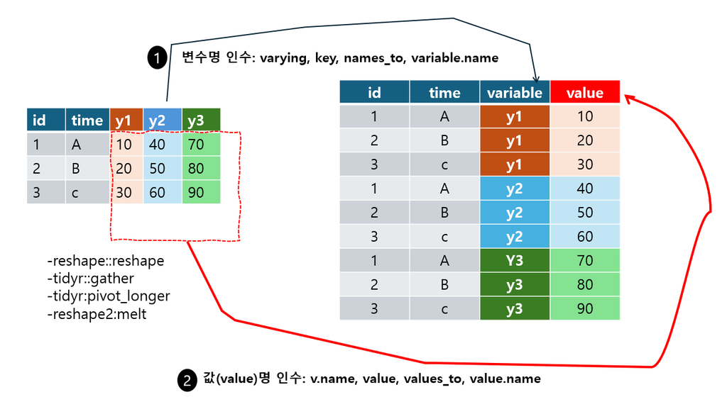

그림 1. 긴데이터(longformat)으로 변경

**긴 데이터로 변경하는 절차**

```
(1) 고정되어야 하는 열이 무엇인지 결정한다. 이 열은 위치가 고정된다.
    그림 1.에서는 id, time변수가 고정되어야 하는 값이다.
(2) 길게 변형되어야 하는 변수(열)이 무엇인지 결정한다.
    그림1에서는 y1 ~ y3까지를 모두 이동시킬 예정이다.
(3) 옮겨지는 부분의 열이름이 값들로 변화되므로 새롭게 만들어질 열이름을 설정한다.
(4) 해당하는 값들이 들어가서 새롭 게 만들어지는 열의 이름을 결정한다.
```

긴데이터로 변경하는 경우 어떠한 함수를 사용하더라도 이러한 부분의 원칙은 유지된다. 고정되어야 하는 열과 이동되어야 하는 열을 결정하고, 이동되어야 하는 열은 열이름(colnames)가 값으로 들어가는 변수명을 정하고, 해당하는 값들이 들어가는 변수명을 정하면 된다.

**넓은데이터(wide format)으로 변경**

이제 넓은 데이터로 만드는 방법을 알아보자. 긴데이터를 만드는 방법이 이해되었다면 이제는 과정에 대한 것을 거꾸로 하는 것이므로 개념적인 것들은 이해하고 바라보면 이 방법도 간단하게 설명이 된다. 또한 이해해야 할 부분은 넓은 데이터로 변경할 때에는 넓은 데이터로 만드는 방법도 있고, 이러한 과정에서 집계함수의 기능을 수행하기도 한다. 와이드 데이터로 변경하는 함수들은 대부분 집계함수의 기능을 수행하는 경우가 많다. 그래서, 처음에 와이드 데이터로 만드는 함수가 복잡하게 느껴진다. 지금은 와이드한 데이터로 만드는 것이므로 복잡하게 생각하지 말고, 와이드 데이터로 만드는 과정을 이해하는 것이 중요하다.

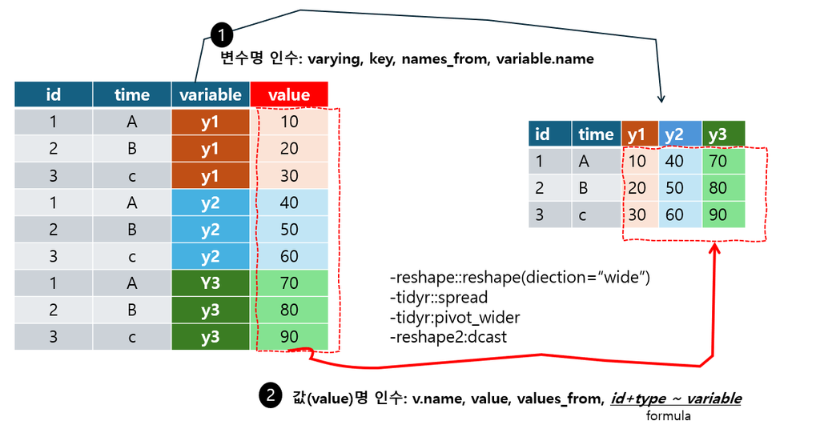

그림 2. 넓은데이터(wide format)으로 변경

데이터를 와이드하게 바꾸는 목적은 크게 2가지인데, 첫번째로 통계패키지에 맞게 사용하기 위함이다. SPSS나 JAMOVI, JASP, EXCEL 등은 모두 기본적으로 와이드한 데이터를 사용한다. 이렇게 변경하면 변수를 명확하여 사용하기가 편리해진다. 두번째로 집계 데이터를 생성하기 위함이다. 그룹별 기술통계나 기타 여러가지 집계하여 정리하기 위한 목적으로 사용된다.

독자들이 긴데이터와 넓은 데이터를 변경하는 방법이 헷갈리다고 말하는 경우가 많다. 대부분 연구자들이 학위논문이나 학술논문을 사용할 때, 설문지를 받는다면 대체로 와이드한 데이터이다. 따라서, 긴데이터로 변경하는 부분에 집중하여 알아보면 데이터를 사용하는 것이 편리해질 수 있다.

#### 2.2.2.1. stats::reshape 함수

데이터는 다음과 같이 생성했다. 독자도 같은 값을 얻으려면, set.seed(20240226)을 적용하여 부트스트랩의 시드(seed)값을 동일하게 해주면 된다.

```r
set.seed(20240226)
df <- data.frame(id = 1:12,
                 type = rep(c("mid","fin"), 6, each=TRUE),
                 y1 = sample(1:7, 12, replace=TRUE),
                 y2 = sample(1:7, 12, replace=TRUE),
                 y3 = sample(1:7, 12, replace=TRUE)
                 )

# df

# 다른 방법
jjstat::df
```

롱데이터로 변경하는 방법은 r-base의 stats패키지의 reshaple()를 이용하는 방법이다. 함수의 기본 설정은 다음과 같다.

```
  reshape(data, varying = NULL, v.names = NULL, timevar = "time",
    idvar = "id", ids = 1:NROW(data),
    times = seq_along(varying[[1]]),
    drop = NULL, direction, new.row.names = NULL,
    sep = ".",
    split = if (sep == "") {
        list(regexp = "[A-Za-z][0-9]", include = TRUE)
    } else {
        list(regexp = sep, include = FALSE, fixed = TRUE)}  )
```

**롱포맷(long format)데이터로 변경**  
reshape에서는 앞으로 소개된 롱포맷 변경함수들과 달리 변수의 앞부부을 없애고, 숫자형태로 변환한다. 예를들면 y1, y2, y3 이라는 변수가 롱포맷으로 변경될 결과를 보면 variable에는 1, 2, 3으로 변경이 되어있다. 이렇게 변경되는 것은 나중에 통계분석 활용시 다층분석(혼합모형분석)등에서 데이터 변환시 편리함을 주는 경우가 많다는 점을 참고하면 좋을듯 하다. 따라서 원래대로 돌릴 경우에는 변수명을 정확히 입력하여 변형해야 한다. 여기에서 중요한 것은 direction = ’long’라고 설정하는 부분인데, 이 옵션이 반드시 설정되어야 긴데이터로 변경이 된다.

```r
df_long1 = reshape(df,
        idvar=c("id", "type"), #유지할 데이터
        varying = list(3:5), # value가 될 변수
        timevar = "variable",  #value가 된 column
        v.name = "score", # value의 명칭
        direction ='long')
df_long1
```

이 롱데이터를 와이드 데이터로 바꾸려면 다음과 같이 같은 함수를 사용한다. 다만 아래와 같은 방법으로 바꾸게 되면, 열(column)의 변수명이 자동으로 롱데이터에 있던 이름을 사용하게 된다.

**와이드포맷(wide format)데이터로 변경**  
앞에서 강조한 것처럼 롱포맷으로 변경된 데이터는 다시 와이드 데이터로 만들때, 컬럼명에 문자가 빠진 숫자만 있었기 때문에 열에 있던 score라는 이름을 이용하여 숫자를 붙이면서 돌아왔다. 따라서, 원래의 데이터명을 유지하려면 이러한 부분을 잘 고민해서 이름을 정하는 것이 좋다.

```r
reshape(df_long1,
        idvar=c("id","type"), #유지될 데이터
        timevar="variable", #column이 되는 변수
        direction ="wide" )
```

위 결과를 보면 처음에 이름을 정확히 하지 않았기 때문에 발생한 문제를 해결하는 방법은 변수명을 정확히 다시 입력해주면 되는데, 이에 대한 방법은 당므과 같다. 먼저 column의 이름을 명확히 하려면, varying이란 인수를 list로 변수명을 정확하게 입력해주면된다. 이렇게 하면 정확한 변수명이 나타나는 것을 확인할 수 있다.

```r
reshape(df_long1, idvar=c("id","type"), #유지될 데이터
        timevar="variable",#column이 되는 변수
        varying=list(c("y1","y2","y3")), #column의 정확한 변수명
        direction ="wide" )
```

만약에 reshape()함수를 이용하여 일반데이터를 롱데이터로 만든 경우에는 rownames영역에 기록된 정보가 있어서 간단하게 원래대로 돌리는 것도 가능하지만, 정확한 함수의 사용법을 익히는 것이 중요하는 점을 강조하고 싶다. 아래와 같이 간단하게 변경이 되기도 하지만, 일반적으로 롱데이터를 와이드한 데이터로 바꾸는 방법을 정확히 익히도록 하자.

```r
reshape(df_long1,
        direction ="wide" )
```

#### 2.2.2.2. tidyverse(tidyr::gather, tidyr::spread)

**gather함수를 이용한 롱데이터**

다음은 tidyverse에 포함되어 있는 tidyr패키지의 gather()와 spread()를 이용한 방법이다. 지금은 다음절에 소개된 pivot_longer()와 pivot_wider()를 더 추천한다고 하지만, 예전에 만들어진 대부분의 코드가 gather와 spread로 만들어거나 분석한 경우가 많아서 익혀야 하는 방법이기도 하다.  
gather 함수의 사용은 다음과 같다.

```
  gather( data,
  key = "key",
  value = "value",
    ...,
  na.rm = FALSE,
  convert = FALSE,
  factor_key = FALSE)
```

먼저 데이터는 앞에서 만들어진 df데이터를 사용하도록 하자. 롱포맷으로 바꾸는 것은 gather()라는 함수를 사용하는데, 이 단어의 의미대로 이해하면 될 것같다. key인수는 롱데이터로 만들면서 모이는 열변수들이 전체 이름을 정하는 것이고, value옵션은 데이터(값)들이 모인 열의 이름을 정하는 것이다. gather함수에서는 dplyr::select()함수가 자동으로 적용이 되어 ,(comma)를 이용하여 모여질 열들을 선택하면 된다. 함수를 사용할 때 ’tidyr::gather’와 같은 ’패키지명::함수’로 사용하는 것은 library(tidyverse)나 library(tidyr)을 임포트 하면 붙일 필요없으나, 본서에서는 각 함수가 어떤 패키지에서 왔는지 명확하게 알려주기 위해서 패키지명을 붙여서 사용하였다.

```r
df_long2 <-tidyr::gather(df,
         key = "variable",
         value= "score", y1, y2, y3)
df_long2
```

지금은 y1, y2, y3이라는 열을 선택했는데, 거꾸로 id, type열을 빼내는 방법도 가능한데, 이때 사용하는 방법은 select()함수에 사용하는 것처럼 -(minus)를 붙이면 된다.

```r
tidyr::gather(df,
         key = "variable",
         value= "score", -id, -type)
```

**spread함수를 이용한 와이드데이터**

spread함수의 구조는 다음과 같다.

```
spread(data, key, value,
      fill = NA, convert = FALSE,
      drop = TRUE, sep = NULL)
```

롱포맷 데이터를 와이드한 데이터로 바꾸는 경우에 사용하는 spread함수는 key 인수에는 열의 변수로 돌아갈 이름이 들어있는 변수명을 택하고, value인수는 값으로 돌아갈 값들이 들어있는 변수를 택하면 된다.

```r
tidyr::spread(df_long2,
        key = "variable", #열(column)으로 돌아갈 값들
        value = "score")  #각 열의 값이 되어야 하는 부분
```

#### 2.2.2.3. tidyr::pivot_longer, pivot_wider

tidyvers에서는 gather, spread를 솔리드버전(완전히 고정되어 없애지 않는 버전)으로 택하고, 좀 더 명확하게 이해되는 이름은 pivot_longer와 pivot_wider를 사용하는 것을 추천하고 있다. 특히 인수는 데이터를 어떻게 변형하는지 더 이해가 쉬운 인수명을 사용하고 있다. 또한 wide데이터로 변형하는 경우 더 다양한 집계함수와 기능을 추가하여 데이터를 분석하는데 유리한 것들을 제공하고 있다. 다만, 이를 자주 사용하는 경우 좀 더 완벽하게 익혀서 데이터 과학,데이터 분석에 효과적으로 사용하는 기능을 공부하는 부담이 좀 있지만 데이터를 분석하기 좋게 변경하는 기능에서는 복잡하지 않고 쉽게 사용이 가능하여 목적에 잘 맞게 사용하면 편리한 함수라고 보여진다.

**롱포맷으로 변경**

pivot_longer의 기본적인 설정은 다음과 같다. 중요하게 설졍해야 하는 부분이 cols, names_to,values_to에 대한 부분이다.

함수의 구조는 다음과 같다.

```
pivot_longer(
  data,
  cols,
  ...,
  cols_vary = "fastest",
  names_to = "name",
  names_prefix = NULL,
  names_sep = NULL,
  names_pattern = NULL,
  names_ptypes = NULL,
  names_transform = NULL,
  names_repair = "check_unique",
  values_to = "value",
  values_drop_na = FALSE,
  values_ptypes = NULL,
  values_transform = NULL
)
```

이제 df데이터를 사용하여 롱포맷으로 변경해보자.

```r
df_long3 = pivot_longer(df,
            cols = y1:y3,
            names_to="variable",
            values_to="score")
df_long3
```

**와이드포맷으로 변경**

pivot_wider는 data인수외에 주요한 인수가 names_from과 values_from인수이다. 즉 롱데이터를 와이드하게 변형할 때 변수가 될 것이 무엇인지와 값이 될 변수가 무엇인지 정하는것이다. 대체로 모든 함수들의 인수는 동일한 특성을 가지고 있으므로 이해하기 어렵기 않다고 생각된다.

함수의 구조는 다음과 같다.

```
pivot_wider(
  data,
  ...,
  id_cols = NULL,
  id_expand = FALSE,
  names_from = name,
  names_prefix = "",
  names_sep = "_",
  names_glue = NULL,
  names_sort = FALSE,
  names_vary = "fastest",
  names_expand = FALSE,
  names_repair = "check_unique",
  values_from = value,
  values_fill = NULL,
  values_fn = NULL,
  unused_fn = NULL
)
```

이제 데이터를 와이드 데이터로 변경해보자.

```r
pivot_wider(df_long3,
            names_from="variable", #열이 될 이름
            values_from="score")  #열변수의 값들
```

#### 2.2.2.4. reshape2::melt, dcast

reshape2패키지는 롱포맷과 와이드포맷을 변경하는 것을 문론 dcast함수는 집계함수로서도 동작한다. 집계함수의 기능은 추후에 소개하기로 하고 지금은 포맷을 변경하는 것에만 사용해보도록 하자.

아래의 데이터는 연습을 위해서 jjstat패키지에서 df데이터를 가져왔다.

```r
# data 생성
# set.seed(20240226)
# df <- data.frame(id = 1:12,
#                  type = rep(c("mid","fin"), 6, each=TRUE),
#                  y1 = sample(1:7, 12, replace=TRUE),
#                  y2 = sample(1:7, 12, replace=TRUE),
#                  y3 = sample(1:7, 12, replace=TRUE)
#                  )

df <- jjstat::df
```

데이터를 롱포맷으로 바꾸는 방법을 위해서는 melt함수를 이해해야 한다. 함수의 구조는 다음과 같다.

```
melt( data, id.vars, measure.vars, variable.name = "variable",
 ...,
 na.rm = FALSE,   value.name = "value", factorsAsStrings = TRUE)
```

기본 값이 variable.name = “variable”, value.name = “value”으로 설정이 되어있으므로 이 이름을 그대로 사용하려고 하면 굳이 바꿀 필요는 없다.

```r
#롱데이터로 변경
df_long <- reshape2::melt(df, id.vars = c("id","type"))
df_long
```

| id | type | variable | value |
| --- | --- | --- | --- |
| 1 | mid | y1 | 1 |
| 2 | fin | y1 | 4 |
| 3 | mid | y1 | 3 |
| 4 | fin | y1 | 1 |
| 5 | mid | y1 | 4 |
| 6 | fin | y1 | 4 |
| 7 | mid | y1 | 7 |
| 8 | fin | y1 | 5 |
| 9 | mid | y1 | 6 |
| 10 | fin | y1 | 6 |

[output cut: 26 more lines]

이제, 변수명을 바꾸어보자. variable.name=“New_name”, value.name=“New_score”으로 하여 name을 변경할 수 있다. 변수명이 어떻게 바뀌는지 확인해보도록 하자.

```r
#새로운 변수명 설정
reshape2::melt(df, id.vars = c("id","type"),
               variable.name="New_name",
               value.name="New_score")  %>%
  head()
```

**와이드포맷으로 변경**

이제 dcast를 통하여 원래의 모습대로 만들어보자. dcast()에는 인수로 롱포맷데이터와 formula를 통해서 변경한다. id, type를 유지한채 variable변수와 value를 다시 넓게 펼치는 데이터로 변경하는 방법으로 하기 위해서는 `id + type ~ variable`라고 입력하는데, 왼쪽은 유지해야 할 변수이고, 오른쪽은 펼쳐야 할 변수이다.

```r
reshape2::dcast(df_long, id + type ~ variable)
```

**집계함수로의 dcast**

```
집계함수로서의 기능: dcast(데이터, formula, function)
```

```r
type_mean = reshape2::dcast(df_long, type ~ 1, mean)
type_mean
```

type에 value에 대한 평균을 구해보자.  
이 값에 대하여 집계함수를 사용해서 값을 찾아서 비교해보자.

```r
# jjstat package
jjstat::mysummaryBy(value ~ type, data = df_long )[,1:2]
```

만약에 varibale ~ type에 대한 것으로 각 그룹에 따른 평균을 구해보자. 결과는 행렬형태로 나타난다.

```r
reshape2::dcast(df_long, variable ~ type, mean)
```

다음은 집계하여 합을 구한 것이다.

```r
reshape2::dcast(df_long, variable ~ type, sum)
```

데이터의 포맷을 바꾸면서 집계함수를 직접적으로 사용하는 경우는 많지 않다. 다만, 연구자가 많이 사용하는 함수를 사용하여 집계를 하면 된다. 데이터의 형태에 따라 aggregate, apply, lapply, sapply, group_by, summarise 등을 사용하기 때문에 각자에 맞는 집계함수를 사용하여 데이터를 구하면 된다.

#### 2.2.2.5. 변수선별하여 round처리

이 부분을 설명하는 것은 실제로 데이터를 처리하면서 자주 만나고, 반드시 해결해야 하는 중요한 처리 방법이다. round처리를 하는 경우 변수의 종류가 factor변수와 numeric변수가 섞여 있어서 이를 데이터에 처리하려면 dplyr::mutate_if()를 사용하여 처리하면 된다. 이는 데이터를 처리할 때 중요한 기술이므로 잘 활용하는게 중요하다.

평균으로 집계하한 후에 muatate_if를 이용하여 numeric변수만을 round처리

```r
reshape2::dcast(df_long, variable ~ type, mean)  %>%
  dplyr::mutate_if(is.numeric, round, 2)
```

평균으로 집계하한 후에 sapply를 이용하여 numeric변수만을 round처리

R-base에서 적용하는 방법은 sapply를 이용하는 방법이다. 단, 이 방법을 적용할 때에는 함수를 적용해야 한다. sapply(data, FUN)로 사용하기 때문에 FUN부분에 반복 적용되는 데이터의 변수에 대하여 numeric변수인지 확인하고 맞으면 ronud처리를 하고, 아니면 넘어가도록 설정하였다.

```r
reshape2::dcast(df_long, variable ~ type, mean)  %>%
 sapply(function(x){if(is.numeric(x)){round(x, 2)}else{x}})  %>%
  data.frame()
```

jjstat::Round()함수는 수치형변수(numeric)에 대한 것들만 수소수점 자리를 조절해주는 함수이다. 아무래도 별다른 설정없이 쉽게 사용되므로 활용도가 높다고 할 수 있다.

```r
reshape2::dcast(df_long, variable ~ type, mean) %>%
  Round(2)
```

| variable | fin | mid |
| --- | --- | --- |
| y1 | 4.00 | 3.67 |
| y2 | 4.67 | 3.83 |
| y3 | 4.33 | 4.50 |

#### 2.2.2.7. jjstat::to_long, long_df 를 이용한 빠른 포맷 변경

이번에는 빠른 속도로 롱포맷으로 변경하는 방법을 알아보자. 지금까지 사용해온 것들의 개념을 이해했을 것이다. 데이터가 주어졌을 때, 행이름을 변수로 만든 후에 변수들이 수치를 나타내는 값이면 이를 판별하여 롱포맷으로 바꾸어주는 함수를 사용해보자. jjstat의 londg_df와 to_long을 사용하는데 두 개는 같은 함수이지만, 동작을 시작하는 방법이 다르다. long_df는 데이터에서 rownames를 먼저 열의 변수로 만든 후에 cols변수(열로 변경시킬 것을 선택)가 선택이 없으면 일단 모든 numeric변수를 names_to로 설정하는 것이 기본값으로 만들어져있다.

다음과 같이 mtcars데이터에서 임의로 추출한 데이터를 확인해보자.

```r
MTcars <- mtcars[1:3,1:3]
#cyl은 실린더의 개수
MTcars$cyl <- factor(MTcars$cyl, levels = c(4, 6), labels = c("cyl-4", "cyl-6"))
MTcars
```

```r
# 3*3 데이터 --> 9개의 행을 가진 데이터로 변경
MTcars %>% long_df()
```

이번에는 인수를 정확히 명명해서 입력해보자.  
가장 먼저 행에서 이름을 가져오기 때문에 rowname를 지정하면 된다. 현재는 ’car’이라고 지정했다. names_to는 colname이라고 지정해서 출력을 했다.

```r
MTcars %>%long_df(rowname = "car", names_to = "colnames")
```

이 데이터를 다시 wide포맷 데이터로 만드는 것은 wide_df()를 이용하거나 to_wide를 이용하면 된다.

```r
MTcars %>%
  long_df(rowname = "car", names_to = "colnames") %>%
   wide_df(names_from = "colnames")
```

long_df()외에도 to_long()을 이용하는 방법이 있다. 이 방법은 rowname를 생성하지 않고 롱포맷으로 만드는 방법이다.

```r
# mtcars[1:3, 1:4] %>% to_long( names_to = "names", values_to = "values")

# default
mtcars[1:3, 1:4] %>% to_long( )
```

to_long으로 롱포맷으로 만들게 되면, 기본적으로 프라임키가되는 열이 생성되지 않기 때문에 고정이 되는 열을 만들어야만 한다.

```r
#새로운 열을 생성
mtcars[1:3, 1:4] %>%
  to_long( )%>%
     add_id()
```

프라임키가 될 id 열을 생성했으니 다시 와이드데이터로 변형해보자. tolong으로 만든 데이터에 id열을 추가하고 난 후에 to_wide함수를 이용하여 다시 와이드포맷으로 바꾸는 방법이다.

```r
# result : "names"  "values"
mtcars[1:3, 1:4] %>%
  to_long( ) %>% colnames()
```

변수는 두가지이다. 이 두가지를 이용하여 와이드포맷으로 변경한다.

```r
#와이드 데이터로 변경
mtcars[1:3, 1:4] %>%
  to_long( )%>%
     add_id() %>%
      to_wide()
```

변형하는 방법은 add_id()를 사용하지 않아도 와이드 데이터를 생성할 수 있다. to_wide의 옵션에는 add_id 옵션이 있어서 기본적으로 새로운 id열을 추가할 수 있다.

```r
 mtcars[1:3, 1:4] %>%
  to_long( )%>%
      to_wide(add_id = TRUE)
```

### 2.2.3. 데이터분리와 합치기

#### 2.2.3.1. separate를 이용한 데이터분리

데이터를 분리하는방법은 tidyr의 separate()사용할 수 있다. 데이터를 인수로 받아서 sep=“/”와 같이 구분자를 넣는다. 디폴트는 “/”으로 되어 있다. into=()를 이용하여 분리되는 변수명을 설정해주면 데이터가 분리된다.

```
separate( data,  col, into,
 sep = "[^[:alnum:]]+",
 remove = TRUE,
 convert = FALSE,
 extra = "warn",
 fill = "warn",
 ...
 )
```

데이터를 분리하는 연습을 위해서 jjstat패키지의 worldcup 데이터를 사용해보자. 이는 월드컵 개최국과 개회연도, 그리고 임의로 만들어진 골개수 데이터이다.  
데이터를 살표보자.

```r
jjstat::worldcup
```

이제 이데이터의 goal데이터를 분리해보자. 구분은 ’/’을 이용하여 분리해보자.

```r
# worldcup data
worldcup_sep <- jjstat::worldcup  %>%
  tidyr::separate(goal, into = c("vip_goal", "total_goal"), sep ="/")

worldcup_sep
```

vip_goal, total_goal 변수를 보면 데이터가 numeric데이터임인데 분리해보니 character데이터로 나타닜다. 즉 텍스트 데이터를 분리했기 때문에 분리된 것도 형식이 같은 것이기 때문이다.  
이때, convert = TRUE를 설정하면 데이터를 더 적합한 모습으로 변경해준다. 아래의 결과를 보면 변경된 데이터 int로 변경된 것을 알 수 있다.

```r
jjstat::worldcup  %>%
  tidyr::separate(goal, into = c("vip_goal", "total_goal"),
                  convert = TRUE)
```

sep = 2 로하면 선택한 변수에 대하여 앞에서 부터(왼쪽부터) 두자리를 중심으로 분리한다. 변수중에서 year을 century와 year로 분리하였다. sep가 음수이면 오른쪽부터 분리된다.

```r
jjstat::worldcup  %>%
  tidyr::separate(year, into = c("century", "year"), sep = 2, convert = TRUE)
```

여기에서 분리한 후에 원래이 데이터를 남기는 방법도 있다. remove = FALSE로 하면 분리한 데이터도 생성되지만 원본이었던 열도 남아있게 된다.

```r
jjstat::worldcup  %>%
  tidyr::separate(goal, into = c("vip_goal", "total_goal"), sep ="/", remove = FALSE)
```

그런데, 다음과 같이 분리해야 할 데이터가 갯수가 맞지 않은 경우도 있다. 이런 경우에는 분리하면 오류가 발생한다. 같은 개수를 분리하지만, 오류 메시지가 나타난다.

```r
tibble(x = c("a,b,c", "d,e,f,g", "h,i,j"))
```

g라는 문자는 사라지고 분리되었다.

```r
tibble(x = c("a,b,c", "d,e,f,g", "h,i,j")) %>%
  separate(x, into = c("one", "two", "three"))
```

extra = ‘merge’ 옵션을 이용하면, 남는 데이터를 없애 버리는 것이 아니라 분리될때 남아있는 것들은 하나의 데이터로 합치게 된다.

```r
# extra = "merge"추가 요소는 이전 요소와 함께 전체적으로 처리됩니다.
tibble(x = c("a, b, c", "d, e, f, g", "h, i, j")) %>%
  separate(x, c("one", "two", "three"), extra = "merge")
```

#### 2.2.3.2. extract를 이용한 분리 방법

separate를 이용한 분리는 명확한 sep=“” 옵션이라는 구분자를 통해서 분리한다.  
그렇다면 그러한 구분자가 없다면 어떻게 구분할 수 있을지 알아보자.  
다음 데이터를 보면 영어와 숫자가 결합된 문자가 있다. 알파벳의 개수와 숫자의 개수도 일치하지 않는다.

```r
tibble(x = c("a1", "best2", "c333", "dis23"))
```

다음과 같이 분리를 하는데 regex옵션에 정규식을 이용하는 방법이 있다. ([a-z]+)는 소문자로 시작되는 글자이며 +는 이상의 개수를 말한다. ([0-9]+)는 숫자로 만들어진 것들을 말한다.

```r
tibble(x = c("a1", "best2", "c333", "dis23")) %>%
  extract(x, c("variable", "id"), regex = "([a-z]+)([0-9]+)")
```

regex를 통해서 나눌때 형식을 맞추어서 분리할 수 있다.

```r
tibble(x = c("a_1", "best_2", "c_333", "dis_23")) %>%
  extract(x, c("variable", "id"), regex = "([a-z]+)_([0-9]+)")
```

#### 2.2.3.3. unite를 이용한 데이터 결합

```r
worldcup_sep  %>%
  unite(goal,vip_goal, total_goal, sep = "_" )
```

데이터를 합칠 때 역시 rmove옵션을 사용할 수 있다. remove가 FALSE가되면 원래의 데이터는 없어지지 않고 나타나게 된다.

```r
worldcup_sep  %>%
  unite(goal,vip_goal, total_goal, sep = "_" , remove=FALSE)
```

#### 2.2.3.4. jjstat::combind_data를 이용한 데이터 결합

이번에는 행렬형태로 된 데이터를 결합하거나 해제하는 방법에 대하여 알아보려고 한다. 먼저 2개의 데이터를 생성해보자. M1 행렬과 M2행렬을 만들었고, 이 두개의 행렬을 하나로 결합하려고 한다.

```r
M1 = matrix(c(1:12), ncol=4,
        dimnames = list(c(paste0("R",1:3)),
                        c(paste0("C",1:4))))
M1
```

```
   C1 C2 C3 C4
R1  1  4  7 10
R2  2  5  8 11
R3  3  6  9 12
```

```r
M2 = matrix(c("","*","**","",
              "***","","","*",
              "***","","*","*"
              ), ncol=4,
        dimnames = list(c(paste0("R",1:3)),
                        c(paste0("C",1:4)))
              )
M2
```

```
   C1   C2    C3    C4
R1 ""   ""    ""    ""
R2 "*"  "***" "*"   "*"
R3 "**" ""    "***" "*"
```

두개의 데이터를 하나로 합치는 것이다. 행렬과 별표시를 하나로 만들어서 하나의 데이터로 만드는 것이다.

|  | C1 | C2 | C3 | C4 |
| --- | --- | --- | --- | --- |
| R1 | 1 | 4 | 7 | 10 |
| R2 | 2 * | 5 *** | 8 * | 11 * |
| R3 | 3 ** | 6 | 9 *** | 12 * |

결합을 할 때 combine_data의 옵션에는 left, right가 있다. 데이터를 합칠때, `5(***)`의 모양으로 만들고 싶을 수 도 있기 때문이다. 결합시키는 과정에서 다양하게 적용이 가능하다.

|  | C1 | C2 | C3 | C4 |
| --- | --- | --- | --- | --- |
| R1 | 1() | 4() | 7() | 10() |
| R2 | 2(*) | 5(***) | 8(*) | 11(*) |
| R3 | 3(**) | 6() | 9(***) | 12(*) |

이번에는 실제 데이터를 이용하여 적용해보자.  
iris데이터를 이용하여 Sepal.Length, Sepal.Width, Petal.Length, Petal.Width의 상관계수를 psych::corr.test를 이용하여 구하였다. 값을 저장하면 `$r`과 `$p`로 구성이된다. 먼저 상관계수를 구하여 상관계수를 나타낸 것이다.

```r
iris_cor = iris %>% select(-Species) %>%psych::corr.test()
iris_cor$r
```

```
             Sepal.Length Sepal.Width Petal.Length Petal.Width
Sepal.Length    1.0000000  -0.1175698    0.8717538   0.8179411
Sepal.Width    -0.1175698   1.0000000   -0.4284401  -0.3661259
Petal.Length    0.8717538  -0.4284401    1.0000000   0.9628654
Petal.Width     0.8179411  -0.3661259    0.9628654   1.0000000
```

이게 p값부분을 보자.

```r
iris_cor$p
```

```
             Sepal.Length  Sepal.Width Petal.Length  Petal.Width
Sepal.Length 0.000000e+00 1.518983e-01 5.193337e-47 9.301992e-37
Sepal.Width  1.518983e-01 0.000000e+00 1.353994e-07 8.146457e-06
Petal.Length 1.038667e-47 4.513314e-08 0.000000e+00 2.805002e-85
Petal.Width  2.325498e-37 4.073229e-06 4.675004e-86 0.000000e+00
```

이 2가지 데이터를 결합해보자. 상관계와 p값을 결합하여 상관계수(p값)의 형태로 나타낸 것이다. p값을 보면서 상관계수의 유의성을 확인할 수 있다.

```r
combine_data(iris_cor$r%>%round(2),
             iris_cor$p%>%round(5),
             left="(", right=")")
```

|  | Sepal.Length | Sepal.Width | Petal.Length | Petal.Width |
| --- | --- | --- | --- | --- |
| Sepal.Length | 1(0) | -0.12(0.1519) | 0.87(0) | 0.82(0) |
| Sepal.Width | -0.12(0.1519) | 1(0) | -0.43(0) | -0.37(0.00001) |
| Petal.Length | 0.87(0) | -0.43(0) | 1(0) | 0.96(0) |
| Petal.Width | 0.82(0) | -0.37(0) | 0.96(0) | 1(0) |

그런데, 아마도 p값의 통계적 유의성을 검증하여 “*”표시를 이용하면 더 빠르게 와닿을 것이다. p< .001이면 `***`이고, p< 0.01 이면 `**`, p < .05으로 ”*” 으로 나타내면 된다.  
이때 사용하는 함수는 `add_significance_symbols()`를 사용한다.  
결합할 때, p값을 가지고 유의성 표시로 바꾸어주는 함수이다.  
한번 적용해보자.

```r
sig = add_significance_symbols(iris_cor$p)
sig
```

```
             Sepal.Length Sepal.Width Petal.Length Petal.Width
Sepal.Length "***"        ""          "***"        "***"
Sepal.Width  ""           "***"       "***"        "***"
Petal.Length "***"        "***"       "***"        "***"
Petal.Width  "***"        "***"       "***"        "***"
```

이번에는 상관계수와 유의성 표시를 결합해보자.

```r
iris_cor_combine =combine_data( round(iris_cor$r, 3) , sig)
iris_cor_combine
```

|  | Sepal.Length | Sepal.Width | Petal.Length | Petal.Width |
| --- | --- | --- | --- | --- |
| Sepal.Length | 1 *** | -0.118 | 0.872 *** | 0.818 *** |
| Sepal.Width | -0.118 | 1 *** | -0.428 *** | -0.366 *** |
| Petal.Length | 0.872 *** | -0.428 *** | 1 *** | 0.963 *** |
| Petal.Width | 0.818 *** | -0.366 *** | 0.963 *** | 1 *** |

데이터는 결합했지만 보기좋게 만드는 것도 필요할 것으로 보인다.  
`round()`함수를 이용하여 소수점 3자리로 바꾸었다. 상관분석표를 정리하기 위해서 `jjstat::lowerMat()`를 이용하여 보기좋게 정리하였다.

|  | Sepal.Length | Sepal.Width | Petal.Length | Petal.Width |
| --- | --- | --- | --- | --- |
| Sepal.Length | 1 |  |  |  |
| Sepal.Width | -0.118 | 1 |  |  |
| Petal.Length | 0.872 *** | -0.428 *** | 1 |  |
| Petal.Width | 0.818 *** | -0.366 *** | 0.963 *** | 1 |

**결합된 데이터의 분리**

이번에는 데이터를 결합한 것을 다시 분리해보자. 현재 아래와 같이 값과 * 표시가 결합된 상태로 나타난 데이터가 있다.

```r
iris_cor_combine
```

|  | Sepal.Length | Sepal.Width | Petal.Length | Petal.Width |
| --- | --- | --- | --- | --- |
| Sepal.Length | 1 *** | -0.118 | 0.872 *** | 0.818 *** |
| Sepal.Width | -0.118 | 1 *** | -0.428 *** | -0.366 *** |
| Petal.Length | 0.872 *** | -0.428 *** | 1 *** | 0.963 *** |
| Petal.Width | 0.818 *** | -0.366 *** | 0.963 *** | 1 *** |

두가지 데이터를 분리할 때에는 unCombine() 혹은 uncombine_data()를 이용하여 분리할 수 있다. 보통 논문에 들어간 데이터를 이용하여 데이터를 검증할때 상관계수만을 추출할 때 매우 유용하다고 할 수 있다.

```r
iris_cor_combine %>% uncombine_data()
```

```
$m1
             Sepal.Length Sepal.Width Petal.Length Petal.Width
Sepal.Length        1.000      -0.118        0.872       0.818
Sepal.Width        -0.118       1.000       -0.428      -0.366
Petal.Length        0.872      -0.428        1.000       0.963
Petal.Width         0.818      -0.366        0.963       1.000

$m2
             Sepal.Length Sepal.Width Petal.Length Petal.Width
Sepal.Length "***"        ""          "***"        "***"
Sepal.Width  ""           "***"       "***"        "***"
Petal.Length "***"        "***"       "***"        "***"
Petal.Width  "***"        "***"       "***"        "***"
```

같은 함수로 unCombine이 있는데 이 경우는 기본적으로 type=“all”로 설정이 되어있어서 원래의 입력된 데이터와 분리된 데이터도 보여주는 방법으로 나타난다.

```r
iris_cor_combine%>%unCombine()
```

|  | Sepal.Length | Sepal.Width | Petal.Length | Petal.Width |
| --- | --- | --- | --- | --- |
| Sepal.Length | 1 *** | -0.118 | 0.872 *** | 0.818 *** |
| Sepal.Width | -0.118 | 1 *** | -0.428 *** | -0.366 *** |
| Petal.Length | 0.872 *** | -0.428 *** | 1 *** | 0.963 *** |
| Petal.Width | 0.818 *** | -0.366 *** | 0.963 *** | 1 *** |

```
$m1
             Sepal.Length Sepal.Width Petal.Length Petal.Width
Sepal.Length        1.000      -0.118        0.872       0.818
Sepal.Width        -0.118       1.000       -0.428      -0.366
Petal.Length        0.872      -0.428        1.000       0.963
Petal.Width         0.818      -0.366        0.963       1.000

$m2
             Sepal.Length Sepal.Width Petal.Length Petal.Width
Sepal.Length "***"        ""          "***"        "***"
Sepal.Width  ""           "***"       "***"        "***"
Petal.Length "***"        "***"       "***"        "***"
Petal.Width  "***"        "***"       "***"        "***"
```

### 2.2.4. 결측값

데이터는 sleep데이터를 활용해서 분석을 해보려고 한다.

```r
 sleep  %>%  str()
```

```r
sleep  %>% head(10)
```

#### 2.2.4.1. 결측 확인하기

결측값을 확인하는 방법은 VIM::aggr()함수를 이용하여 확인할 수 있다.

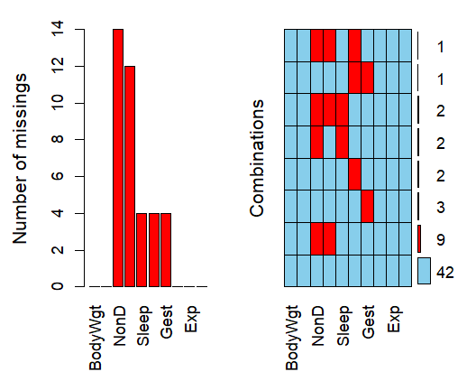

```r
library(VIM)
VIM::aggr(sleep, prop=FALSE, numbers = TRUE)
```

왼쪽 그래프는 각 변수별로 NA의 개수가 얼마나 되는지 보여주며, 오른쪽 그림은 NA의 조합이 어느 변수들의 조합으로 이루어진 것인지 보여주는 그림이다.  
누락된 자료가 없는 행은 42개라고 나타나있다. 붉은 색이 업는 것들이 NA가 없는 것이다.

```r
VIM::marginplot(sleep[c("NonD","Span")], pch = 20,
                col = c("gray60","red","blue"))
```

누락된 자료들 간의 상관관계보기

```r
x = as.data.frame(abs(is.na(sleep)))
# x
y = apply(x, 2, function(x) sum(x) > 0)
# y
round( cor(x[y]), 2)
```

**MCAR (Missing Completely At Random), MAR (Missing At Random)**, 그리고 **MNAR (Missing Not At Random)**에 대한 개념을 이해해보자.

#### 2.2.4.2. 결측의 종류

**MCAR (Missing Completely At Random):**

MCAR는 데이터의 누락이 완전히 무작위로 발생하는 경우를 의미한다. 즉, 누락된 값이 해당 관측치의 다른 값이나 다른 변수와 관련이 없는 경우이다. 예를 들어, 설문조사에서 누락된 값이 응답자의 나이와 상관없이 무작위로 발생하는 경우가 MCAR이다. MCAR의 가정은 데이터를 삭제하거나 간단한 대체 방법으로 처리할 수 있다.

**MAR (Missing At Random):** MAR는 누락된 값이 다른 변수와 관련이 있지만 해당 관측치의 값과는 관련이 없는 경우를 의미한다. 즉, 누락된 값이 다른 변수의 값에 의해 결정되는 경우이다. 예를 들어, 연령대별로 누락된 값이 다르게 발생하는 경우가 MAR이다. 따라서, MAR의 경우 고급 대체 방법(예: MICE)을 사용하여 누락된 값을 처리해야 한다.

**MNAR (Missing Not At Random):** MNAR는 누락된 값이 관측치의 값과 관련이 있는 경우를 의미한다. 즉, 누락된 값이 다른 변수의 값에 의해 결정되는 경우이다. 예를 들어, 소득이 높은 사람들이 소득을 더 낮게 보고하는 경우가 MNAR이다. MNAR의 경우 추가적인 데이터 수집이 필요하거나 더 복잡한 대체 방법이 필요하다.

요약하면:

MCAR: 무작위로 누락됨. 간단한 대체 방법 사용 가능.  
MAR: 다른 변수와 관련 있으나 해당 관측치의 값과는 관련 없음. 고급 대체 방법 필요.  
MNAR: 누락된 값이 관측치의 값과 관련 있음. 추가 데이터 수집이 필요.

#### 2.2.4.3. listwise deletion 과 pariwise deletion

데이터에 NA가 있으면 결측으로 인하여 상관분석을 할 수 가 없다. 따라서 결측이 발생한 행을 지우게 된다. 이때 결측이 발생한 데이터를 제거하는 방법은 2가지가 있다. Listwise Deletion과 Pairwise Deletion은 누락된 데이터를 처리하는 방법이다. 각각의 개념과 차이점을 알아보자.

**(1) Listwise Deletion (전체 삭제):** Listwise Deletion은 누락된 값을 가진 전체 관측치를 분석에서 제외하는 방법이다. 즉, 하나 이상의 변수에서 누락된 값이 있는 경우 해당 관측치를 분석에서 제거하게 된다. 이때 분석은 데이터가 완전한 상태인 관측치에 대해서만 수행된다. 이 방법은 MCAR (Missing Completely At Random) 가정하에 사용된다.

**(2) Pairwise Deletion (부분 삭제):** Pairwise Deletion은 누락된 값을 가진 관측치를 일부만 분석에서 제외하는 방법이다. 통계적 절차는 누락된 데이터가 없는 변수를 사용하여 분석을 수행하게 된다. 예를 들어, 한 관측치에서 변수 A의 값이 누락되었더라도 변수 B와 C의 값은 분석에 활용되게 된다. 이 방법은 MAR (Missing At Random) 가정하에 사용되는 방법이다.

Listwise Deletion은 데이터를 완전히 삭제하므로 정보 손실이 크지만, Pairwise Deletion은 누락된 값을 최대한 활용하여 분석을 수행한다. 그러나 Pairwise Deletion은 각 계산된 통계량이 서로 다른 관측치의 부분 집합에 기반하여 계산되므로 주의해야 한다. 예를 들어, 상관 행렬은 Pairwise Deletion으로 계산할 경우 양의 준정부호성을 보장하지 않을 수 있다는 점을 유념해야 한다.

```r
# Listwise Deletion
sleep_all = na.omit(sleep)
cor_all= cor(sleep_all$BodyWgt, sleep_all$NonD)
nrow(sleep)
nrow(sleep_all)
```

결측이 있으면 계산이 되지 않는다.

```r
cor(sleep$BodyWgt, sleep$NonD)
```

결측을 완전 제거한 경우

```r
cor_all= cor(sleep_all$BodyWgt, sleep_all$NonD)
cor_all
```

결측을 부분 제거한 경우

```r
sleep_partial =  na.omit(sleep[c("BodyWgt","NonD")])
nrow(sleep_partial)
```

```r
cor_partial = cor(sleep_partial$BodyWgt, sleep_partial$NonD)
cor_partial
```

cor_all(-0.3936373), cor_partial(-0.3759462)의 값을 비교해보면 금색 확인을 할 수 있다.

```r
#  Pairwise Deletion
cbind.data.frame(
      method =c("raw_data","Listwise Deletion","Pairwise Deletion"),
      N = c(nrow(sleep),nrow(sleep_all) ,nrow(sleep_partial)),
      Cor = c("Failure to calculate.",
              round(cor_all, 3),
              round(cor_partial, 3) )
)
```

#### 2.2.4.4. 다중 대입법(multi imputatin ,MI)

다중대입법은 반복된 시뮬레이션을 통해서 누락된 데이터를 통계적으로 채워넣는 방법이다(문건웅, 2015). 다중대입법은 누락된 되이터를 채운 가상의 데이터를 3~10개의 세트를 만든 후에 몬테카를로 방법에 근거하여 채우게 되는데 이후에는 표준 통계 방법을 적용하여 통계결과 및 신뢰구간을 제공한다.  
가장 많이 활용되는 패키지는 mice패키지이며, 함수도 mice이다.

```r
library(mice)
sleep2 = mice(sleep, nedd=1234)
sleep2
```

실제 데이터의 자료를 누락시킨후에 mice을 이용하여 채운 값을 비교하여 어느정도의 차이가 발생하는지 확인하자.  
이것은 다중 대입법으로 채우는 값들이 어느 정도의 정확도를 가지는지 확인하기 위함이다.

```r
# Missing data 생성
irna = iris[1:5,1:4]
irna
```

결측생성

```r
irna1 <- irna
irna1[5, 1]<-NA  # 5
irna1[2, 2]<-NA  # 3
irna1[4, 3]<-NA  # 1.5
irna1
```

채우기

```r
irna1 %>% missfillinFor( mean)
```

```r
irna2 = mice::mice(irna1, seed = 1234)
irna2
```

```r
myirna  = miceadds::mids2datlist(irna2)
myirna
```

```r
myirna[[1]]
```

```r
# 반복계산 함수
mi_des_rep = function(myimp){
result  = myimp %>%
          summarise_all(
            .funs = c("mean","sd")
          ) %>%
          tidyr::pivot_longer(cols =  names(.))%>%
          tidyr::separate(name, c("vars", "type"), sep = "_") %>%
          tidyr::pivot_wider(names_from = type,
                        values_from = value, ) %>%
  data.frame()

  rownames(result) = result$vars
  result = result %>% dplyr::select(-vars)
  return(result)
}


with(myirna, fun = function(data){mi_des_rep(data)}) %>%
miceadds::withPool_MI() %>%
tibble::rownames_to_column("vars") %>%
Round(3)
```

원래의 데이터와 비교를 위한 자료

```r
bind_cols(
var =  colnames(irna),
mean = irna %>%apply(2, mean),
sd = irna %>%apply(2, sd)) %>% Round(3)
```

#### 2.2.4.5. jjstat package missCheck, missfill

jjstat에서 missCheck와 missfill함수는 아주 간편하게 결측을 확인하고 평균이나 중앙값을 채우는 기능을 제공한다.  
sleep데이터에는 결측이 포함되어 있는 데이터이다. 이 데이터에서 결측이 어느 수준으로 존재하는지 확인하려면 missCheck함수를 이용하여 간편하게 확인할 수 있다.

```r
sleep  %>%  jjstat::missCheck()
```

|  | Variable | . | Count |
| --- | --- | --- | --- |
| NonD | NonD | 48 | 14 |
| Dream | Dream | 50 | 12 |
| Sleep | Sleep | 58 | 4 |
| Span | Span | 58 | 4 |
| Gest | Gest | 58 | 4 |

옵션으로 plot= TRUE를 해보자. 결측이 발생한 부분은 붉은색으로 표시가 나타난다. 왼쪽에는 결측이 발생한 변수를 나타내며 빈도를 표시해준다. 오른쪽그림은 결측의 개수와 결측이 없는 것은 42개가 있다고 알려주고 있다. 그림은 VIM::aggr()에서 출력되는 것과 같은 것이다.

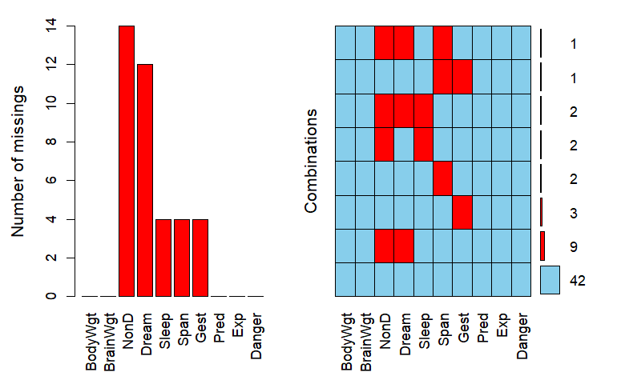

|  | Variable | . | Count |
| --- | --- | --- | --- |
| NonD | NonD | 48 | 14 |
| Dream | Dream | 50 | 12 |
| Sleep | Sleep | 58 | 4 |
| Span | Span | 58 | 4 |
| Gest | Gest | 58 | 4 |

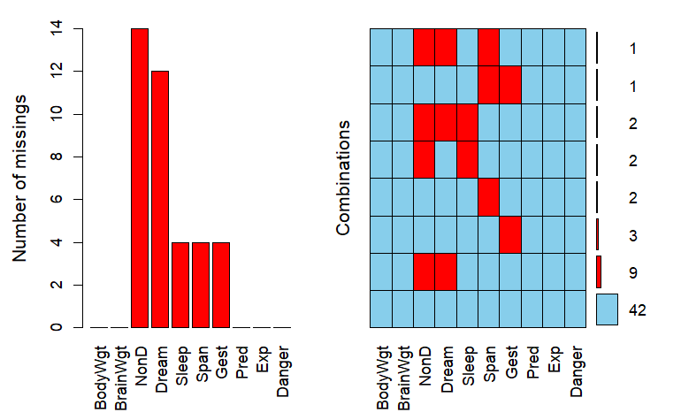

**결측값을 채원허기**  
NA가 잇는 변수의 값을 채워넣기  
다음은 median을 채운 것이다. 채원진 값에는 `*` 표시가 붙는다. 예를 들면, data1에는 8.35*라는 중앙값(median)이 채워진 것이다.

```r
sleep$NonD   %>%  jjstat::missfillin(fn = median)
```

전체의 결측 채우기  
default는 mean으로 되어있다.

```r
sleep  %>%  jjstat::missfillinFor(fn=median )  %>%
  head(10)
```

# 3. 기본 통계분석

기술통계 분석은 데이터를 수집하고 요약하여 데이터의 특징을 파악하는 분석 방법이다. 데이터의 중심 경향, 분포, 변동성 등을 파악하여 데이터를 이해하고 해석하는 데 반드시 필요하다.

기술통계 분석의 목적으로는 (1) 데이터를 요약하고 이해하기 위해서이다. 이는 방대한 데이터를 쉽게 이해하고 분석하기 위해 주요 특징을 요약하는 과정이다. (2)데이터의 분포 파악하기 위해서이다. 데이터가 어떻게 분포되어 있는지 파악하여 데이터의 특징을 이해할 수 있다. (3) 변수 간의 관계 파악을 위해서이다. 변수 간의 상관관계를 파악하여 데이터에 대한 통찰력을 얻을 수 있다. (4) 추론 및 가설 검정을 위해서이다. 데이터를 기반으로 추론하고 가설을 검정하는데 사용한다.

## 3.1. ㅣ기술통계(Descriptive statistics)

기본적인 분석은 가장 먼저 해야할 분석을 말한다.  
대푯값과 산포도를 중심으로 분석하게 된다.  
대표값에는 평균, 중앙값, 최빈값을 분석하게 되는데 평균은 mean(), 중앙값은 median(), 최빈값은 table()을 사용하여 분석한다.

**기술통계 분석의 종류**  
기술통계 분석을 살펴보면 다음과 같이 크게 4가지로 기술통계를 분석한다고 할 수 있다.

가. 중심 경향 측은 다음의 3가지를 주로 측정한다.  
(1)평균: 데이터 값들의 합을 데이터 개수로 나눈 값  
(2) 중앙값: 데이터 값들을 크기 순으로 정렬했을 때 중앙에 위치하는 값  
(3) 최빈값: 데이터 값들 중 가장 자주 나타나는 값

나. 분포 측정  
(1) 표준편차: 데이터 값들이 평균에서 얼마나 떨어져 있는지를 나타내는 값  
(2) 분포형: 데이터 값들이 어떤 형태로 분포되어 있는지를 나타내는 것  
(3) 사분위 범위: 데이터 값들을 4등분했을 때 각 그룹의 범위

다. 변동성 측정  
(1) 분산: 데이터 값들이 평균에서 얼마나 흩어져 있는지를 나타내는 값  
(2) 표준편차: 분산의 제곱근  
(3) 변동계수: 표준편차를 평균으로 나눈 값

라. 상관관계 측정  
(1) 상관계수: 두 변수 간의 선형적인 관계를 나타내는 값  
(2) 결정계수: 한 변수가 다른 변수를 얼마나 설명하는지를 나타내는 값

### 3.1.1. 빈도분석

빈도분석을 가장 먼저 소개하고 이야기를 하는 이유는 대체로 논문을 쓰는 과정에서 가장 먼저 대상자에 대한 것을 소개하거나 측정도구를 사용하여 분석한 내용을 소개하기 때문이다.

먼저 R에 기본으로 탑재된 mtcars 데이터를 이용하여 빈도분석을 해보자.  
데이터의 구조는 다음과 같다.  
이 데이터는 1974년 미국 Motor Trend US 잡지에서 추출된 자료로 32개의 자동차회사의 1973년~1974년 모델에 대한 자동차의 10가지의 디자인 및 성능에 대한 연료 소비량(mpg)를 나타낸 자료이다.

```
A data frame with 32 observations on 11 (numeric) variables.\
  [, 1] mpg Miles/(US) gallon\
  [, 2] cyl Number of cylinders\
  [, 3] disp Displacement (cu.in.)\
  [, 4] hp Gross horsepower\
  [, 5] drat Rear axle ratio\
  [, 6] wt Weight (1000 lbs)\
  [, 7] qsec 1/4 mile time\
  [, 8] vs Engine (0 = V-shaped, 1 = straight)\
  [, 9] am Transmission (0 = automatic, 1 = manual)\
  [,10] gear Number of forward gears\
  [,11] carb Number of carburetors\
```

**데이터구조**  
데이터의 구조를 보는 좋은 방법중 하나가 str()함수를 사용하는 것이다.

```r
library(tidyverse)  # dplyr: %>% (pipe)
data(mtcars)
mtcars %>% str()  # same as str(mtcars)
```

#### 3.1.1.1. table()과 xtabs()

논문의 분석을 시작할 때, 항상 설문이나 실험참가자의 빈도분석을 통해서 제시하게 되어있는데, 이때 사용하는 것이 table함수이다.

table함수의 구조는 다음과 같다.

```
 table(...,
     exclude = if (useNA == "no") c(NA, NaN),
     useNA = c("no", "ifany", "always"),
     dnn = list.names(...),
      deparse.level = 1)
```

useNA: 누락된 값 처리. 사용 가능한 옵션은 “no”(기본값), “ifany” 및 “always”이다.

빈도분석은 보통 table()함수를 활용하는 경우가 많다. 빈도분석은 입력된 데이터들이 도수분포표(frequency table)상에서 어떠한 분포적 특성을 가지고 있는지 파악하는 데 사용된다.

mtcars의 am변수는 Transmission을 나타낸다 (0 = automatic, 1 = manual).  
따라서, 먼저 변수를 factor처리를 먼저해서 빈도를 분석해보자.

```r
# mtcars$am
data(mtcars)
mtcars$am <- factor(mtcars$am,
                    level = c(0, 1),
                    labels = c("automatic", "manual" ))
# frequency analysis
table(mtcars$am)
```

```
automatic    manual
       19        13
```

분석된 결과는 다음과 같이 설명한다.  
빈도분석결과, 자동차의 트랜스미션(transmission)에 대하여 오토매틱은 19개, 수동은 13개로 나타났다.  
이번에는 엔진(engine)에 대한 빈도분석을 해보자.

```r
mtcars$vs <- factor(mtcars$vs, level=c(0, 1),
                    labels = c("V-shaped", "straight" ) )
table(mtcars$vs)
```

```
V-shaped straight
      18       14
```

빈도분석을 이용하여 barplot을 그려볼 수 있다.

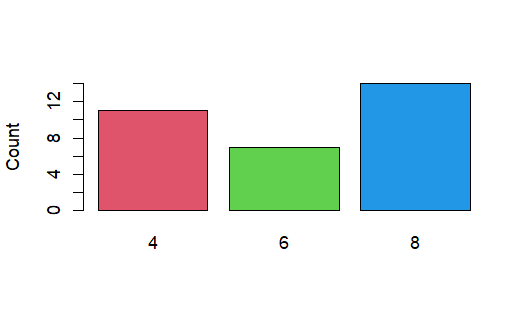

```r
table(mtcars$cyl) %>%
  barplot(ylab="Count", col=2:4)
```

만약 빈도를 분석할 대, 빼고 싶은 값들이 있다면 exclude옵션을 이용하여 제거한다.  
실린더개수6에 해당하는 것을 제외시켜보자.

```r
table(mtcars$cyl, exclude="6")
```

```
 4  8
11 14
```

useNA옵션은 NA데이터가 포함된 경우 사용한다.

```r
# Sample data
data <- c("B", "A", NA, NA, "A", "C", "B")

# Count NA values if any
table(data, useNA = "ifany")
```

```
data
   A    B    C <NA>
   2    2    1    2
```

useNA = “always”를 하면 NA가 없는 경우 0을 표시해준다.

```r
# Sample data
data <- c("B", "A", "A", "C", "B")

# Count NA values even if there are none
table(data, useNA = "always")
```

```
data
   A    B    C <NA>
   2    2    1    0
```

**두가지 이상의 변수를 이용한 빈도분석(Two-way contingency tables)**

트랜스미션(transmission)별 엔진(Enigne)의 빈도분석을 해보자. 사용하는 방법은 두개의 변수를 찾아서 넣어주면 자동으로 분석을 한다.

`table(변수1, 변수2)`

를 넣으면 분석이 된다. 행렬(matrix)의 형태로 빈도를 볼 수 있다.  
분석된 결과를 심미적으로 보기 위해서 먼저 변수를 팩터(factor)처리를 하였다.

```r
#변수의 factor처리
data(mtcars)
#변수의 facror처리
mtcars$am <- factor(mtcars$am, level=c(0, 1),
                    labels = c("automatic", "manual" ) )
mtcars$vs <- factor(mtcars$vs, level=c(0, 1),
                    labels = c("V-shaped","straight" ) )
mtcars$cyl <- factor(mtcars$vs, level=c(4, 6, 8),
                    labels = c("cyl-4", "cyl-6", "cyl-8") )

#am과 vs에 대한 빈도분석
table(mtcars$am, mtcars$vs)
```

```
            V-shaped straight
  automatic       12        7
  manual           6        7
```

table을 사용할 때, 데이터의 변수를 찾아서 일일이 입력하는 방법은 생각보다는 불편하다고 생각이 들 때가 많다. 즉 변수를 미리 선정해서 table()함수를 적욯하면 편리할 수도 있다는 것이다. 그렇게 하려면 dplyr::select함수를 이용해보는 방법이 있다. 먼저 분석할 변수를 미리 선정해두는 방식이다.  
아마도 이 방법이 생각보다 직관적이라고 볼 수 있다.

```r
mtcars %>% select(am, vs ) %>% table()
```

```
           vs
am          V-shaped straight
  automatic       12        7
  manual           6        7
```

with함수를 사용하는 방법도 있다. with()함수내에 넣어두면 attacth되어 동작하는 효과를 볼 수 있다.

```r
with(mtcars, table(am, vs))
```

```
           vs
am          V-shaped straight
  automatic       12        7
  manual           6        7
```

R에서는 이와 같은 것을 데이터프레임에서 쉽게 하도록 xtabs()라는 함수를 두고 있고, 입력방식도 간단하게 제공하고 있다. 포뮬러(formula)형식을 사용하고 데이터를 지정하는 방식이어서 많이 편리한 방식이다. table에서 지정하는 방식과 달리 확장성이 매우 높다는 점이 장점이다.  
특히 `~ 변수 + 변수` 형태의 지정방식으로 변수를 게속해서 결합할 수 있기 때문에 복한 분석이 가능하다.

```r
#am고 vs의 빈도분석
xtabs(~ am + vs, data = mtcars)
```

```
           vs
am          V-shaped straight
  automatic       12        7
  manual           6        7
```

cyl은 실린더 개수 4,6,8개를 나타낸 것이다. 각 그룹별로 분류하여 나타낼 수 있다. `~ 변수1 + 변수2 + 변수3`으로 포뮬러를 정하면 변수3에 맞추어서 분류를 한다.

```r
xtabs(~ am + vs + cyl, data = mtcars )
```

```
, , cyl = cyl-4

           vs
am          V-shaped straight
  automatic        0        0
  manual           0        0

, , cyl = cyl-6

           vs
am          V-shaped straight
  automatic        0        0
  manual           0        0

, , cyl = cyl-8

           vs
am          V-shaped straight
  automatic        0        0
  manual           0        0
```

```r
xtabs(cyl ~ am + vs, data = mtcars)
```

```
           vs
am          V-shaped straight
  automatic        0        0
  manual           0        0
```

이 데이터에서 각각의 비율을 보려면 prop.table()함수를 이용하면 된다.

```r
table(mtcars$am, mtcars$vs) %>%
  prop.table()
```

```
            V-shaped straight
  automatic  0.37500  0.21875
  manual     0.18750  0.21875
```

table을 이용한 빈도분석표에 합을 구해서 넣으려면 addmargins()를 사용해서 나타낼 수 있다.

```r
table(mtcars$am, mtcars$vs) %>%
  addmargins()
```

```
            V-shaped straight Sum
  automatic       12        7  19
  manual           6        7  13
  Sum             18       14  32
```

addmargins의 옵션중에서 margin =1, 2가 있는데 이는 1은 열(column)의 합을 나타내고, 2는 열의 합을 나타낸다. 먼저 열의 합을 나타내보자.

```r
table(mtcars$am, mtcars$vs) %>%
  addmargins(margin = 1)
```

```
            V-shaped straight
  automatic       12        7
  manual           6        7
  Sum             18       14
```

행의 합을 나타내기

```r
table(mtcars$am, mtcars$vs) %>%
  addmargins(margin = 2)
```

```
            V-shaped straight Sum
  automatic       12        7  19
  manual           6        7  13
```

그런데 이러한 방법이 아닌 목록으로 정리하여 보고 싶다면 데이터프레임(data.frame)으로 변경하면 목록형태로 나타나서 논문표에서 넣기 더 편할 수 있다.

```r
data.frame(table(mtcars$am, mtcars$vs))
```

| Var1 | Var2 | Freq |
| --- | --- | --- |
| automatic | V-shaped | 12 |
| manual | V-shaped | 6 |
| automatic | straight | 7 |
| manual | straight | 7 |

이러한 자료를 barplot으로 시각화할 수 있는데, 이때 barplot에서는 beside옵션을 이용하여 두가지 데이터를 비교할 수 있도록 설정해주어야 한다. beside =TRUE로 설정한다.

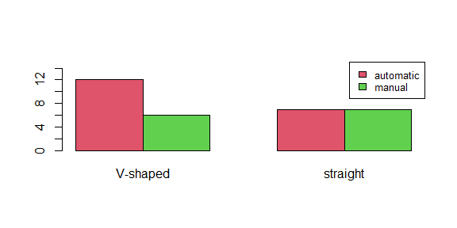

```r
barplot(table(mtcars$am, mtcars$vs), beside = TRUE, col = 2:3,
        ylim=c(0, 15))
#legend
legend("topright", legend = c("automatic", "manual"), fill = 2:3, cex=0.8)
```

만약에 두 데이터를 누적하여 표현하고자 하면 beside=FALSE로 두면 된다. 이것은 디폴트로 설정되어있다.

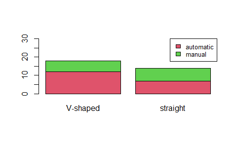

```r
barplot(table(mtcars$am, mtcars$vs), beside = FALSE, col = 2:3, ylim=c(0, 30))
legend("topright", legend = c("automatic", "manual"), fill = 2:3, cex = 0.8)
```

#### 3.1.1.2. count(), n()

R을 사용하는 경우 다양한 라이브러리(library)를 사용할 수 있기 때문에 분석하는 방법이 한가지로 고정되어 있는 것은 아니다. 사용하는 라이브러리를 이용하여 다양한 분석을 할 수 있다. 먼저. dplyr패키지를 이용하여 나타내는 방법도 매우 유용하다. dplyr::count()는 매우 편리한 함수이다. 사용방법은 count(데이터, 변수)로 입력하여 사용한다. 변수가 한개일 경우에는 변수명만 입력하면 된다.

```r
count(mtcars, am)
```

| am | n |
| --- | --- |
| automatic | 19 |
| manual | 13 |

```r
# mtcars %>% count(am)
```

count함수에는 빈도수를 체크하여 그 값을 합해서 계산해주는 기능이 있다.

일단 아래와 같은 데이터가 있다.

```r
# when the data has already been aggregated once
df_sample <- tribble(
  ~name,    ~gender,   ~sum,
  "Max",    "male",       10,
  "Sandra", "female",      1,
  "Susan",  "female",      4)
df_sample
```

| name | gender | sum |
| --- | --- | --- |
| Max | male | 10 |
| Sandra | female | 1 |
| Susan | female | 4 |

gender에서 확인해보면 male과 female로 구성되어있는데 freq에 보니 male은 10, female은 name에 따라 분류되어있다보니 female은 총 5명이지만, names변수에 의해서 구분되어 1, 4로 나누어져 있다. 그런데 빈도를 계산할 때에는 gender변수의 관점에서는 male은 10, female은 5인 것이다. 따라서 이러한 것들을 적용하여 계산해주는 옵션이 `wt=빈도수열`을 사용하는 것이다.

| name | gender | sum |
| --- | --- | --- |
| Max | male | 10 |
| Sandra | female | 1 |
| Susan | female | 4 |

이에 이것을 구현하여 알아보자. 먼저 gender부분을 세어보자. 실제 입력된 것은 male이 1개, female이 2개이므로 빈도는 이것을 나타나게 된다.

```r
# counts rows:
df_sample %>% count(gender)
```

| gender | n |
| --- | --- |
| female | 2 |
| male | 1 |

그러나 실제 빈도를 구하기 위해서는 wt옵션을 이요앟여 freq를 합해야 한다.  
이러한 방식을 통해서 빈도가 분리된 경우에도 빈도분석을 실행할 수 있게 된다.

```r
# counts freq:
df_sample %>% count(gender, wt = sum)
```

| gender | n |
| --- | --- |
| female | 5 |
| male | 10 |

변수가 2개인 경우에는 2개의 변수를 입력해주면, 각각의 나타나는 경우의 수에 맞추어서 분석을 해주다.

```r
count(mtcars, am, vs)
```

| am | vs | n |
| --- | --- | --- |
| automatic | V-shaped | 12 |
| automatic | straight | 7 |
| manual | V-shaped | 6 |
| manual | straight | 7 |

sort=TRUE로 설정하면 n을 기준하여 빈도수가 높은 순대로 정렬해서 보여주게 된다.

```r
count(mtcars, am, vs, sort=TRUE)
```

| am | vs | n |
| --- | --- | --- |
| automatic | V-shaped | 12 |
| automatic | straight | 7 |
| manual | straight | 7 |
| manual | V-shaped | 6 |

좀 불편할 수 있으나, 실제 활용도가 높은 것중 하나가 n()이다. 빈도분석하는 과정에서 수시로 사용회는 함수인데, summarise()와 함께 사용하는 유용한 함수이다.

summarise()와 n()을 이용하여 다음과 같이 나타낼 수 있다.

```r
mtcars %>%
  group_by(am)%>%
  summarise(N=n())
```

| am | N |
| --- | --- |
| automatic | 19 |
| manual | 13 |

#### 3.1.1.3. forcats::fct_count()

이번에는 forcats라는 라이브러리의 fct_count()이다. 필자의 경우도 매우 자주 사용하고 애용하는 라이브러리함수이다. 그 이유는 여러가지로 변형이 가능하기 때문이다. 그러나, fct_count()는 vector형식으로 한가지 변수만 분석이 가능하다. 출력은 tibble데이터로 출력되어 table()와는 다른 형식으로 출력된다. fct_count(데이터)를 입력하면 되고, 옵션으로는 sort를 이용한 정렬기능과 prop라는 비율을 나타내는 옵션이 있다.  
먼저 일반적인 빈도분석이다.

```r
#frequency analysis : default option
library(forcats)
forcats::fct_count(mtcars$am)
```

| f | n |
| --- | --- |
| automatic | 19 |
| manual | 13 |

이번에는 각 빈도에 비율을 포함시켜보자.

```r
# add proportion
forcats::fct_count(mtcars$am, prop=TRUE)
```

| f | n | p |
| --- | --- | --- |
| automatic | 19 | 0.59375 |
| manual | 13 | 0.40625 |

**그래프의 시각화**

ggplot을 이용하여 그래프를 그린 후에 그래프위에 실제적인 값들을 표시하고자 할 때에는 geom_text를 이용하여 나타낸다. geom_text, geom_label(텍스트를 박스에 표시)은 같은 기능을 수행한다.

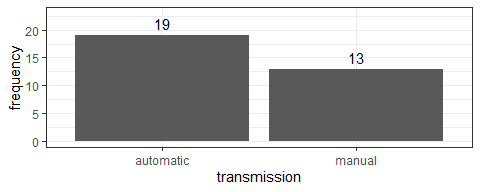

```r
library(forcats)

fct_count(mtcars$am) %>%
  ggplot(aes(x=f, y=n))+
  geom_bar(stat="Identity")+
  geom_text(aes(label=n), vjust=-.5)+
  labs(x="transmission", y="frequency")+
  ylim(0, 23)+theme_bw()
```

#### 3.1.1.4. 빈도의 수가 0인 경우 출력하는 방법

빈도수가 0인 것을 출력해야 하는 경우는 다양한 변수별로 빈도를 분석해서 데이터를 병합할 때 컬럼의 개수가 맞지 않으면 병합하기 어렵기 때문이다. 리커트 척도로 5개의 척도에 대하여 빈도를 분석한 경우, 0이라고 출력하지 않으면 어떤 것은 3개, 4개, 5개로 달라지기 때문에 병합할 수 없게 된다. 따라서, 빈도가 0으로 나와도 출력을 해주어야 하는 경우가 발생한다.

```r
y <- c(0, 0, 0, 3, 4, 4, 4, 4)
z <- c(0, 0, 1, 3, 4, 5, 5, 5)
table(y)
```

0에서 5까지의 변수중에서 개수를 센 상태인데, 2의 경우는 0개이다. 그런데 이 경우 2와 5가 0이라고 나타내고 싶은 경우는 factor로 처리하면서 2를 세도록 해야 한다.

```r
table(factor(y, levels = 0:5))
```

이것은 fct_count()에서도 동일하다. 다만, fct_count함수는 벡터에서만 사용한다.

```r
y <- c(0, 0, 0, 3, 4, 4, 4, 4)
#2가 0개에서 표시가 안된 경우
fct_count(factor(y))
```

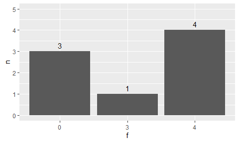

```r
y <- c(0, 0, 0, 3, 4, 4, 4, 4)

fct_count(factor(y))%>%
  ggplot(aes(x = f, y = n))+
  geom_bar(stat = "Identity")+
  geom_text(aes(label = n), vjust = -.5)+
  ylim(0, 5)
```

실제 개수가 없는 데이터를 표시하게 만들려면 factor에서 level을 모두 나타나게 해야 한다. 따라서 level = 0:5까지 모두 설정하면 빈도의 개수가 없는 값이 없는 것들이 개수도 나타난다.

```r
# 개수가 없는 것은 0개로 표시한 경우
fct_count(factor(y, level=0:5))
```

이것을 다시 시각화해보자. 시각화를 하면 존재하지 않는 level에는 0개로 개수가 나타난다.  
즉, 0은 3개, 3은 1개, 4는 4개가 있으나 1, 2, 5는 0개로 존재하지 않는다. 이것을 그래프로 시각화 한 것이다.  
실제로 논문에 들어가는 분석에는 0개인 것들을 표시해야 하는 경우가 많다.

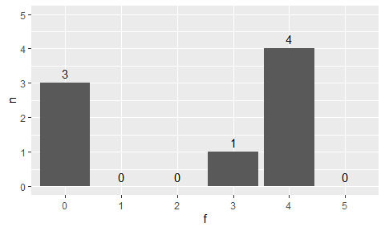

```r
fct_count(factor(y, level = 0:5)) %>%
  ggplot(aes(x = f, y = n))+
  geom_bar(stat = "Identity")+
  geom_text(aes(label = n), vjust = -.5)+
  ylim(0, 5)
```

#### 3.1.1.5. Freq_table를 이용한 주요변수별 빈도분석 방법

jjstat패키지의 `Freq_table()`을 이용하여 나타내보자. jjstat에서는 `Freq_table`과 `table_freq`함수를 이용하여 빈도를 분석하는데, Freq_table은 주로 데이터를 중심으로 나타내는 것으로 필요한 것을 옵션으로 선택하여 나타내면 된다. 반면에 table_freq는 전체적인 것이 먼저 나타나서 불필요한 것을 제외하는 형태로 사용한다. 현재는 Freq_table을 이용하여 빈도를 분석하고, 그래프를 보여주는 방법을 익히고자 한다.

그동안 분석해온 기본적인 y 데이터를 보자

```r
# data.frame(y)
y <- c(0, 0, 0, 3, 4, 4, 4, 4)
#빈도분석
Freq_table(y)
```

| term | Freq |
| --- | --- |
| 0 | 3 |
| 3 | 1 |
| 4 | 4 |

옵션중에 prop=TRUE로 두면 비율을 구해서 나타내준다.

```r
Freq_table(y, prop = TRUE)
```

| term | Freq | prop(%) |
| --- | --- | --- |
| 0 | 3 | 37.5 |
| 3 | 1 | 12.5 |
| 4 | 4 | 50.0 |

```r
factor(y, levels = 1:5)
```

```
[1] <NA> <NA> <NA> 3    4    4    4    4
Levels: 1 2 3 4 5
```

이제 levels를 표시한 데이터를 이용하여 다시한번 Freq_table을 이용하여 나타내보자.

```r
jjstat::Freq_table(factor(y, levels = 0:5))
```

| term | Freq |
| --- | --- |
| 0 | 3 |
| 1 | 0 |
| 2 | 0 |
| 3 | 1 |
| 4 | 4 |
| 5 | 0 |

```r
NA
```

전체이 데이터가 설정되어 분석해도 비율은 바뀌지 않는다는 점을 알 수 있는데, 가능한 모든 데이터가 나타나야 하는 경우는 이러한 방법을 사용한게 좋다. 이제 prop를 이용하여 비율도 나타내보자.

```r
jjstat::Freq_table(factor(y, levels = 0:5), prop = TRUE)
```

| term | Freq | prop(%) |
| --- | --- | --- |
| 0 | 3 | 37.5 |
| 1 | 0 | 0.0 |
| 2 | 0 | 0.0 |
| 3 | 1 | 12.5 |
| 4 | 4 | 50.0 |
| 5 | 0 | 0.0 |

Freq_table에서도 미리 계산된 데이터에서 빈도를 맞추어서 weight를 적용하여 빈도를 추정하는 것이 가능하다.

```r
# when the data has already been aggregated once
df_sample <- tribble(
  ~name,    ~gender,   ~sum,
  "Max",    "male",       10,
  "Sandra", "female",      1,
  "Susan",  "female",      4)
df_sample
```

| name | gender | sum |
| --- | --- | --- |
| Max | male | 10 |
| Sandra | female | 1 |
| Susan | female | 4 |

기본적으로 jjstat에서는 빈도수를 데이터로 만드는 기능들이 있다. add_rows_freq, unCount함수이다. 데이터에 unCount()함수를 적용하여 데이만큼을 생성하고 빈도를 세는 방법이 가능하다.

```r
df_sample %>% unCount() %>% Freq_table("gender")
```

| gender | Freq |
| --- | --- |
| female | 5 |
| male | 10 |

`Freq_table`함수에서는 `count()`함수처럼 wt를 적용하는 기능도 있다. wt에는 빈도를 합칠 열을 선택하면 된다. Freq_table함수에서는 unCount(빈도수 만큼 열을 생성해주는 함수)의 기능을 내장하고 있기 때문에 언제든 활용이 가능하다는 장점이 있다.

```r
df_sample  %>% Freq_table("gender", wt="sum")
```

[output not shown]

**그래프를 함께 출력하기**

옵션중에 plot=TRUE로 하면 빈도그래프를 그려준다. 데이터를 출력하면서 그래프도 함께 보여주는 옵션이라고 할 수 있다.

| term | Freq |
| --- | --- |
| 0 | 3 |
| 3 | 1 |
| 4 | 4 |

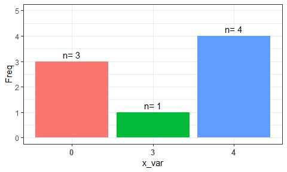

**그래프만 별도로 출력하기**  
만약에 그래프만 보고 싶은 생각이라면 plot=FALSE로 하고 별도의 그래프만 출력할 수 있다. 따라서, 사용할 때 그래프와 데이터가 함께 필요한 것인지 아니면, 별도로 필요한 것인지에 따라서 설정할 수 있다.

```r
Freq_table(y, plot=FALSE, type="g")
```

[output not shown]

현재는 적은 샘플로 그래프를 그리는 상태이지만, 데이터가 많은 경우에는 그래프를 크기순으로 나열해야 하는 경우도 종종생긴다. 그에 맞추어서 reorder 옵션이 있다. reorder=TRUE는 빈도의 크기순으로 나열해주는 기능이다. 이를 통해서 큰순서대로 나열 할 수 있다. 여기에 porp=TRUE로 하면 빈도수에 비율을 포함하여 나타내준다.

| term | Freq | prop(%) |
| --- | --- | --- |
| 0 | 3 | 37.5 |
| 3 | 1 | 12.5 |
| 4 | 4 | 50.0 |

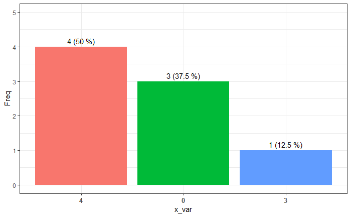

데이터를 분석한 모든 결과를 보고 싶을때에는 당므과 같이 `type ="all"`로 나타내면 된다.

| term | Freq |
| --- | --- |
| a | 3 |
| b | 2 |
| c | 4 |

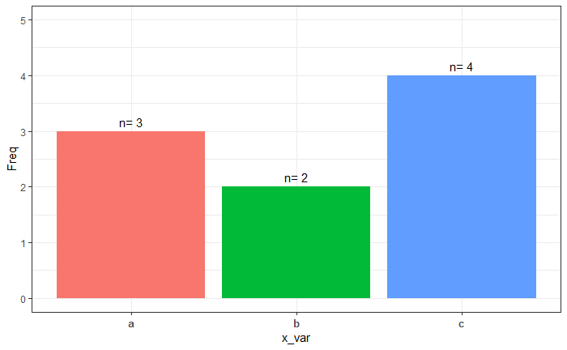

```r
jjstat::Freq_table(c("a","b","c","a","b","a","c","c","c"), type="all")
```

이번에는 실제 mtcars데이터를 이용하여 데이터프레임으로 구성된 것들을 가볍게 살펴보자.

데이터의 변수를 결과를 더 심미적으로 나타내기 위해서 factor로 처리했다.  
먼저 am변수에 대해서 알아보자.

```r
data(mtcars)
Mtcars = mtcars
Mtcars$am = factor(Mtcars$am, levels=c(0,1), labels= c("automatic","manual" ))
Mtcars$vs  = factor(Mtcars$vs, levels=c(0,1), labels= c("V-shaped","straight" ))
Mtcars$cyl  = factor(Mtcars$cyl, levels=c(4,6,8), labels= c("cyl-4","cyl-6","cyl-8"))


Mtcars %>% Freq_table("am")
```

| am | Freq |
| --- | --- |
| automatic | 19 |
| manual | 13 |

변수를 두가지로 결합한 경우도 분석할 수 있다. 예를 들어서 am과 vs의 그룹별 경우의 수에 맞추어서 분석하려고 할 때 두가지 변수를 모두 입력하면 적절히 경우를 나누어서 분석해준다.

```r
Mtcars %>% Freq_table("am","vs", prop=TRUE)
```

| am | vs | Freq | prop(%) |
| --- | --- | --- | --- |
| automatic | V-shaped | 12 | 37.500 |
| manual | V-shaped | 6 | 18.750 |
| automatic | straight | 7 | 21.875 |
| manual | straight | 7 | 21.875 |

3개의 변수를 분석한 경우는 다음과 같다. am, vs, cyl의 조합을 나타내어 분석한 것이다. 사실상 변수가 그룹별로 많아지는 것은 문제가 없으나, 연구하면서 연구목적에 맞는 빈도를 분석하는 것이 매우 중요하다고 할 수 있다.

```r
Mtcars %>% Freq_table("am","vs", "cyl", prop = TRUE)
```

| am | vs | cyl | Freq | prop(%) |
| --- | --- | --- | --- | --- |
| automatic | V-shaped | cyl-4 | 0 | 0.000 |
| manual | V-shaped | cyl-4 | 1 | 3.125 |
| automatic | straight | cyl-4 | 3 | 9.375 |
| manual | straight | cyl-4 | 7 | 21.875 |
| automatic | V-shaped | cyl-6 | 0 | 0.000 |
| manual | V-shaped | cyl-6 | 3 | 9.375 |
| automatic | straight | cyl-6 | 4 | 12.500 |
| manual | straight | cyl-6 | 0 | 0.000 |
| automatic | V-shaped | cyl-8 | 12 | 37.500 |
| manual | V-shaped | cyl-8 | 2 | 6.250 |

[output cut: 2 more lines]

시각화하는 것도 역시 동일한 방법으로 수행한다. 여기에서는 데이터가 아니라 그래프만 보도록 하자.

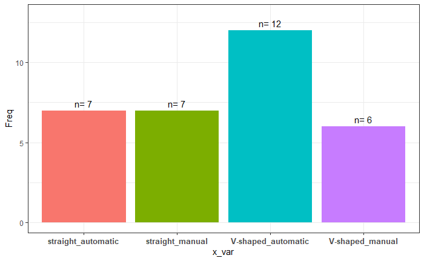

```r
Mtcars %>% Freq_table("vs","am", type="g")
```

좀더 복잡했던 am, vs, cyl변수를 투입한 그래프를 확인해보자. 여기에서 `abgle = 90`은 x축에 변수명이 길어져서 90도로 돌려서보이게 한 것이다.

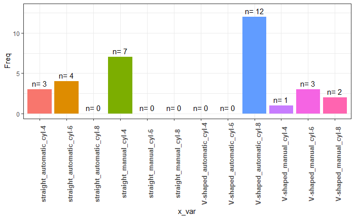

```r
Mtcars %>% Freq_table("vs","am","cyl", angle=90, type="g")
```

일단 빈도가 0인 것도 있어서 그래프가 정리되는 것이 필요하다. 이대 `reorder=TRUE`옵션을 사용하면 된다.

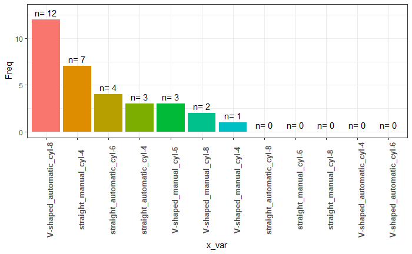

```r
Mtcars %>% Freq_table("vs","am","cyl", angle=90, type= "g", reorder = TRUE)
```

이 그래프는 ggplot을 이용하여 그려지게 되기 때문에 ggplot의 추가적인 옵션을 `+`표시를 이용하여 사용할 수 있다는 장점이 있다.예를 들면 ylim(0, 14) 등을 붙이면 더 넓은 범위로 그래프가 바뀌면서 심미성이 좋아질 수 있다. 추가로 lab()를 이용한 타이틀 및 이름을 변경할 수 있다.

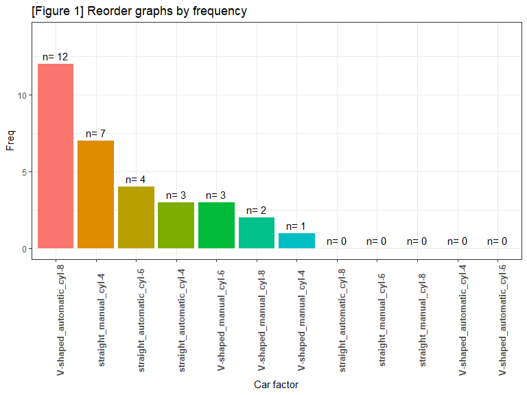

```r
Mtcars %>% Freq_table("vs","am","cyl", angle=90, type= "g", reorder = TRUE)+
  ylim(0, 14)+
  labs(title="[Figure 1] Reorder graphs by frequency",x="Car factor")
```

#### 3.1.1.6. jjstat를 이용한 다변량 빈도분석 방법(table_df)

현재 데이터를 처리하여 변경한 Mtcars데이터에는 3개의 factor변수가 있다. 이 3가지의 변수를 한번에 빈도를 분석하고자 할 때에는 `jjstat::table_df()`함수를 사용하면 된다. 데이터를 보자. 여기에서 사용한 `purrr::keep()`는 변수의 타입을 찾아서 뽑아주는 함수이다.

```r
#데이터를 전처리한 것
Mtcars = mtcars
Mtcars$am = factor(Mtcars$am, levels=c(0,1), labels= c("automatic","manual" ))
Mtcars$vs  = factor(Mtcars$vs, levels=c(0,1), labels= c("V-shaped","straight" ))
Mtcars$cyl  = factor(Mtcars$cyl, levels=c(4,6,8), labels= c("cyl-4","cyl-6","cyl-8"))

Mtcars %>% keep(is.factor) %>%str()
```

```
'data.frame':   32 obs. of  3 variables:
 $ cyl: Factor w/ 3 levels "cyl-4","cyl-6",..: 2 2 1 2 3 2 3 1 1 2 ...
 $ vs : Factor w/ 2 levels "V-shaped","straight": 1 1 2 2 1 2 1 2 2 2 ...
 $ am : Factor w/ 2 levels "automatic","manual": 2 2 2 1 1 1 1 1 1 1 ...
```

**table_df()**

`table_df()`함수는 데이터에 대하여 변수의 타입을 먼저 조사하여 character, factor변수를 확인한 후에 그 변수들에 대한 빈도를 분석하여 전체를 모아서 테이블로 만들어주는 함수이다.  
보통 논문에 연구대상을 구하여 넣을 때, 이함수를 사용하면 불편함 없이 한번에 빈도분석표를 얻을수 있다. 사실 사용해보면 매우 편리하다는 것을 알 수 있다.

```r
Mtcars %>% table_df()
```

```
 Data frequency analysis results
```

| Term | Level | Freq | Prop(%) |
| --- | --- | --- | --- |
| cyl | cyl-4 | 11 | 34.38 |
| cyl | cyl-6 | 7 | 21.88 |
| cyl | cyl-8 | 14 | 43.75 |
| vs | V-shaped | 18 | 56.25 |
| vs | straight | 14 | 43.75 |
| am | automatic | 19 | 59.38 |
| am | manual | 13 | 40.62 |

그런데, 변수를 처리하다보면 변수형이 잘못처리되어 factor나 chr변수로 처리되어 한번에 같이 분석되는 경우가 있는데 이럴때에는 변수형을 처리하는 것보다 table_df()에서 옵션으로 제거하는 것이 더 편리하다. exclude=c()를 선택하는 것이 낫다.  
아래에는 예시로 vs를 제거해서 분석한 결과이다.

```r
Mtcars %>% table_df(exclude = c("vs"))
```

```
 Data frequency analysis results
```

| Term | Level | Freq | Prop(%) |
| --- | --- | --- | --- |
| cyl | cyl-4 | 11 | 34.38 |
| cyl | cyl-6 | 7 | 21.88 |
| cyl | cyl-8 | 14 | 43.75 |
| am | automatic | 19 | 59.38 |
| am | manual | 13 | 40.62 |

jjstat에서는 빈도분석에 관하여 한 가지 더 제공하는 것이 있는데 빈도분석을 보고해주는 기능이다.  
전체 빈도를 읽어가면서 내용을 보고해준다. unit옵션은 명칭에 대해서 조절해주는 옵션이다. 현재는 기본은 “명”으로 되어있는데, 사람이 아닌 경우에는 변경이 필요하다.그러한 부분에서 조절을 하는 옵션이다.

```r
Mtcars %>% table_df() %>% table_apa(print = FALSE, unit = "개")
```

```
 Data frequency analysis results


 데이터의 빈도분석 결과는 다음과 같이 나타났다.

cyl에는 cyl-4 11개(34.38%), cyl-6 7개(21.88%), cyl-8 14개(43.75%)으로 나타났다. vs에는 V-shaped 18개(56.25%), straight 14개(43.75%)으로 나타났다. am에는 automatic 19개(59.38%), manual 13개(40.62%)으로 나타났다.
```

더 많은 데이터가 담긴자료를 분석해보자. jjstat패키지내 데이터중에는 스마트러닝데이터(sats)가 있다.  
이 데이터에서 fator변수에 대하여 빈도분석이 가능하다.

```r
sats %>% table_df() %>% table_apa(print = FALSE)
```

[output not shown]

#### 3.1.1.7. 데이터의 변형(table데이터와 실데이터)

**table데이터로 변형하기**

다음과 같이 분석된 데이터를 table()함수로 만든 행렬형태로 전화한고자 한다면 `to_table()`함수를 활용하면된다. 현재는 데이터를 아래와 같이 구성했지만, 빈도를 아래와 같은 형태로 구할 수도 있다.

```r
freq_data <- Mtcars %>% Freq_table("am","vs")
freq_data
```

| am | vs | Freq |
| --- | --- | --- |
| automatic | V-shaped | 12 |
| manual | V-shaped | 6 |
| automatic | straight | 7 |
| manual | straight | 7 |

```r
NA
```

이러한 데이터는 table()함수를 사용할 수없다. 따라서, 이러한 데이터를 테이블 형태의 데이터로 만들 때에는 jjstat패키지의`to_table()`함수를 사용하여 변형하면 된다. sel옵션은 데이터의 마지막행에 빈도를 나타내는 Freq와 같은 값이 있다고 디폴트 설정이 되어있으나 값이 다른 열에 있다면 해당열을 지정하면 된다.  
이제 저장된 데이터를 table데이터로 변경해보자.

```r
freq_data %>%to_table()
```

```
          V-shaped straight
automatic       12        7
manual           6        7
```

이러한 빈도데이터를 실제로의 데이터로 만드는 함순는 unCount()함수이다. 나타난 빈도를 이용하여 그에 해당하는 만큼의 데이터를 생성한다. 즉, 각각의 빈도에 해당하는 12, 6, 7,7개 만큼의 데이터를 생성해준다. 통계분석을 하는 경우에 빈도가 만드어진 상태가 아니라 실제로 원소스(raw data)상태로 분석해야 하는 경우가 종종 발생하기 때문에 `unCount()`를 활용하면 편리해진다.

```r
freq_data %>% unCount()
```

|  | am | vs |
| --- | --- | --- |
| 1 | automatic | V-shaped |
| 1.1 | automatic | V-shaped |
| 1.2 | automatic | V-shaped |
| 1.3 | automatic | V-shaped |
| 1.4 | automatic | V-shaped |
| 1.5 | automatic | V-shaped |
| 1.6 | automatic | V-shaped |
| 1.7 | automatic | V-shaped |
| 1.8 | automatic | V-shaped |
| 1.9 | automatic | V-shaped |

[output cut: 22 more lines]

### 3.1.2 기술통계분석

#### 3.1.2.1 대푯값과 분산

대푯값에는 평균, 중앙값, 최빈값등이 있다.  
평균을 구할 때에는 mean(), 중앙값은 median(), 최빈값을 구할 때에는 table()을 사용하는 것이 일반적이다.

**평균** :
주어진 데이터의 합을 데이터 개수로 나눈 값으로, 데이터의 중심을 나타내는 대표값으로 통계적 의미는 데이터의 중심 위치를 파악하는데 사용된다.
$$\text{평균} = \frac{Σx} {N}$$

```r
mean(mtcars$mpg)
```

**분산**:  
산포도를 나타내는 지표로서 편차의 제곱의 평균값이다. 분산은 데이터가 얼마나 넓게 퍼져있는지를 나타내며, 편차를 제곱하여 평균을 구한 값이다. 분산은 단위를 사용하지 않는다.

$$\text{분산} = \frac{1}{N}
\sum_{i=1}^{n} (x_i - \bar{x})^2$$

```r
var(mtcars$mpg)
```

**표준편차** :  
데이터가 평균에서 얼마나 퍼져있는지를 나타내는 값이며, 분산의 양의 제곱근으로 정의된다. 데이터의 산포도를 측정하며, 값이 작을수록 데이터가 평균 주변에 모여있음을 의미한다.

$$\text{표준편차} =
\sqrt{\text{분산}}$$

```r
sd(mtcars$mpg) ; sd(mtcars$mpg)^2  #variance
```

**왜도**
왜도는 데이터 그룹의 대칭성을 나타내는 척도이다. 왜도가 0이면 데이터는 대칭적이며, 왜도가 양수이면 오른쪽으로 치우쳐 있고,왜도가 음수이면 왼쪽으로 치우쳐 있다는 것을 의미한다. 왜도의 활용을 알아보면, 왜도는 데이터 분포 파악에 사용된다. 왜도를 통해 데이터 분포가 대칭적인지, 아니면 왼쪽 또는 오른쪽으로 치우쳐 있는지를 알 수 있다. 두번째로는 정규 분포 가정 검정한다. 많은 통계 분석 방법들은 데이터가 정규 분포를 따른다고 가정하는데, 왜도를 통해 데이터가 정규 분포를 따르는지 검정할 수 있다. 또한 **이상치 감지**에도 사용된다. 왜도가 크면 데이터 그룹에 이상치가 존재할 가능성이 높다고 추정할 수 있다. 또한 모델 선택 및 평가에도 사용되는데, 왜도를 통해 모델이 데이터를 잘 설명하는지 평가할 수 있다. 왜도는 데이터 그룹의 크기에 영향을 받는다. 즉 데이터 그룹의 크기가 작으면 왜도가 크게 나타날 수 있다는 점이다. 왜도는 이상치에 영향을 받기 때문에, 데이터 그룹에 이상치가 존재하면 왜도가 크게 나타날 수 있다 공식은 다음과 같다.
$$왜도 = Σ\frac{(x -
평균)^3 }{N × 표준편차^3}$$

- $Σ(x - 평균)^3$: 각 값과 평균의 차이의 세제곱의 합
- $N$: 데이터 그룹의 개수
- 표준편차: 데이터 그룹의 표준편차

R-base에서는 왜도(skewness)를 직접 구하는 함수가 없어서, jjstat 패키지의 SKEW()함수를 이용하였다.

```r
jjstat::SKEW(mtcars$mpg)
```

밀도 그래프를 그려보면 다음과 같다.

```r
plot(density(mtcars$mpg))
```

**첨도**  
첨도는 분포의 정점 또는 편평도 정도를 측정하는 통계적 척도이다. 데이터 분포의 꼬리나 특이치의 존재 여부를 측정하느데, 높은 첨도는 뾰족한 분포를, 낮은 첨도는 평평한 분포를 나타낸다. 정규분포의 첨도는 보통 3으로 알려져 있다.

$$\text{첨도} = \frac{1}{n}
\sum_{i=1}^{n} \left(\frac{x_i - \bar{x}}{\sigma}\right)^4 -
3$$

- $x_i$는 각 데이터 값,
- $\bar{x}$은 평균,
- $\sigma$는 표준편차,
- $n$은 데이터 개수

첨도(kurtosis)를 구하는 함수도 jjstat 패키지의 KURT()함수를 활용하여 구하였다.

```r
jjstat::KURT(mtcars$mpg)
```

이상으로 기술통계에 적용하는 함수들을 알아보았다. 이 외에도 max, min, range 등이 있다.

```r
max(mtcars$mpg); min(mtcars$mpg);range(mtcars$mpg)
```

`sprintf()`를 이용하여 각각의 계산값을 나타내었다. `sprintf()`함수는 포맷팅을 하는 함수이므로 이 함수를 이용하여 문자와 함께 결과를 나타낼 때 편리하다.

```r
sprintf("mtcars의 mpg데이터의 최댓값은 %.2f이다.",max(mtcars$mpg) )

sprintf("mtcars의 mpg데이터의 최솟은 %.2f이다.",min(mtcars$mpg) )

sprintf("mtcars의 mpg데이터의 존재하는 범위는 [%.2f, %.2f]이다.", range(mtcars$mpg)[1],  range(mtcars$mpg)[2])
```

**왜도와 첨도에 대한 패키지의 차이**

각 통계 패키지마다 첨도를 계산하는 공식의 차이가 있다. 예를 들어, 분모에 사용되는 표준편차의 정의, 편향 보정 여부 등이 다를 수 있다. 어떤 패키지는 기준값으로 0을 사용하고, 어떤 패키지는 3을 사용하는 등 기준값이 다를 수 있다. 왜도와 첨도를 계산할 때는 패키지와 함수를 선택할 때 주의해야 한다. 분야마다 기준이 다를 수 있으며, 통계 패키지마다 설정이 다르기 때문에 결과를 비교할 때 주의가 필요하다.

**왜도**

1. momnets 패키지의 경우 공식

moments 패키지의 왜도계산 공식

```
$$m_r = \frac{{\sum_i (x_i - \mu)^r}}{{n}}$$
여기서, $x_i$는 비결측값인 데이터 요소, $n$은 데이터의 개수, $\mu$는 평균이다.
```

2. e1071 패키지의 경우

skewness()는 3가지의 계산 유형을 제공하고 있다.

유형 1:
$$g_1 =
\frac{{m_3}}{{m_2^{3/2}}}$$
이는 많은 오래된 교재에서 사용되는 정의이다.

유형 2:
$$G_1 = \frac{{g_1 \sqrt{{n
(n-1)}}}}{{(n-2)}}$$

SAS와 SPSS에서 사용되는 공식이다.

유형 3:
$$b_1 = \frac{{m_3}}{{s^3}} = g_1
\left(\frac{{(n-1)}}{{n}}\right)^{3/2}$$
MINITAB과 BMDP에서 사용되는 공식이다.

```r
# library(e1071)
#library(moments)
#유형1
# skewness(mtcars$mpg, 1)
sprintf("교과서에서 사용하는 왜도 : %.7f", e1071::skewness(mtcars$mpg, 1))
#유형2
# skewness(mtcars$mpg, 2)
sprintf("SAS와 SPSS에서 사용되는 공식: %.7f", e1071::skewness(mtcars$mpg, 2))
#유형3
# skewness(mtcars$mpg, 3)
sprintf("MINITAB과 BMDP에서 사용되는 공식: %.7f", e1071::skewness(mtcars$mpg, 3))

#
# moments::skewness(mtcars$mpg)
sprintf("moments 패키지를 사용한 공식: %.7f", moments::skewness(mtcars$mpg))

# moments::skew(mtcars$mpg)
sprintf("psych 패키지를 사용한 공식: %.7f", psych::skew(mtcars$mpg))
```

**첨도**

1. momnets 패키지의 경우 공식 moments 패키지의 첨도계산 공식

$$m_r = \frac{{\sum_i (x_i -
\mu)^r}}{{n}}$$

여기서, $x_i$는 비결측값인 데이터 요소, $n$은 데이터의 개수, $\mu$은 평균이다.

2. e1071, psych 패키지의 경우

유형 1: 오래된 정의
$$g_2 =
\frac{{m_4}}{{m_2^2}} - 3$$
이는 많은 오래된 교재에서 사용되는 정의이다.

유형 2: 정규분포와 유사한 경우에 가장 적합
$$G_2 = \frac{{((n+1) g_2 + 6) \cdot
(n-1)}}{{((n-2) (n-3))}}$$
SAS와 SPSS에서 사용되는 공식이다.

유형 3: 정규분포가 아닌 경우에 더 좋은 성능
$$b_2 = \frac{{m_4}}{{s^4}} - 3 = (g_2 + 3) \left(1
- \frac{{1}}{{n}}\right)^2 - 3$$
MINITAB과 BMDP에서 사용되는 공식이다.

```r
# library(e1071)
#library(moments)
#유형1
# kurtosis(mtcars$mpg, 1)
sprintf("교과서에서 사용하는 왜도 : %.7f", e1071::kurtosis(mtcars$mpg, 1))
#유형2
# kurtosis(mtcars$mpg, 2)
sprintf("SAS와 SPSS에서 사용되는 공식: %.7f", e1071::kurtosis(mtcars$mpg, 2))
#유형3
# kurtosis(mtcars$mpg, 3)
sprintf("MINITAB과 BMDP에서 사용되는 공식: %.7f", e1071::kurtosis(mtcars$mpg, 3))

#
# moments::kurtosis(mtcars$mpg)
sprintf("moments 패키지를 사용한 공식: %.7f", moments::kurtosis(mtcars$mpg))

# psych::kurtosi(mtcars$mpg)
sprintf("psych 패키지를 사용한 공식: %.7f", psych::kurtosi(mtcars$mpg))
```

참고로 수치를 나타낼 때, comma등을 넣으려면 formmat함수를 활용하면 되는데, 이를 jjstat패키지에서 `comma()`함수를 활용해보자.

```r
comma(1234567)
```

천단위의 숫자에 ‘,’(comma)를 사용하여 나타낼 수 있다. format함수를 이용하여 나타낼 수도 있다.

```r
format(1234567, digits = 2, big.mark = ",")
```

### 3.1.3. 집계함수 apply 군에 대하여

다음은 집계함수들을 모아둔 것이다. 일반적으로 apply군이라고 불리며 사용법이 비슷하지만, 나름대로의 특징을 가지고 있다.  
`apply`, `sapply`, `lapply`, `tapply`, `vapply` 등 여러 가지 함수들은 복잡하게 만들어졌다기보다는 데이터와 상황에 맞게 사용할 수 있도록 만들어진 함수라는 점이다. 따라서 입력되는 데이터와 출력되는 데이터, 그리고 활용에 대한 이해가 필요하다.

표. apply함수군

| **함수** | **기능** | **사용법** | **입력 데이터** | **출력 데이터** |
| --- | --- | --- | --- | --- |
| **apply** | 배열, 행렬, 데이터프레임 등에서 함수 적용 | `apply(X, MARGIN, FUN, ...)` | 다차원 데이터 구조 | 배열, 행렬, 리스트 |
| **sapply** | 리스트나 벡터의 각 원소에 함수 적용 | `sapply(X, FUN, ...)` | 리스트, 벡터 | 벡터, 리스트 |
| **lapply** | 리스트의 각 원소에 함수 적용 | `lapply(X, FUN, ...)` | 리스트 | 리스트 |
| **tapply** | 요인(factor) 수준별로 함수 적용 | `tapply(X, INDEX, FUN, ...)` | 벡터, 리스트 | 리스트, 배열 |
| **vapply** | 함수를 적용할 데이터 유형 명시 | `vapply(X, FUN, FUN.VALUE, ...)` | 리스트, 벡터 | 벡터, 리스트 |

#### 3.1.2.3. apply의 기본이해와 활용

**apply**  
apply() 함수는 R에서 배열, 행렬, 데이터프레임과 같은 다차원 데이터 구조에서 함수를 적용하는 데 사용되는 벡터화된 함수이다. 이 함수를 사용하면 반복문을 사용하지 않고도 복잡한 작업을 수행할 수 있다는 장점이 있다.

$$apply(X,\quad MARGIN, \quad FUN, \quad
... , \quad simplify = TRUE)$$

apply() 주로 MARGIN 인수를 설정하여 행 또는 열에 함수를 적요한다. 기본 구문은 apply(X, MARGIN, FUN, …)로 활용하게 된다. X는 배열, 행렬, 데이터프레임으로 압력한다.  
MARGIN: 1 (행), 2 (열), 또는 c(1, 2) (행과 열 모두)이고, 3이면 table단위로 입력된다. FUN: 적용할 함수이다.  
기존에 존재하는 함수와 직접 함수를 정하며 사용할 수 있다.

1. 기본적인 사용

데이터는 연습을 위해서 stat_onl데이터를 이용하여 해보자.

```r
x_df = stat_onl %>%  select(5:7)  %>%  slice(1:5)
x_df
  # apply(1, mean)
```

행단위로 집계를 하려면 MARGIN = 1로하면 된다. FUN = sum을 입력하면 행단위로 합을 구하게 된다. 이를 적용해서 합을 구해보자.  
MARJIN = 1

```r
apply(x_df, 1, sum)
```

평균을 구할 때에는 FUN = mean으로 하면된다.

```r
apply(x_df, 1, mean)
```

MARGIN = 2로 하면 열단위로 집계한다.

```r
apply(x_df, 2, sum)
```

이러한 부분을 실제 데이터내에서 활용하려면 tidyvers와 함께 사용하여 데이터를 변환하거나 조작할 때 사용하면 편리하다. 각종 기술통계 함수를 활용하여 데이터에 추가할 수 있다.

```r
x_df  %>%
  mutate(Mean = apply(x_df, 1, mean),
         Sum = apply(x_df, 1, sum),
         Max = apply(x_df, 1, max),
         Min = apply(x_df, 1, min),
         Median = apply(x_df, 1, median)
         )
```

행에 합을 추가하는 방법은 rbind를 이용하여 하단에 합을 추가할 수 있다. 데이터에 적용하는 방법은 다른 함수와 함께 적욯하면 적절하게 데이터를 조절하고 정리할 수 있다.

```r
x_df  %>%
  rbind(
  apply(x_df, 2, sum) )
```

**array에서의 활용**

```r
y <- array(1:24, dim = c(4,3,2))
#2nd menthod
# y <- 1:24
# dim(y)<-c(4,3,2)
y
```

```
, , 1

     [,1] [,2] [,3]
[1,]    1    5    9
[2,]    2    6   10
[3,]    3    7   11
[4,]    4    8   12

, , 2

     [,1] [,2] [,3]
[1,]   13   17   21
[2,]   14   18   22
[3,]   15   19   23
[4,]   16   20   24
```

paste() 함수를 활용하여 데이터를 합쳐보았다.

```r
apply(y, MARGIN = 1, FUN = paste)
```

```
     [,1] [,2] [,3] [,4]
[1,] "1"  "2"  "3"  "4"
[2,] "5"  "6"  "7"  "8"
[3,] "9"  "10" "11" "12"
[4,] "13" "14" "15" "16"
[5,] "17" "18" "19" "20"
[6,] "21" "22" "23" "24"
```

합구하기

```r
 apply(y, MARGIN = 1, FUN = sum)
```

이번에는 MARGIM =2로 하여 column을 중심으로 붙여보자.

```r
apply(y, MARGIN = 2, FUN = paste)
```

```r
apply(y, MARGIN = 2, FUN = sum)
```

MARGIN = 3으로 하면 table단위로 합친다.

```r
apply(y,  MARGIN = 3, paste)
```

합치는 구조는 이해하기 어렵지 않다.  
이번에는 row끼지 collapse해서 합쳐보자. 마진을 1로 한 결과이다.

```r
apply(y, 1, paste, collapse ="-")
```

마진을 2로 하면 열끼지 합치게 된다.

```r
 #col 합치기
apply(y, 2, paste, collapse ="-")
```

마진을 3으로 하여 table에 적용해보자.

```r
# 3은 table에 적용
apply(y, MARGIN = 3, paste, collapse ="-")
```

#### 3.1.2.4. array 데이터 1:1 결합

행끼리 매칭하는 방법

```r
#행끼리 1:1매칭
apply(y, MARGIN = c(1,2), paste, collapse ="-")
```

[output not shown]

열끼리 매칭하는 방법

```r
#열끼지 1:1 매칭
apply(y, MARGIN = c(2,1), paste, collapse ="-")
```

#### 3.1.2.5. Titanic데이터를 이용한 범주형 자료분석

```r
Titanic %>% str()
```

Titanic 데이터보기

```r
Titanic
```

모자이크 플롯을 이용한 범주형 데이터 구조 파악

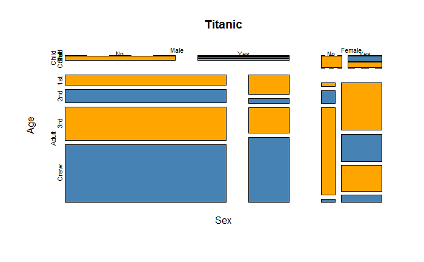

```r
## Formula interface for tabulated data:
mosaicplot(~ Sex + Age + Survived + Class, data = Titanic,
           color =c("orange","steelblue") )
```

apply함수를 이용하여 탑장자를 분석해보자.

1. 탑승자분석

```r
apply(Titanic, 1, sum)
```

전체적으로 승무원과 3등석에 많이 탄 것을 알 수 있다.

```r
apply(Titanic, 1, sum) %>%
  barplot(col =2:5, ylim =c(0, 980))%>%
  text(labels = apply(Titanic, 1, sum),
       y =  apply(Titanic, 1, sum) + 50)
```

2. 성별 탑승자 분석

```r
apply(Titanic, 2, sum)
```

시각화

```r
apply(Titanic, 2, sum)%>%
  barplot(col =3:2, ylim =c(0, 2000))%>%
  text(labels = apply(Titanic, 2, sum),
       y=  apply(Titanic, 2, sum)+100, cex = 1)
```

3. 연령별 탐승자 분석

```r
apply(Titanic, 3, sum)
```

```r
apply(Titanic, 3, sum)%>%
  barplot(col =3:2, ylim =c(0, 2400))%>%
  text(labels = apply(Titanic, 3, sum),
       y=  apply(Titanic, 3, sum)+100, cex = 1)
```

4. 생존자의 사망자 빈도

```r
apply(Titanic, 4, sum)
```

```r
apply(Titanic, 4, sum)%>%
  barplot(col =2:3, ylim =c(0, 1700),
          main="Taitanic survived")%>%
  text(labels = apply(Titanic, 4, sum),
       y =  apply(Titanic, 4, sum)+100, cex = 1)
```

5. 좌석별 생존자 분석

```r
# Class survived
apply(Titanic, MARGIN = c(1,4), sum)
```

```r
apply(Titanic, MARGIN = c(1,4), sum)%>%
  barplot(col =2:5, ylim =c(0, 800), beside=TRUE,
          main="Survivor analysis by Tatinic class",
          legend.text = rownames(apply(Titanic,
                                       MARGIN = c(1,4), sum)) )%>%
  text(labels = apply(Titanic, c(1,4), sum),
       y =  apply(Titanic, c(1,4), sum)+ 40, cex = 0.8)
```

6. 성별 생존자 분석

```r
apply(Titanic, c(2,4), sum)
```

```r
apply(Titanic, c(2,4), sum)%>%
  barplot(col = 3:2, ylim =c(0, 1500), beside=TRUE,
          main="Survivor analysis by Tatinic Sex",
          legend.text = rownames(apply(Titanic,
                                       MARGIN = c(2,4), sum)) )%>%
  text(labels = apply(Titanic, c(2,4), sum),
       y =  apply(Titanic, c(2,4), sum)+ 90, cex = 0.8)
```

7. 연령별 생존자 분석

```r
#Age survived
apply(Titanic, c(3,4), sum)
```

```r
apply(Titanic, c(3,4), sum)%>%
  barplot(col = 3:2, ylim =c(0, 1600), beside=TRUE,
          main="Survivor analysis by Tatinic Age",
          legend.text = rownames(apply(Titanic,
                                       MARGIN = c(3,4), sum)) )%>%
  text(labels = apply(Titanic, c(3,4), sum),
       y =  apply(Titanic, c(3,4), sum)+ 90, cex = 0.8)
```

### 3.1.4. 집계함수들의 활용

R에서 사용하는 집계함수는 반복함수를 사용하여 같은 일을 쉽게 만들어주는 기능이 있다. 대체로 반복되는 것들은 for문을 이용하여 계산해야 하지만, 이 함수들은 반복된 계산을 쉽게 만들어주는 기능들이 있므로 잘 이해하고 사용한다면 매우 효과적이라고 할 수 있다.

#### 3.1.4.1. lapply(list), sapply(simplity) 함수

다변량 데이터에서 데이터의 변수(열)별로 기술통계를 구하고자 할때에는 일이 좀 많아진다. 먼저 변수를 한개씩 구하고자 할 때에는 `mean(mtcars$mpg)`,…. 처럼 변수를 바꾸어가면서 여러번 해야할 일을 가볍게 계산하게 해준다.

집계함수를 이해하기 위해서는 먼저 for문을 이용하여 기술통계를 계산하는 과정을 보는게 필요할 듯 하다.  
for문은 반복하여 계산을 처리할 수 있다. 그런데, for문을 사용하여 매번 코딩하듯이 분석하는 것은 효율적인 것도 아닐 수 있다.

```r
result = list()


for (i in seq_along(mtcars)){
  result[i] = mean(mtcars[[i]])

}
names(result) = colnames(mtcars)
result
```

```
$mpg
[1] 20.09062

$cyl
[1] 6.1875

$disp
[1] 230.7219

$hp
[1] 146.6875

$drat
[1] 3.596563

$wt
[1] 3.21725

$qsec
[1] 17.84875

$vs
[1] 0.4375

$am
[1] 0.40625

$gear
[1] 3.6875

$carb
[1] 2.8125
```

간단하게 for문을 처리하여 얻었지만, 구해진 결과의 변수가 무엇인지 지정을 해야 하고, 결과를 잘 이해하기 위해서는 몇가지 수작업이 필요해진다.

이 과정을 한번에 해내는 것이 lapply함수이다. 먼저 `lapply()`함수는 다변량 데이터에 대한 결과를 list로 출력해준다. lapply(X, FUN)으로 구성이 되어있는데, 데이터와 사용할 함수를 넣으면 된다.  
먼저 lapply함수를 사용하여 mtcars데이터의 평균을 구해보자.

```r
lapply(X=mtcars, FUN = mean)
```

```
$mpg
[1] 20.09062

$cyl
[1] 6.1875

$disp
[1] 230.7219

$hp
[1] 146.6875

$drat
[1] 3.596563

$wt
[1] 3.21725

$qsec
[1] 17.84875

$vs
[1] 0.4375

$am
[1] 0.40625

$gear
[1] 3.6875

$carb
[1] 2.8125
```

list로 구성된 경우에는 str()함수를 적용하면 한번에 요약된 모습을 볼 수있다.

```r
lapply(X=mtcars, FUN = mean) %>% str()
```

```
List of 11
 $ mpg : num 20.1
 $ cyl : num 6.19
 $ disp: num 231
 $ hp  : num 147
 $ drat: num 3.6
 $ wt  : num 3.22
 $ qsec: num 17.8
 $ vs  : num 0.438
 $ am  : num 0.406
 $ gear: num 3.69
 $ carb: num 2.81
```

**list데이터를 data.frame으로 바꾸는 방법**

보통 list데이터로 나타내는 것은 특별한 목적이 아니라면 하나의 집결된 데이터프레임(data.frame)이 더 편리할 것이다. 이렇게 리스트(list)데이터를 하나의 데이터 프레임으로 나타내는 방법은 `do.call(what, arg)`로 구성된 함수를 활용한다. what에는 rbind혹은 cbind 등의 결합할 함수를 지정하면 되고, arg에는 데이터를 지정하면 된다.

```r
do.call(what = rbind, arg = lapply(X=mtcars, FUN = mean))%>%round(3)
```

```
        [,1]
mpg   20.091
cyl    6.188
disp 230.722
hp   146.688
drat   3.597
wt     3.217
qsec  17.849
vs     0.438
am     0.406
gear   3.688
carb   2.812
```

혹은 cbind를 활용하면 가로로 길게 늘어선다.

```r
do.call(what = cbind, arg = lapply(X=mtcars, FUN = mean))
```

```
          mpg    cyl     disp       hp     drat      wt     qsec     vs      am   gear   carb
[1,] 20.09062 6.1875 230.7219 146.6875 3.596563 3.21725 17.84875 0.4375 0.40625 3.6875 2.8125
```

그런데, 이렇게 데이터프레임이나 벡터 형태로 단순화(simplify)를 해야 한다면 처음부터 `sapply(X, FUN)`함수를 사용하면 된다. 이것을 이용하면 번거롭게 변환을 하지 않아도 된다. lappy와 sapply는 사용방법이 동일하고, 출력되는 결과에서 차이가 난다.

```r
sapply(X=mtcars, FUN = mean)
```

```
       mpg        cyl       disp         hp       drat         wt       qsec         vs         am
 20.090625   6.187500 230.721875 146.687500   3.596563   3.217250  17.848750   0.437500   0.406250
      gear       carb
  3.687500   2.812500
```

만약에 가로로 늘어서있는 이 데이터는 벡터(vector)데이터이므로 세로로 세우려면 data.frame()으로 변환하면 된다.

```r
sapply(X=mtcars, FUN = mean) %>%
          data.frame() %>%
              as.matrix() %>%  # matrix까지 변형
                `colnames<-`(c("평균값"))
```

```
         평균값
mpg   20.090625
cyl    6.187500
disp 230.721875
hp   146.687500
drat   3.596563
wt     3.217250
qsec  17.848750
vs     0.437500
am     0.406250
gear   3.687500
carb   2.812500
```

sapply에 대한 궁금증이 생기는 것은 range()함수와 같이 두가지 값을 나타내는 함수를 적용하면 어떻게 될 것인가이다. 이런 경우에는 두개의 원소를 행렬형태로 반환한다. 최솟값과 최댓값을 두개의 행에 나타내 준다.

```r
sapply(X=mtcars, FUN = range)
```

```
      mpg cyl  disp  hp drat    wt qsec vs am gear carb
[1,] 10.4   4  71.1  52 2.76 1.513 14.5  0  0    3    1
[2,] 33.9   8 472.0 335 4.93 5.424 22.9  1  1    5    8
```

**새로운 함수의 적용**  
`sapply(X, FUN)`에서 FUN에는 함수를 별도로 지정할 수 있다는 장점이 있다. 즉, mean 혹은 sd 등의 함수만 하나씩 적용하는 것 뿐만 아니라 함수를 만들어서 적용할 수 있다는 점이다.  
예를 들어서 함수를 평균과 표준편차, 샘플수를 구하는 함수를 만들어서 sapply에 적용해보자. 함수를 넣는다는 것은 분석의 자유도가 높아진다는 것이다. 먼저 데이터에서 factor처리된 것이 있다면 numeric변수만을 뽑아서 기술통계 분석을 하는 함수를 만들어서 sapply에적용해보자. 결과는 데이터프레임으로 되기 때문에 t()함수를 이용하여 결과데이터를 세로 방향으로 전환하여 나타내었다.

```r
#데이테 함수의 적용
sapply(mtcars, FUN = des) %>% t()
```

```
     Mean     SD        N
mpg  20.09062 6.026948  32
cyl  6.1875   1.785922  32
disp 230.7219 123.9387  32
hp   146.6875 68.56287  32
drat 3.596563 0.5346787 32
wt   3.21725  0.9784574 32
qsec 17.84875 1.786943  32
vs   0.4375   0.5040161 32
am   0.40625  0.4989909 32
gear 3.6875   0.7378041 32
carb 2.8125   1.6152    32
```

#### 3.1.4.2. map 함수

이번에는 purrr패키지의 map()함수를 이용하여 반복적인 기술통계를 진행하는 방법이다. map함수는 lapply와 같은 기능을 한다. 출력도 list로 나타난다.

```r
mtcars %>%map(mean)
```

```
$mpg
[1] 20.09062

$cyl
[1] 6.1875

$disp
[1] 230.7219

$hp
[1] 146.6875

$drat
[1] 3.596563

$wt
[1] 3.21725

$qsec
[1] 17.84875

$vs
[1] 0.4375

$am
[1] 0.40625

$gear
[1] 3.6875

$carb
[1] 2.8125
```

요약해서 볼때에는 lapply와 마찬가지로 str()을 이용하고 데이터프레임으로 전환할 때에는 do.call()함수를 활용하 수 있다.

```r
map(mtcars, mean) %>% str()
```

```
List of 11
 $ mpg : num 20.1
 $ cyl : num 6.19
 $ disp: num 231
 $ hp  : num 147
 $ drat: num 3.6
 $ wt  : num 3.22
 $ qsec: num 17.8
 $ vs  : num 0.438
 $ am  : num 0.406
 $ gear: num 3.69
 $ carb: num 2.81
```

데이터프레임으로 바꾸는 방법은 동일하다.

```r
map(mtcars, mean) %>% do.call(what = rbind)
```

```
           [,1]
mpg   20.090625
cyl    6.187500
disp 230.721875
hp   146.687500
drat   3.596563
wt     3.217250
qsec  17.848750
vs     0.437500
am     0.406250
gear   3.687500
carb   2.812500
```

그렇다면 sapply와 같은 기능을 하는 함수는 무엇일까?  
map_dbl()함수이다. map함수는 map_**으로 다앙한 함수를 제공한다.

```r
map_dbl(mtcars, mean)
```

```
       mpg        cyl       disp         hp       drat         wt       qsec         vs         am
 20.090625   6.187500 230.721875 146.687500   3.596563   3.217250  17.848750   0.437500   0.406250
      gear       carb
  3.687500   2.812500
```

map_dbl도 함수를 만들어서 적용이 가능하다.

```r
mtcars %>%
  map_dbl(function(x) length(unique(x)))
```

```
 mpg  cyl disp   hp drat   wt qsec   vs   am gear carb
  25    3   27   22   22   29   30    2    2    3    6
```

map_dbl()에서는 함수를 적용할 때, 반드시 벡터형으로 나와야 한다. 데이터프레임을 산출해내는 함수를 적용하면 오류가 생긴다. map_dbl() 함수에서 발생하는 오류는 des 함수가 데이터 프레임을 반환하기 때문에 발생한다. map_dbl()은 벡터의 각 요소에 함수를 적용하고 결과를 숫자형 벡터로 반환하는데, 이 경우 des 함수는 숫자가 아닌 데이터 프레임을 반환하기 때문에 오류가 발생하는 것이다.

```
#기술통계 함수
 des = function(x){
res = data.frame(Mean = mean(x), SD=sd(x), N=length(x))
   return(res)  }
#분석
 mtcars %>%  map_dbl(~des)
Error in `map_dbl()`:
ℹ In index: 1.
ℹ With name: mpg.
Caused by error:
! Can't coerce from a function to a double.
Backtrace:
 1. mtcars %>% map_dbl(~des)
 2. purrr::map_dbl(., ~des)
 3. purrr:::map_("double", .x, .f, ..., .progress = .progress)
 6. purrr:::call_with_cleanup(...)
```

따라서, 데이터프레임을 나타내는 함수는 map함수를 사용해야한다.  
map함수는 벡터나 리스트의 각 요소에 함수를 적용하여 리스트를 반환하는 기능이 있어서 이런 경우는 map함수를 활용한다.

|  | Mean | SD | N |
| --- | --- | --- | --- |
| mpg | 20.090625 | 6.0269481 | 32 |
| cyl | 6.187500 | 1.7859216 | 32 |
| disp | 230.721875 | 123.9386938 | 32 |
| hp | 146.687500 | 68.5628685 | 32 |
| drat | 3.596563 | 0.5346787 | 32 |
| wt | 3.217250 | 0.9784574 | 32 |
| qsec | 17.848750 | 1.7869432 | 32 |
| vs | 0.437500 | 0.5040161 | 32 |
| am | 0.406250 | 0.4989909 | 32 |
| gear | 3.687500 | 0.7378041 | 32 |

[output cut: 1 more lines]

#### 3.1.4.3. tidyverse함수

먼저 tidyverse에 있는 summarise_all()은 매우 유용하게 집계할 수 있는 함수이다.결과를 데이터프레임으로 출력해준다.

```r
mtcars %>% summarise_all(mean)
```

| mpg | cyl | disp | hp | drat | wt | qsec | vs | am | gear | carb |
| --- | --- | --- | --- | --- | --- | --- | --- | --- | --- | --- |
| 20.09062 | 6.1875 | 230.7219 | 146.6875 | 3.596563 | 3.21725 | 17.84875 | 0.4375 | 0.40625 | 3.6875 | 2.8125 |

데이터의 방향을 변경할 때에는 t()함수를 사용하면 된다.

```r
mtcars %>% summarise_all(mean) %>% t()
```

```
           [,1]
mpg   20.090625
cyl    6.187500
disp 230.721875
hp   146.687500
drat   3.596563
wt     3.217250
qsec  17.848750
vs     0.437500
am     0.406250
gear   3.687500
carb   2.812500
```

`across(.cols, .fns)`함수와 함께 사용하면 summarise()함수와 함께 전체 기술통계를 원활하게 구할 수 있다. 아래의 함수는 where()함수에 numeric변수를 찾아서 평균을 구하라고 설정한 것이다.

| mpg | cyl | disp | hp | drat | wt | qsec | vs | am | gear | carb |
| --- | --- | --- | --- | --- | --- | --- | --- | --- | --- | --- |
| 20.09062 | 6.1875 | 230.7219 | 146.6875 | 3.596563 | 3.21725 | 17.84875 | 0.4375 | 0.40625 | 3.6875 | 2.8125 |

모든 변수를 설정하는 간단한 방법은 colnames(.)을 이용하여 모든 변수명을 입력하면 전체 통계를 숩게 구할 수 있다.

| mpg | cyl | disp | hp | drat | wt | qsec | vs | am | gear | carb |
| --- | --- | --- | --- | --- | --- | --- | --- | --- | --- | --- |
| 20.09062 | 6.1875 | 230.7219 | 146.6875 | 3.596563 | 3.21725 | 17.84875 | 0.4375 | 0.40625 | 3.6875 | 2.8125 |

#### 3.1.4.4. mysummary 함수

이번에는 jjstat에서 사용하는 mysummary함수이다. `mysummary()`함수는 논문에 넣는 형식의 기술통계에 특화되어 있다. mysummary()함수는 N(샘플수), MEAN(평균), SD(분산), MIN, MAX, Skew(skewness), Kurt(Kurtosis)를 한번에 계산한 후에 변수별로 차곡 차곡 쌓아서 데이터프레임으로 만들어주는 함수이다. 이 함수는 기본적으로 변수중에서 numeric변수만을 찾아서 기술통계를 분석하는 것으로 되어 있다. 예륻 들어 iris데이터에는 4개의 numeric변수와 한개의 factor(Species)변수가 들어있는데 map_dbl에서 분석한 결과를 보자. map_dbl이나 sapply에서는 factor변수이면 NA를 나타낸다.

```r
# iris %>% sapply(mean)
iris %>%map_dbl(mean)
```

```r
iris %>% mysummary()
```

그러나, musummary에서 중요하게 사용하는 방법은 변수를 선정하여 쉽게 분석한다는 장점이 있다. 아무런 인수를 입력하지 않으면 전체의 기술통계를 계산한다. 먼저 전체를 계산한 것을 보자.

```r
# mysummary(mtcars)
mtcars %>% mysummary()
```

통계분석이 필요한 변수를 추가로 넣기만 하면 그 변수를 분석하고, 인수에 변수명만 계속 추가하면 누적하여 나타낸다.  
먼저 mpg 변수만 분석해보려면 “mpg”변수만 인수로 추가하면 된다.

```r
mysummary(mtcars, "mpg")
```

이번에는 mpg, wt, hp변수만을 선정하여 기술통계를 만들어보자.

```r
mysummary(mtcars, "mpg","wt","hp")
```

만약에 다른 통계치가 필요하지 않고 mean, sd, n만 필요하다면 `msdn = TRUE`로 하면 이 3가지 통계량만을 보여준다.

```r
mysummary(mtcars, "mpg","wt","hp", msdn = TRUE)
```

| var | N | MEAN | SD |
| --- | --- | --- | --- |
| mpg | 32 | 20.09062 | 6.0269481 |
| wt | 32 | 3.21725 | 0.9784574 |
| hp | 32 | 146.68750 | 68.5628685 |

결과를 정리할 때 자리수를 선정해야 하는 경우가 자주 생기는데, 이때에는 `jjstat::Round`함수를 사용한다. round함수와 달리 첫글자가 대문자이다. 이는 수치형 변수만을 찾아서 라운딩 처리를 해주는 함수이다.

```r
#소수점 자리수를 2자리로 변경
mysummary(mtcars, "mpg","wt","hp", msdn = TRUE) %>% Round(2)
```

| var | N | MEAN | SD |
| --- | --- | --- | --- |
| mpg | 32 | 20.09 | 6.03 |
| wt | 32 | 3.22 | 0.98 |
| hp | 32 | 146.69 | 68.56 |

### 3.1.5. 집단 요약 집계함수의 활용

집단요약함수로서의 집계함수는 여러가지가 있다. 이 집계함수의 활용은 그룹별로 요약한다는 면에서 매우 유용하다.

### 3.1.5.1 tapply함수

그룹별로 집계하는 함수는 가장 간단하게는 tapply함수가 있다. INDEX에는 변수를 지정할 수도 있고, list()함수를 이용하여 지정하는 방법도 있다. list로 지정하면 열의 이름을 설정할 수 있다.

```r
tapply(mtcars$mpg, INDEX = list(Cylinder = mtcars$cyl), FUN=mean)
```

```
Cylinder
       4        6        8
26.66364 19.74286 15.10000
```

두개이상의 변수를 설멍하여 그룹별로 평균을 구할 때에는 `INDEX = list(V1, V2)`형태로 입력하여 나타내면 되는데, 출력되는 형태가 헝태가 행렬형태로 나타난다.

```r
with(mtcars, tapply(mpg, list(CYL = cyl, TRANS = am), mean))
```

```
   TRANS
CYL      0        1
  4 22.900 28.07500
  6 19.125 20.56667
  8 15.050 15.40000
```

### 3.1.5.2 aggregate함수

aggregate()함수는 tappply()함수보다 더 다양하게 활용할 수 있는 기능들이 있다. aggregate()함수는 출력이 데이터프레임으로 나타난다. aggregate()함수는 사용하는 방법이 인수를 입력하는 방식과 formula를 사용하는 방식이 모두 가능한 함수이다

| CYL | x |
| --- | --- |
| 4 | 26.66364 |
| 6 | 19.74286 |
| 8 | 15.10000 |

데이터에 특별한 변수를 입력하지 않으면 데이터내에 존재하는 변수들을 지정된 FUN에 따라 모두 계산한다. 아래는 mtcars데이터에서 cyl에 따라서 그룹별로 모든 변수의 평균을 구하도록 한 것이다. 구하는 변수가 numeric변수가 아닌 경우 NA가 출력된다.

```r
data(mtcars)
mtcars$am = factor(mtcars$am, levels=c(0,1),
                   labels= c("automatic","manual" ))
mtcars$vs  = factor(mtcars$vs, levels=c(0,1),
                    labels= c("V-shaped","straight" ))
mtcars$cyl  = factor(mtcars$cyl, levels=c(4,6,8),
                     labels= c("cyl-4","cyl-6","cyl-8"))

aggregate(mtcars, list(mtcars$cyl), mean)
```

| Group.1 | mpg | cyl | disp | hp | drat | wt | qsec | vs | am | gear | carb |
| --- | --- | --- | --- | --- | --- | --- | --- | --- | --- | --- | --- |
| cyl-4 | 26.66364 | NA | 105.1364 | 82.63636 | 4.070909 | 2.285727 | 19.13727 | NA | NA | 4.090909 | 1.545455 |
| cyl-6 | 19.74286 | NA | 183.3143 | 122.28571 | 3.585714 | 3.117143 | 17.97714 | NA | NA | 3.857143 | 3.428571 |
| cyl-8 | 15.10000 | NA | 353.1000 | 209.21429 | 3.229286 | 3.999214 | 16.77214 | NA | NA | 3.285714 | 3.500000 |

with()함수를 사용하는 방법도 가능하다. 변수가 2개이상 사용하면 그에 맞추어서 분류를 하여 통계치를 제공한다.

```r
with(mtcars, aggregate(mpg, list(CYL = cyl, TRANS = am), mean))
```

| CYL | TRANS | x |
| --- | --- | --- |
| cyl-4 | automatic | 22.90000 |
| cyl-6 | automatic | 19.12500 |
| cyl-8 | automatic | 15.05000 |
| cyl-4 | manual | 28.07500 |
| cyl-6 | manual | 20.56667 |
| cyl-8 | manual | 15.40000 |

대체로 변수를지정하는 방법은 `$`를 이용하여 변수를 지정하는 것이 편리하지는 않다. 그래서 formula를 사용하는 방식(S3 method for class ‘formula’)이 더 편리하다.

`aggregate(x, data, FUN, ..., subset, na.action = na.omit)`

인수를 지정하는 방식은 순서대로 입력하면 굳이 x, data, FUN을 지정하지 않아도 된다.

```r
aggregate(x = mpg ~ cyl,  data = mtcars, FUN = mean)
```

| cyl | mpg |
| --- | --- |
| cyl-4 | 26.66364 |
| cyl-6 | 19.74286 |
| cyl-8 | 15.10000 |

만약에 그룹의 평균이 아니라 한개의 변수에 관한 평균을 구하고자 한다면, “변수 ~ 1”형태로 지정하면 된다.

```r
aggregate(mpg ~ 1, data = mtcars, mean)
```

| mpg |
| --- |
| 20.09062 |

포뮬러 형식의 장점은 변수의 결합을 다양하게 할 수있다는 점이다. 일단 cyl, am의 그룹을 나누어서 mpg의 평균을 구해보자. 일종의 `종속변수 ~ 독립변수` 형태로 지정하여 통계치를 구하는 형태라고 생각하면 될 것이다.

```r
aggregate(mpg ~ cyl + am, mtcars, mean)
```

| cyl | am | mpg |
| --- | --- | --- |
| cyl-4 | automatic | 22.90000 |
| cyl-6 | automatic | 19.12500 |
| cyl-8 | automatic | 15.05000 |
| cyl-4 | manual | 28.07500 |
| cyl-6 | manual | 20.56667 |
| cyl-8 | manual | 15.40000 |

aggregate는 그룹만 여러개 지정하는 것이 아닌 통계치를 구해야 하는 변수들도 여러개 지정할 수 있는데, 이 변수들은 `cbind()` 함수를 사용하여 지정한다. 평균을 구하는 변수를 mpg, hp, wt까지 모두 구해보았다.

```r
aggregate( cbind(mpg, hp, wt)  ~ cyl + am, mtcars, mean)
```

| cyl | am | mpg | hp | wt |
| --- | --- | --- | --- | --- |
| cyl-4 | automatic | 22.90000 | 84.66667 | 2.935000 |
| cyl-6 | automatic | 19.12500 | 115.25000 | 3.388750 |
| cyl-8 | automatic | 15.05000 | 194.16667 | 4.104083 |
| cyl-4 | manual | 28.07500 | 81.87500 | 2.042250 |
| cyl-6 | manual | 20.56667 | 131.66667 | 2.755000 |
| cyl-8 | manual | 15.40000 | 299.50000 | 3.370000 |

**모든 변수의 통계치**  
즉 최종적으로 모든 변수를 구한다면 . `. ~ cyl + am`로 입력하면 된다. 이번에는 `. ~ cyl`형태로 입력해보자.

```r
aggregate( .  ~ cyl , mtcars, mean)
```

| cyl | mpg | disp | hp | drat | wt | qsec | vs | am | gear | carb |
| --- | --- | --- | --- | --- | --- | --- | --- | --- | --- | --- |
| cyl-4 | 26.66364 | 105.1364 | 82.63636 | 4.070909 | 2.285727 | 19.13727 | 1.909091 | 1.727273 | 4.090909 | 1.545455 |
| cyl-6 | 19.74286 | 183.3143 | 122.28571 | 3.585714 | 3.117143 | 17.97714 | 1.571429 | 1.428571 | 3.857143 | 3.428571 |
| cyl-8 | 15.10000 | 353.1000 | 209.21429 | 3.229286 | 3.999214 | 16.77214 | 1.000000 | 1.142857 | 3.285714 | 3.500000 |

만약에 그룹변수가 많지 않다면 포뮬러를 `변수 ~ .`으로 지정할 수 있다. 이러한 형식을 지정하기에는 mtcars데이터가 너무 복잡해져서 ToothGrowth데이터를 사용하였다.

```r
aggregate(len ~ ., data = ToothGrowth, mean)
```

| supp | dose | len |
| --- | --- | --- |
| OJ | 0.5 | 13.23 |
| VC | 0.5 | 7.98 |
| OJ | 1.0 | 22.70 |
| VC | 1.0 | 16.77 |
| OJ | 2.0 | 26.06 |
| VC | 2.0 | 26.14 |

이렇게 그룹별로 구해진 통계치를 행렬이나 table형태로 나타내는 방법은 xtabs을 이용하는 방법이다. xtabs(formula, data)형식으로 지정하기 때문에 `%>%`을 사용하는 경우에는 formula라고 지정해주어야 한다. 포뮬러를 지정할 때에는 value값이 되는 이름을 사용하여 “len ~ .”이란 방법으로 지정해주면 된다.

```r
aggregate(len ~ ., data = ToothGrowth, mean) %>%
  xtabs(formula = len ~.)
```

```
    dose
supp   0.5     1     2
  OJ 13.23 22.70 26.06
  VC  7.98 16.77 26.14
```

이와 같이 table로 만드는 경우는 jjstat의 to_table을 사용해도 된다. to_table()함수를 사용할 때에는 현재 value값이 어떤 열에 있는지 이름을 지정해주면 된다. to_table()함수는 마지막 열이 value를 나타낸다고 기본 가정하에 계산을 하기 때문에 마지막열이 통계치가 적용되어 있다면, value에 대한 값을 지정하지 않아도 자동으로 계산된다.

```r
aggregate(len ~ ., data = ToothGrowth, mean) %>% to_table() #이것도 가능
```

```
     0.5     1     2
OJ 13.23 22.70 26.06
VC  7.98 16.77 26.14
```

```r
# aggregate(len ~ ., data = ToothGrowth, mean) %>% to_table(value = "len") #정확하게 지정
```

### 3.1.5.3 group_by 및 summarise함수

tidyverse의 group_by와 summarise를 이용하여 그룹별 평균이나 분산 등 통계치를 구할 수 있는 방법도 있다. 실제로 분석할 때 자주 사용되는 방법이기도 하다. summarise()함수에는 통계치를 구하고자 하는 변수에 대하여 여러가지 함수를 한번에 적용할 수 있다. 다른 함수에 비해 더 긴 것 같지만, 우리의 머리속에서 인식한대로 나타나다보니 오히려 기억하기가 좋은 면이 있다.

```r
mtcars %>%
  group_by(cyl) %>%
  summarise(M = mean(mpg), SD = sd(mpg), N = n())
```

| cyl | M | SD | N |
| --- | --- | --- | --- |
| cyl-4 | 26.66364 | 4.509828 | 11 |
| cyl-6 | 19.74286 | 1.453567 | 7 |
| cyl-8 | 15.10000 | 2.560048 | 14 |

summarise()함수엔 여러가지 함수를 넣어서 원하는 형태의 통계치를 만들어낼 수 있다.  
주로 분석을 하면서 필요한 부분을 추출하여 내용을 보여주고자 할 때에는 매우 편리한 방식이라고 할 수 있다. 또한 필요한 부분을 결합하여 사용하는 방식은 tidyverse의 특징이기도 하지만 이러한 방식은 분석하는 코드를 기억하기좋게 만들어준다.

```r
mtcars %>% group_by(cyl) %>%
  summarise(SN = n(), mpg_Mean = mean(mpg), disp_Mean = mean(disp),  hp_mean = mean(hp)
)
```

| cyl | SN | mpg_Mean | disp_Mean | hp_mean |
| --- | --- | --- | --- | --- |
| 4 | 11 | 26.66364 | 105.1364 | 82.63636 |
| 6 | 7 | 19.74286 | 183.3143 | 122.28571 |
| 8 | 14 | 15.10000 | 353.1000 | 209.21429 |

```r
NA
```

만약 그룹화하여 전체의 평균(통계치)를 구하려고 할 때에는 summarise_all()함수를 이용하는 것이 빠르고 쉽게 필요한 통계치를 얻을 수 있다.

```r
mtcars %>% group_by(cyl) %>% summarise_all(mean)
```

| cyl | mpg | disp | hp | drat | wt | qsec | vs | am | gear | carb |
| --- | --- | --- | --- | --- | --- | --- | --- | --- | --- | --- |
| cyl-4 | 26.66364 | 105.1364 | 82.63636 | 4.070909 | 2.285727 | 19.13727 | NA | NA | 4.090909 | 1.545455 |
| cyl-6 | 19.74286 | 183.3143 | 122.28571 | 3.585714 | 3.117143 | 17.97714 | NA | NA | 3.857143 | 3.428571 |
| cyl-8 | 15.10000 | 353.1000 | 209.21429 | 3.229286 | 3.999214 | 16.77214 | NA | NA | 3.285714 | 3.500000 |

### 3.1.5.4 mysummaryBy함수

`mysummaryBy()`함수는 그룹을 중심으로 통계치를 구하는 함수이다.

```r
# mysummaryBy(mpg ~ 1, data = mtcars)

mtcars %>% mysummaryBy(mpg ~ 1 )
```

| Mean | SD | N | Min | Max | Skew | Kurt |
| --- | --- | --- | --- | --- | --- | --- |
| 20.09062 | 6.026948 | 32 | 10.4 | 33.9 | 0.610655 | -0.372766 |

```r
NA
```

한개의 변수만을 분석하다보면 그 결과가 어떤 변수를 분석한 것인지 알기 어렵다. 이ㅓㄴ 경우 add_var=“mpg”를 추가하여 분석한 변수가 무엇인지 표현해주는 방법이 있다.

```r
mysummaryBy(mpg ~ 1, data = mtcars, "mpg")
```

| stat_var | Mean | SD | N | Min | Max | Skew | Kurt |
| --- | --- | --- | --- | --- | --- | --- | --- |
| mpg | 20.09062 | 6.026948 | 32 | 10.4 | 33.9 | 0.610655 | -0.372766 |

fun옵션에 함수를 지정하면 그 함수만을 계산하여 정리해준다.

```r
mtcars %>% mysummaryBy(mpg ~  1 , fun = mean )
```

| ...1 |
| --- |
| 20.09062 |

포뮬러를 변수 ~ 1로 정하는 것은 그 변수만을 구하는 것이지만, `변수 ~ 변수(그룹변수)`의 관계이면, 그룹별 통계치를 구해준다. 평균(Mean), 표준편차(SD), 샘플수(N), 최소M(Min), 최대(Max), 왜도(Skewness), 첨도(Kurtosis)까지 구하는 함수이다.

```r
mysummaryBy(mpg ~ vs, data = mtcars)
```

| var | Mean | SD | N | Min | Max | Skew | Kurt |
| --- | --- | --- | --- | --- | --- | --- | --- |
| V-shaped | 16.61667 | 3.860699 | 18 | 10.4 | 26.0 | 0.4848484 | -0.04617697 |
| straight | 24.55714 | 5.378978 | 14 | 17.8 | 33.9 | 0.4055612 | -1.40081941 |

그룹을 더 세분화하여 그룹이 2개이상안 경우 변수를 + 로 합쳐서 표현하면, 기술통계치를 구해보자.

```r
mysummaryBy(mpg ~ vs + am, data = mtcars)
```

| vs | am | Mean | SD | N | Min | Max | Skew | Kurt |
| --- | --- | --- | --- | --- | --- | --- | --- | --- |
| V-shaped | automatic | 15.05000 | 2.774396 | 12 | 10.4 | 19.2 | -0.2843325 | -0.9635443 |
| straight | automatic | 20.74286 | 2.471071 | 7 | 17.8 | 24.4 | 0.1014749 | -1.7480372 |
| V-shaped | manual | 19.75000 | 4.008865 | 6 | 15.0 | 26.0 | 0.2050011 | -1.5266040 |
| straight | manual | 28.37143 | 4.757701 | 7 | 21.4 | 33.9 | -0.3474537 | -1.7290639 |

포뮬라 형식으로 그룹을 분류하는 방법이 생각보다는 더 편리하고, 또한 그룹으로 분류될 개수는 많아진다 하더라도 그에 맞추어서 계산값을 나타내준다.

```r
mysummaryBy(mpg ~ vs + am + cyl, data = mtcars)
```

[output not shown]

agg옵션은 통계치의값을 세로로 바꾸어주는 기능을 한다. 먼저 `mpg ~ vs+am`에 해당하는 것들을 세로 바꾸어보자.

| stat_var | X1 | X2 | X3 | X4 |
| --- | --- | --- | --- | --- |
| vs | V-shaped | straight | V-shaped | straight |
| am | automatic | automatic | manual | manual |
| mpg.Mean | 15.0500000 | 20.7428571 | 19.7500000 | 28.3714286 |
| mpg.SD | 2.7743959 | 2.4710707 | 4.0088652 | 4.7577005 |
| mpg.N | 12.0000000 | 7.0000000 | 6.0000000 | 7.0000000 |
| mpg.Min | 10.4000000 | 17.8000000 | 15.0000000 | 21.4000000 |
| mpg.Max | 19.2000000 | 24.4000000 | 26.0000000 | 33.9000000 |
| mpg.Skew | -0.2843325 | 0.1014749 | 0.2050011 | -0.3474537 |
| mpg.Kurt | -0.9635443 | -1.7480372 | -1.5266040 | -1.7290639 |

통계치 변수를 여러개 지정한 경우 mysummaryBy에서는 한번에 여러가지 통계치를 나타내기 때문에 가로로 상당히 길어져서 불편해진다. 이런 경우 agg(집계방식)에 대한 옵션을 이용하여 세로로 만들어주는게 좋다. `cbind(mpg, hp) ~ vs+am`에 대한 내용을 수행해보자. 통계치는 madn=TRUE로 해서 mean, sd, n을 나타내보자.

```r
mysummaryBy(cbind(mpg, hp) ~ vs+am, data = mtcars, msdn = TRUE, agg = TRUE)
```

| stat_var | X1 | X2 | X3 | X4 |
| --- | --- | --- | --- | --- |
| vs | V-shaped | straight | V-shaped | straight |
| am | automatic | automatic | manual | manual |
| mpg.Mean | 15.050000 | 20.742857 | 19.750000 | 28.371429 |
| mpg.SD | 2.774396 | 2.471071 | 4.008865 | 4.757701 |
| mpg.N | 12.000000 | 7.000000 | 6.000000 | 7.000000 |
| hp.Mean | 194.16667 | 102.14286 | 180.83333 | 80.57143 |
| hp.SD | 33.35984 | 20.93186 | 98.81582 | 24.14441 |
| hp.N | 12.00000 | 7.00000 | 6.00000 | 7.00000 |

인수중에는 stat옵션이 있는데, 이는 t.test 혹은 aov를 수행하는 것이다. 실제 R에서 사용하는 함수명이라서 기억하기도 쉽다. stat =“t.test”가 지정되면 두개의 그룹인경우 t.test를 결과를 나타내준다.

```r
mysummaryBy(mpg ~ vs , data = mtcars, stat="t.test")
```

| var | Mean | SD | N | Min | Max | Skew | Kurt |
| --- | --- | --- | --- | --- | --- | --- | --- |
| V-shaped | 16.61667 | 3.860699 | 18 | 10.4 | 26.0 | 0.4848484 | -0.04617697 |
| straight | 24.55714 | 5.378978 | 14 | 17.8 | 33.9 | 0.4055612 | -1.40081941 |

| estimate | estimate1 | estimate2 | statistic | p.value |
| --- | --- | --- | --- | --- |
| -7.940476 | 16.61667 | 24.55714 | -4.667053 | 0.0001098368 |

```
NA
```

cyl(실린더개수)변수처럼 수준이 3개인 경우에는 stat=“aov”로 설정해야 한다. ANOVA검정표와 기술통계가 제시된다.

```r
mysummaryBy(mpg ~ cyl , data = mtcars, stat="aov")
```

| var | Mean | SD | N | Min | Max | Skew | Kurt |
| --- | --- | --- | --- | --- | --- | --- | --- |
| 4 | 26.66364 | 4.509828 | 11 | 21.4 | 33.9 | 0.2591965 | -1.6450119 |
| 6 | 19.74286 | 1.453567 | 7 | 17.8 | 21.4 | -0.1583137 | -1.9069714 |
| 8 | 15.10000 | 2.560048 | 14 | 10.4 | 19.2 | -0.3628186 | -0.5655154 |

[output not shown]

여기에서 그룹의 평균을 구할 때에도 유용하게 사용하는 데 한 변수에 대한 그룹의 평균과 그 변수의 평균은 다르게 나타나기 때문이다. mtcars데이터에서 mpg의 평균은 20.09이다.

| var | N | MEAN | SD |
| --- | --- | --- | --- |
| mpg | 32 | 20.09062 | 6.026948 |

그룹별로 평균을 확인해보면 ,am==0인 경우는 17.14737이고, am==1인 경우는 24.39231이다. $ = 20.76984 $라는 값이 나온다. 다은은 가 그룹의 평균을 보자.

| var | Mean | SD | N |
| --- | --- | --- | --- |
| 0 | 17.14737 | 3.833966 | 19 |
| 1 | 24.39231 | 6.166504 | 13 |

그룹별로 평균을구한 후에 mysummary()함수를 이용하여 그룹들의 평균을 구하였다. 그 결과 20.76984라는 값이 동일하게 나왔다. 물론 mysummary()함수 대신에 mysummaryBy()함수를 두 번사용해도 된다.

| var | N | MEAN | SD |
| --- | --- | --- | --- |
| Mean | 2 | 20.76984 | 5.122946 |

mysummaryBy()함수를 2번 사용하여 얻어낸 결과는 다음과 같다.

```r
mysummaryBy(mpg ~ am , data= mtcars) %>%
  mysummaryBy( Mean ~ 1 , msdn = T)
```

### 3.1.6. 정규성 검정

정규성 검정이란 데이터가 정규분포를 따르는지 확인하는 과정을 말한다. 정규분포는 평균을 중심으로 좌우 대칭인 분포를 말하는데, 정규성 검정은 모수적 방법과 비모수적 방법으로 수행되게 된다. 가설 검정을 수행하기 전에 데이터의 정규성을 확인하는 것이 일반적이다. 정규성 검정을 하는 이유는 데이터 정규성을 가정한 통계 검정들의 결과가 믿을 수 있는지 없는지를 체크하는 것인데, 즉 믿을만한 데이터인지 검정하는 과정이라고 볼 수 있다.  
정규성 검정 절차로 알려진 몇가지 유명한 것들이 있는데, 첫째, Shapiro-Wilk 검정이다. 작은 샘플 크기에서 사용되며, 정규성을 확인하는데 사용한다. 둘째, Kolmogorov-Smirnov 검정은 주로 큰 샘플 크기에서 사용되며, 분포의 차이를 확인하는데 사용한다. 셋째로 Anderson-Darling 검정: 다양한 분포에 대해 정규성을 검정한다고 알려져 있다.

#### 3.1.3.1. Shapiro-Wilk 검정

가설 검정을 수행하기 전에 데이터의 정규성을 확인하며, 샘플 크기가 작을 때 특히 유용하다. 정규성이 확보되면 t-검정이나 분산 분석(ANOVA)과 같은 모수적 방법을 사용하게 된다.

```
귀무가설 (H₀): 표본의 모집단이 정규분포를 따른다.
대립가설 (H₁): 표본의 모집단이 정규분포를 따르지 않는다.
```

검정 통계량 (W)은 다음과 같이 계산한다.
$$W = \frac{\left(\sum_{i=1}^{n} a_i
X_{(i)}\right)2}{\sum_{i=1}{n} (X_i - \bar{X})^2}$$
여기서 $X_{(i)}$는 순서통계량(order statistic) $a_i$는 정규분포를 갖는 계수
가설검정에서 중요한 것은 p> 0.05 일때 정규성이 확보된다는 점을 잊어서는 안되겠다.

```r
# 데이터 생성
set.seed(123)
data <- rnorm(100)
data  %>%  head(30)
```

```
 [1] -0.56047565 -0.23017749  1.55870831  0.07050839  0.12928774  1.71506499
 [7]  0.46091621 -1.26506123 -0.68685285 -0.44566197  1.22408180  0.35981383
[13]  0.40077145  0.11068272 -0.55584113  1.78691314  0.49785048 -1.96661716
[19]  0.70135590 -0.47279141 -1.06782371 -0.21797491 -1.02600445 -0.72889123
[25] -0.62503927 -1.68669331  0.83778704  0.15337312 -1.13813694  1.25381492
```

데이터의 정규성을 확인하기 위해서 히스토그램과 밀도그래프를 그렸다.

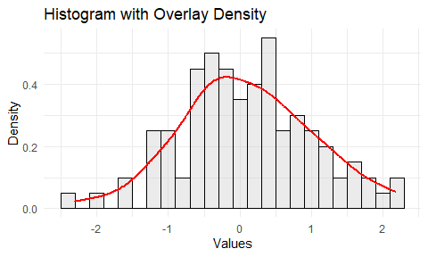

```r
# density plot
ggplot(data.frame(data), aes(x = data)) +
  geom_histogram(aes(y = ..density..), alpha = 0.4,
                 binwidth = 0.2, color = "black", fill = "gray80") +
  geom_density(color = "red", size = 1) +
  labs(title = "Histogram with Overlay Density",
       x = "Values", y = "Density") +
  theme_minimal()
```

R-base에서 그리는 방법도 있다. 독자의 편리성에 따라서 잘 익숙해지는 방법을 찾아서 그리면 될 것이다.

```r
# 히스토그램 그리기
hist(data, probability = TRUE,
     col = "lightblue",
     main = "Histogram with Overlay Density")
# 밀도 그래프 그리기
lines(density(data), col = "red", lwd = 2)
```

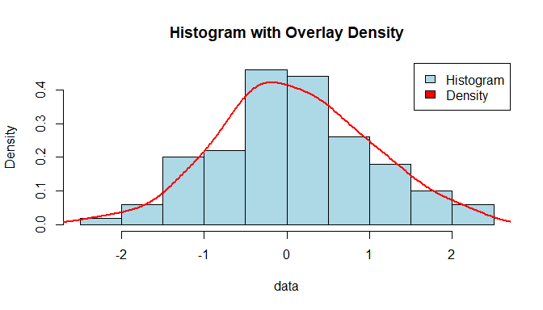

```r
# 범례 추가
legend("topright",
       legend = c("Histogram", "Density"),
       fill = c("lightblue", "red"))
```

```r
# 샤피로 윌크 검정 수행
shapiro.test(data)
```

```
    Shapiro-Wilk normality test

data:  data
W = 0.99388, p-value = 0.9349
```

분석결과를 보면 다음과 같다.

```
    Shapiro-Wilk normality test

 data:  data
 W = 0.99388, p-value = 0.9349
```

p-value = 0.9349로서 p > 0.05이므로 정규성이 나타나는 자료라고 할 수 있다. shapiro.test는 한번에 한개의 변수만을 검정할 수 있다.

다음은 jjstat::report_stat함수를 이용하여 정규성 검정에 대한 해석결과를 보고자 한다. report_stat()함수는 인수로 데이터를 받아서, type을 결정하면된다. type=“normality”로 되어있으면 정규성에 대한 검정결과를 보여준다. 특히 정규성을 검정하는 nomality는 기본설정(default)으로 되어있다.

```r
shapiro.test(data)  %>%
  jjstat::report_stat("normality")
```

```
[1] "Shapiro-Wilk normality test showed that the normality was secured by rejecting the alternative hypothesis because it was not statistically significant. statistic = 0.994, p = 0.935)"
```

```r
#같은 방법
# shapiro.test(data)  %>%
#   jjstat::report_stat()
```

기본은 영어로 나타내게 되어있는데, 이를 한국어로 번역하여 나타내고 싶다면, trans옵션에서 TRUE로 두면 한국어로 번역해서 나타내준다. jjstat패키지의 번역프로그램을 이용하는 것이므로 우리말로는 자연습지 않을 수도 있으니 적절하게 이해해야 한다.

```r
shapiro.test(data)  %>%
  jjstat::report_stat("normality", trans = TRUE)
```

여러개의 변수에 대하여 정규성 검정을 해야 한다면 jjstat패키지의 shapiro_test_all()를 이용한다. 선택한 변수에 대한 정규성 검정을 해준다. 검정해야 할 변수가 많은 경우 이것을 활용하면 편리할 것이다.

```r
data_mtcars <- mtcars[,c("mpg","disp","hp","drat","wt","qsec")]
data_mtcars %>%
   jjstat::shapiro_test_all()
```

|  | variable | W | p.value | hypotheses |
| --- | --- | --- | --- | --- |
| W | mpg | 0.948 | 0.123 | Normality * |
| W1 | disp | 0.920 | 0.021 | reject |
| W2 | hp | 0.933 | 0.049 | reject |
| W3 | drat | 0.946 | 0.110 | Normality * |
| W4 | wt | 0.943 | 0.093 | Normality * |
| W5 | qsec | 0.973 | 0.594 | Normality * |

```r
NA
```

다음은 첨도와 왜도를 이용하여 정규성을 점검하는 방법이다. 각 데이터에서 mysummary() 함수를 이용하여 기술통계를 생성한 후에 이 데이터를 이용하여 왜도와 첨도를 쵸준화하여 정규성을 검정하는 방법이다.

```r
data_mtcars %>% mysummary()%>% add_normality()
```

| var | N | MEAN | SD | Skew | Kurt | Skew_z | Kurt_z | skew_TF | kurt_TF |
| --- | --- | --- | --- | --- | --- | --- | --- | --- | --- |
| mpg | 32 | 20.090625 | 6.0269481 | 0.6106550 | -0.37276603 | 1.4733845 | -0.39343189 | Good | Good |
| disp | 32 | 230.721875 | 123.9386938 | 0.3816570 | -1.20721195 | 0.9208596 | -1.27413883 | Good | Good |
| hp | 32 | 146.687500 | 68.5628685 | 0.7260237 | -0.13555112 | 1.7517452 | -0.14306597 | Good | Good |
| drat | 32 | 3.596563 | 0.5346787 | 0.2659039 | -0.71470062 | 0.6415712 | -0.75432306 | Good | Good |
| wt | 32 | 3.217250 | 0.9784574 | 0.4231465 | -0.02271075 | 1.0209650 | -0.02396982 | Good | Good |
| qsec | 32 | 17.848750 | 1.7869432 | 0.3690453 | 0.33511422 | 0.8904301 | 0.35369269 | Good | Good |

#### 3.1.3.2. Kolmogorov-Smirnov 검정

Kolmogorov-Smirnov 검정은 데이터의 누적 분포 함수와 비교하고자 하는 분포의 누적 분포 함수 간의 최대 거리를 통계량으로 사용하는 가설 검정 방법이다. 주로 정규성 검정에서 사용되며, 다른 분포와도 비교할 수 있다는 장점이 있다. Kolmogorov-Smirnov 검정에서는 최대 거리를 검정통계량으로 사용한다. 최대 거리는 데이터의 누적 분포 함수와 비교하고자 하는 분포의 누적 분포 함수 간의 차이를 측정한다.

```
귀무가설 (H₀): 표본의 모집단이 정규분포를 따른다.
대립가설 (H₁): 표본의 모집단이 정규분포를 따르지 않는다.
```

검정통계량 D는 다음과 같다.

$$D = \max(|F_{\text{data}}(x) -
F_{\text{normal}}(x)|)$$
여기서 $F_{\text{data}}(x)$는 데이터의 누적 분포 함수(CDF)이고, $F_{\text{normal}}(x)$은 정규분포의 CDF를 나타낸다.

데이터를 하나 생성해서 검정을 시행해보자.

```r
ksdata<- c(6, 1, -4, 8, -2, 5, 0)
mean(ksdata); sd(ksdata)
```

**평균과 표준편차를 가정하여 정규분포와 비교하는 방법**

먼저, 평균과 표준편차를 가정하여 데이터가 정규분포를 따르는지 확인하는 방법이 있다. 이는 데이터의 분포를 미리 가정해서 확인하고 시행하는 방법이므로 강력한 방법이라고 할수 있다.

```r
# Kolmogorov-Smirnov 검정 수행
ks.test(ksdata, "pnorm",
        mean = mean(ksdata),
        sd = sd(ksdata))
```

**데이터의 분포를 정규분포와 비교하는 방법**  
반면에 평균과 표준편차를 가정하지 않는 경우는 데이터의 분포만을 기준하여 정규분포와 비교하는 방법으로 매우 유연한 방법으로 비교하는 것이라고 할 수 있다.

```r
ksdata<- c(6, 1, -4, 8, -2, 5, 0)
ks.test(ksdata, "pnorm")
```

jjstat패키지의 report_stat()를 이용하여 결과를 확인해보자. 앞에서 보여주었던 것처럼 report_stat()함수의 경우는 정규성 검정결과는 정규성에 맞게 디폴트 설정대로 사용하면 된다.

```r
ks.test(ksdata, "pnorm")  %>%
  jjstat::report_stat()
```

#### 3.1.3.3. Anderson-Darling 검정

Anderson-Darling 검정은 데이터의 적합도를 평가하는 데 사용된다. 특히 적합선(선택된 분포에 근거)과 비모수적 계단 함수(표시 점에 근거) 사이의 영역을 측정하는 방법을 사용하는데, Anderson-Darling 값이 작을수록 분포가 데이터를 보다 잘 적합시킨다고 할 수있다.

$$A^2 = -n - \frac{1}{n} \sum_{i=1}^{n}
\left[ \frac{2i - 1}{2n} \left( \ln(F(X_{(i)})) + \ln(1 -
F(X_{(n+1-i)})) \right) \right]$$

$X_{(i)}$는 순서통계량(order statistic)이며, $F(X_{(i)})$는 해당 순서통계량의 누적 분포 함수(CDF) 값을 나타낸다.  
Anderson-Darling검정은 nortest 패키지의 ad.test를 사용한다. 인수는 벡터를 받는다. mtcars의 mpg데이터에 대한 정규성을 검정해보자.

```r
# library(nortest)
nortest::ad.test(mtcars$mpg)
```

비교를 위해서 ks.test에서 활용한 데이터도 한번 검정해보자.

```
  ksdata<- c(6, 1, -4, 8, -2, 5, 0)
  nortest::ad.test(ksdata)
  "nortest::ad.test(ksdata)에서 다음과 같은 에러가 발생했습니다:sample size must be greater than 7"
```

```r
nortest::ad.test(c(6, 1, -4, 8, -2, 5, 1, 3))
```

jjstat::report_stat()를 이용하여 결과를 정리해보자.

```r
nortest::ad.test(c(6, 1, -4, 8, -2, 5, 1, 3))  %>%
  jjstat::report_stat(trans = FALSE)
```

```r
#정밀하게 확인하기
# jjstat::histogram(c(6, 1, -4, 8, -2, 5, 1, 3))
hist(c(6, 1, -4, 8, -2, 5, 1, 3))
```

추가적으로 정규성을 검정하는 방법은 Q-Q (Quantile-Quantile) Plot을 이용하는 방법도 있다. Q-Q Plot을 그려보고, 데이터가 정규분포를 따르는지 확인하는 방법은 만약 점들의 분포가 45도 직선상에 모여 있게 되면, 정규분포를 따른다고 할 수 있다.  
이를 시각화 하면 다음과 같이 할 수 있다.

```r
ksdata<- c(6, 1, -4, 8, -2, 5, 0)
# Q-Q Plot 그리기
qqnorm(ksdata)  # 점 형태로 그리기
qqline(ksdata, col = 2)  # 근사선 그리기
```

## 3.2. 척도분석

이 부분은 처음 통계를 공부하거나 R을 사용하여 분석을 하는 경우 쉽지 않은 부분이다. 따라서, 이 부분을 과감히 넘어가는 것도 가능하다. 이 과정을 먼저 소개하는 이유는 실제로 논문을 쓸 때 측정도구(설문지)를 이용하여 측정된 내용에 대하여 문항에 대한 신뢰도와 타당도를 분석한 후에 통계분석에 들어가기 때문이다. 따라서, 실제 연구절차에 맞추어서 척도분석 파트를 먼저 소개하려고 한다. 사회과학 분야에서는 매우 중요하게 다루는 영역이기 때문이다(백영민, 2018).

척도 분석은 설문조사나 척도의 타당성과 신뢰성을 평가하는 과정이다. 척도 분석을 통해 척도가 연구 목적에 맞게 잘 구성되었는지,측정하고자 하는 개념을 정확하게 측정하는지 판단하거나 확인할 수 있다.  
척도 분석은 크게 타당성 분석과 신뢰도 분석으로 나눌 수 있다.

**가. 신뢰도 분석**

신뢰도 분석은 척도가 일관되고 정확하게 측정하는지 확인하는 과정이다. 신뢰도 분석에는 여러 가지 방법이 있으며, 대표적인 방법으로는 다음과 같은 것들이 있다.

1. 테스트-재테스트 신뢰도: 척도를 두 번 이상 측정하여 결과가 일관되는지 확인하는 방법이다.
2. 분할 신뢰도: 척도를 여러 개의 하위 척도로 나누어 각 하위 척도의 신뢰도를 확인하는 방법이다.
3. 내적 일관성 계수: 척도의 문항들이 서로 얼마나 일관성이 있는지 확인하는 방법이다. 대표적인 내적 일관성 계수로는 크론바흐 알파 (Cronbach’s alpha)가 있으며, 대부분의 논문에서는 크론바흐 알파를 사용한다.

**나. 타당성 분석**

타당성 분석은 척도가 측정하고자 하는 개념을 실제로 측정하는지 확인하는 과정이다. 타당성 분석에는 여러 가지 방법이 있으며, 대표적인 방법으로는 다음과 같은 것들이 있다.  
(1) 내적 타당성: 문항들이 측정하고자 하는 개념을 잘 나타내는지 확인하는 분석이다.  
(2) 구성 타당성: 척도의 요인 구조가 연구자가 가정한 모델과 일치하는지 확인하는 분석이다.  
(3) 차별 타당성: 척도가 다른 개념과 구별되는지 확인하는 분석이다.  
(4) 외부 타당성: 척도 결과가 다른 척도나 기준과 일치하는지 확인하는 분석이다.

척도 분석이 중요한 이유는 연구 결과의 신뢰성과 타당성을 확보할수 있기 때문이다. 척도 분석을 통해 척도의 문제점을 파악하고 개선하여 연구 결과의 질을 높일 수 있다는 점에서 매우 중요하다고 할 수 있다.

### 3.2.1. 신뢰도 분석

신뢰도 분석은 설문조사 또는 척도의 신뢰성을 평가하는 방법이다. 즉 신뢰성은 측정 도구가 얼마나 일관되고 정확하게 측정한 것인지를 나타내는 척도로 활용된다. 특히 가장 많이 사용되는 것이 **크론바흐 알파 (Cronbach’s alpha)**인데, 신뢰도 분석에 가장 많이 사용되는 지표이다. 크론바흐 알파는 복수의 변수들이 단일차원에 속해있는지 살펴볼 때 가장 많이 활용하는 통계치이기도 하다(백영민, 2018). 이 지표는 설문 문항 간의 내적 일관성을 측정하여 척도의 신뢰성을 평가하는데 자주 사용된다. 크론바흐 알파 값은 0에서 1 사이이며, 값이 높을수록 척도의 신뢰성이 높다는 것을 의미합하는데, 일반적으로 0.7 이상이면 신뢰성이 높다고 판단한다(Cronbach, 1951). 하지만, 연구 분야, 척도의 특성, 표본 크기 등에 따라 기준값은 달라질 수 있으니 0.7보다 작다고해서 무조건 삭제하거나 문제있다고 판단해서는 안된다. 크론바흐 알파는 척도의 신뢰성을 평가하는 데 유용한 지표이다. 하지만, 단독으로 사용하기보다는 다른 지표들과 함께 고려하여 척도의 신뢰성을 판단하는 것이 바람직하다고 할 수 있다.

$$α = \frac{K}{K-1} \left( 1 -
\frac{\sum_{i=1}^{K} \sigma_i^2}{\sigma_x^2} \right)$$
$K$: 문항 수
$σ_i^2$: i번째 문항의 분산
$σ_x^2$: 전체 문항들의 분산

#### 3.2.1.1. 신뢰도 분석

**신뢰도를 높이는 방법**

- 문항을 명확하게 작성하는 것이 중요하다. 참여자가 문항을 읽고 정확한 의미를 알수 있게 만들어야 신뢰도가 높아지는 것이다. 특히 한 문항안에 2가지 이상의 질문을 넣지 않도록 하는 것이 중요한데, 대체로 문항을 만들면서 자신도 모르게 여러가지를 물어보는 경우가 있다. 예를 들면, ’선생님은 친절하면서 잘 가르친다’라고 1~7점을 표시하라고 했다면, 이는 친절함을 측정하라는 것인지 잘 가르치는 것을 측정하라는 것인지 헷갈릴 수 있다는 것이다.
- 문항의 내용을 일관되게 유지한다.
- 불필요한 문항을 제거한다. 선행연구를 통해서 측정하고자 하는 문항만을 사용하는 것이 좋다.
- 예비 조사를 통해 문항을 수정한다.

wemen 데이터에 대해여 alpha함수를 적용해보자. 이는 설문데이터는 아니지만 간단히 설명하기 위해서 임의로 적용한 것이므로 독자들은 여기에서 나타난 숫자에는 큰 의미부여를 하지 않길 바란다.

```r
women  %>%
  psych::alpha()  %>%
  summary()
```

```
Reliability analysis
```

|  | raw_alpha | std.alpha | G6(smc) | average_r | S/N | ase | mean | sd | median_r |
| --- | --- | --- | --- | --- | --- | --- | --- | --- | --- |
|  | 0.6931025 | 0.9977423 | 0.9954948 | 0.9954948 | 441.9283 | 0.00944264 | 100.8667 | 9.977594 | 0.9954948 |

Raw Alpha값은 크론바흐 알파 계수는 0.693으로 나타났다. 이 값은 설문지의 항목들이 얼마나 일관되게 응답되었는지를 나타내는데, 이 값이 높다는 것은 설문지의 항목의 신뢰도가 높다는 것을 의미한다. Standardized Alpha (표준화된 알파) 계수는 0.998로 나타났다. 이 값은 설문지의 항목들이 얼마나 일관되게 응답되었는지를 표준화하여 나타낸 값이다. G6 (Guttman’s Lambda 6)계수는 0.995이었다. 이 값은 설문지의 항목들이 얼마나 일관되게 응답되었는지를 다른 방식으로 평가한 값이다. 선형회귀를 기준으로 계산된 $R^2$과 비슷한 통계치이며, 활용하는 빈도는 높지 않은 편이다. Average Inter-Item Correlation (평균 항목간 상관계수)는 0.995인데, 이값은 설문지의 항목들이 얼마나 상호 연관되어 있는지를 나타내는 피어슨 상관계수의 평균값이다.  
S/N는 신호대비 잡음비(Signal-to-Noise Ratio)이며, S/N은 441.92로 나타났다. 설문지의 신호(일관성)와 노이즈(불일치성)의 비율을 나타내며 측정문항과 측정문항들 사이의 피어슨 상관계수를 이용하여 계산한 값인데, 자주 사용하지 않는다. Alpha Standard Error는 알파 계수의 표준 오차이며, Item Statistics는 항목 통계로 평균과 표준편차를 모두 나타낸다. Non-Missing Response Frequency는 응답 빈도, 각 항목에 대한 응답 빈도를 나타낸다. check.keys = TRUE라는 옵션은 간혹 나타나는 역코딩되어야할 변수에 대한 것을 점검해주고, 그것을 감안해서 측정해주는 옵션이다.

**데이터로 이해하는 신뢰도 분석**

이번에는 jjstat패키지의 stat_onl(박중희, 2023)데이터의 일부를 이용하여 신뢰도를 분석해보자. 여기에서 학습앱만족도에 관한 요소로 upgrade(사용향상감), satisfy(사용만족도), fatigue(사용피로감)에 대한 측정 결과이다. 이중에서 fatigue요소는 역코딩을 해야하는 변수인데, 분석의 절차를 이해하고 확인하기 위해서 원래의 변수를 먼저 그대로 넣어서 분석을 해보도록 하자.

```r
stat_onl  %>%
  dplyr::select(upgrade, satisfy, fatigue)  %>%
        psych::alpha() %>%
        summary()
```

신뢰도 분석 결과 매우 낮은 값인 0.2345379이라는 값이 나타났다.  
일부 항목에서 주요 구성요소와 부적 상관이 나타나고 있으니 ‘check.keys=TRUE’ 라는 옵션을 추가하라는 것이 함수를 다시 해보라는 것이다. 아마도 처음에 말한 것처럼 역코딩 되어야 할 변수 사용피로감(fatigue)의 문제로 보인다. 이번에는 check.keys=TRUE라는 옵션을 넣어서 분석해보자.

```r
stat_onl  %>%
  dplyr::select(upgrade, satisfy, fatigue)  %>%
        psych::alpha(check.keys=TRUE) %>%
        summary()
```

이번에는 신뢰도 값이 0.7(=0.6994)로 높은 값으로 변하였다. 출력되는 메시지도 변경되었다.

```
     Some items were negatively correlated with the first principal component and were automatically reversed. This is indicated by a negative sign for the variable name.
```

함수에서 알아서 fatigue변수를 역코딩을 해서 출력했다는 의미이다. 그러나, 크론바흐 알파를 분석하면서 임의로 역코딩해서 분석한 것이지 실제로 역코딩이 된 것은 아니다. 그렇다면 summary된 결과가 아니라 실제 세부적인 것들을 점검할 필요가 있으므로 한번 확인해보자.

```r
stat_onl  %>%
  dplyr::select(upgrade, satisfy, fatigue)  %>%
        psych::alpha(check.keys=TRUE)
```

```
Reliability if an item is dropped:
          raw_alpha std.alpha G6(smc) average_r   S/N alpha se var.r med.r
upgrade       0.43     -0.81   -0.29     -0.29 -0.45    0.130    NA -0.29
satisfy       0.46     -0.89   -0.31     -0.31 -0.47    0.127    NA -0.31
fatigue-      0.80      0.81    0.68      0.68  4.20    0.047    NA  0.68
```

이것은 upgrade를 제거(drop)을 시키면, 전체 신뢰도는 0.43으로 변한다는 의미지고, fatigue- 를 제외(drop)시키면 크론바흐 알파값은 0.80으로 변한다는 의미이다.  
예를 들어, fatigue(사용피로감)변수를 제외한 상태에서 분석해보자.

```r
#fatiguefmf 제거(drop)한 후 분석
jjstat::stat_onl  %>%
  dplyr::select(upgrade, satisfy)  %>%
        psych::alpha(check.keys = TRUE)  %>%
          summary()
```

```
Reliability analysis
```

|  | raw_alpha | std.alpha | G6(smc) | average_r | S/N | ase | mean | sd | median_r |
| --- | --- | --- | --- | --- | --- | --- | --- | --- | --- |
|  | 0.8049024 | 0.8078224 | 0.6776024 | 0.6776024 | 4.203521 | 0.04679292 | 4.375 | 1.42571 | 0.6776024 |

여기에 나타난 값은 크론바흐 알파값이 0.8049024라는 높은 값으로 변경되었다.

**신뢰도가 좋지 않은 경우 연구자가 고민할 것은…**  
이쯤 되면 연구자 혹은 독자들은 유혹에 빠지기 쉽다. 신뢰도를 높이기 위해서 신뢰도를 낮추는 문항들을 사정없이 숙청(drop)시키면서 제외시키는 행동을 하기 쉽다는 것이다. 그러나, 잊지 말아야 할 것은 수치적으로 신뢰도를 높이는 것은 위험한 행동이다. 즉, 연구목적을 위해 임의로 설정한 변수, 혹시 몰라 추가로 확인하는 변수들이 있을 수 있는데, 이는 처음부터 제외할 수 도 있는 변수들이 있다는 것이다. 이러한 것들이 신뢰도에 영향을 주면 빼내도 된다. 그러나, 그것이 아니라 반드시 사용해야 하는 변수라면, 마구 지워서는 안된다. 신뢰도가 잘못된 중요한 이유를 먼저 설명한 것들이 있는데, 이를 참고하여 신뢰도를 높이는 연구를 해야한다. 측정도구(설문지)부터 재점검하고 제대로 다시 측정하는 것이 좋다. 따라서, 점검이 안된 설문지를 본 조사에 사용하는 것은 지극히 좋지 않은 행동이다. 따라서, 측정도구를 완성할 때 좀 더 정밀하게 만들어야 하고, 선행연구를 통해서 미리 연구하는 것이 중요하다.

이제 fatigue변수를 역코딩하여 넣어보자. 역코딩은 2.2.1.4.절에서 이미 이야기를 하였다. 리커트 척도의 제일 큰값에서 1을 더한후에 변수의 값을 빼면 된다.

먼저 fatigue값을 보자.이 값은 1~7점으로 된 리커트 척도이다.

```r
stat_onl$fatigue
```

이를 역코딩하는 값은 다음과 같다.

```r
fatigue_reverse = 8 - stat_onl$fatigue
fatigue_reverse
```

stat_onl데이터에는 이를 미리 계산하여 둔 fatigue_inverse 변수가 미리 계산되어 있어서 이것을 사용하여 분석해보면 된다.

데이터는 upgrade, satisfy, fatigue_inverse(역코딩)데이터를 이용하여 신뢰도를 분석해보았다.

```r
stat_onl  %>%
  dplyr::select(upgrade, satisfy, fatigue_inverse)  %>%
        psych::alpha() %>%  summary()
```

이제 데이터를 정리하는 방법을 알아보자.

```r
stat_onl  %>%
  dplyr::select(upgrade, satisfy, fatigue_inverse)  %>%
  jjstat::alpha_table()
```

| Var | alpha_95%CI | subfactor | cronbach alpha |
| --- | --- | --- | --- |
| .1 | alpha = 0.699, 95%CI[0.55, 0.8] | upgrade | 0.4263113 |
| .2 | alpha = 0.699, 95%CI[0.55, 0.8] | satisfy | 0.4593506 |
| .3 | alpha = 0.699, 95%CI[0.55, 0.8] | fatigue_inverse | 0.8049024 |

다음과 같이 표로 만들어서 활용할 수 있다. 약간의 편집을 통해서 논문에 넣을 수 있는 표로 만들어질 수 있다.  
표. 온라인앱 사용만족도 신뢰도 분석

| Var | alpha_95%CI | subfactor | cronbach alpha |
| --- | --- | --- | --- |
| .1 |  | upgrade | 0.4263113 |
| .2 | alpha = 0.699, 95%CI[0.55, 0.8] | satisfy | 0.4593506 |
| .3 |  | fatigue_inverse | 0.8049024 |

논문에 넣을 때 필요한 부분은 표로 정리한 모습이다. 이러한 부분에서 편리함을 제공한다.  
그런데 이렇게 한개의 요인만 하는 것이 아니라 여러 개의 요인을 분석하여 정리하는 경우는 매번 분석한 내용을rbid혹은 bind_rows()함수를 이용하여 결합해야 한다.

결과를 보면, 아래와 같이 결합할 수 있다.그런데 생각보다 코드는 복잡한 모습을 가지고 있다.

```r
dplyr::bind_rows(
stat_onl %>% select(S_Review, S_Add_learn, S_Feedback) %>%
  jjstat::alpha_table(show="data", variable = "A" ),
stat_onl %>% select(SE_Place, SE_Time) %>%
  jjstat::alpha_table(show="data", variable = "B"),
stat_onl %>% select(On_Satisfy, On_Joy, On_Easy, On_Engage) %>%
  jjstat::alpha_table(show="data", variable = "C"),
stat_onl %>% select(upgrade,satisfy,fatigue_inverse) %>%
 jjstat::alpha_table(show="data", variable = "D")
 )
```

| Var | alpha_95%CI | subfactor | cronbach alpha |
| --- | --- | --- | --- |
| A1 | alpha = 0.84, 95%CI[0.76, 0.9] | S_Review | 0.7923222 |
| A2 | alpha = 0.84, 95%CI[0.76, 0.9] | S_Add_learn | 0.7705651 |
| A3 | alpha = 0.84, 95%CI[0.76, 0.9] | S_Feedback | 0.7708075 |
| B1 | alpha = 0.879, 95%CI[0.8, 0.93] | SE_Place | 0.8558135 |
| B2 | alpha = 0.879, 95%CI[0.8, 0.93] | SE_Time | 0.7227740 |
| C1 | alpha = 0.877, 95%CI[0.82, 0.92] | On_Satisfy | 0.8238116 |
| C2 | alpha = 0.877, 95%CI[0.82, 0.92] | On_Joy | 0.8292648 |
| C3 | alpha = 0.877, 95%CI[0.82, 0.92] | On_Easy | 0.8653063 |
| C4 | alpha = 0.877, 95%CI[0.82, 0.92] | On_Engage | 0.8491109 |
| D1 | alpha = 0.699, 95%CI[0.55, 0.8] | upgrade | 0.4263113 |

[output cut: 2 more lines]

사실 복잡하기 보다는 같은 것이 반복된 것뿐인데, 복잡해보인다. 그러나, 이러한 부분에서 신뢰도 테이블을 빠르게 만들고 논문에 넣는 것은 jjstat패키지를 이용하면 된다.  
jjstat::bind_alpha_table() 함수를 이용하면이러한 부분에서 편리하게 결합된 내용을 만들 수 있다. 예를 들어보면 다음과 같다.

```r
## select variable
bind_alpha_table(data = stat_onl,
                 c("S_Review", "S_Add_learn", "S_Feedback")) # 변수 선택
```

| Var | alpha_95%CI | subfactor | cronbach alpha |
| --- | --- | --- | --- |
| a1 | alpha = 0.84, 95%CI[0.76, 0.9] | S_Review | 0.7923222 |
| a2 | alpha = 0.84, 95%CI[0.76, 0.9] | S_Add_learn | 0.7705651 |
| a3 | alpha = 0.84, 95%CI[0.76, 0.9] | S_Feedback | 0.7708075 |

여기에서 주의할 것은 bind_alpha_table(data = stat_onl, c(S_Review, S_Add_learn, S_Feedback))와 같은 방법은 열을 찾아낼 수 없고, “S_Review”와 같이 따옴표를 넣어서 해주어야 한다.  
만약에 변수의 열 번호를 알고 있다면 변수의 열번호를 입력하여 구할 수도 있다. 변수명이 아니라 열번호에 어떤 변수가 있는지 안다면 입력을 쉽게하여 분석할 수도 있다.

```r
#select col number
bind_alpha_table(data = stat_onl, c(9:11))
# 같은 방법
# bind_alpha_table(data = stat_onl, c(9, 10, 11))
```

다변량 데이터를 한번에 하려면 모든 변수를 순서대로 입력하면된다. 예를 들면 다음과 같다. 데이터를 입력하고 c()함수를 이용하여 한번에 묶어서 요인으로 크론바흐 알파값을구할 것들을 묶어서 입력하면 된다. 결과는 아래와 같다.

```r
# multivariate data
jjstat::bind_alpha_table( stat_onl,
        c("S_Review", "S_Add_learn", "S_Feedback"),
        c("SE_Place", "SE_Time"),
        c("On_Satisfy", "On_Joy", "On_Easy", "On_Engage"),
        c("upgrade","satisfy","fatigue_inverse")
)
```

물론 이함수에는 변수의 위치, 즉 열번호를 알면 열번호를 혼합해서 입력해도 같은 결과를 나타낸다.

```r
# Multivariate data, and the column number and variable name are mixed
bind_alpha_table( stat_onl,
        c("S_Review", "S_Add_learn", "S_Feedback"),
        c("SE_Place", "SE_Time"),
        c("On_Satisfy", "On_Joy", "On_Easy", "On_Engage"),
        c(5:6, 21)
)
## %>%  knitr::kable(align="cccc", digits = 3, booktabs = TRUE,
             #    caption ="Table.  신뢰도 분석 결과")
```

신뢰도를 분석하는 과정은 R에서는 생각보다 간단하다. psych:alpha함수를 이용하여 세밀하게 확인하는 과정과 jjstat패키지의 alpha_table과 bind_alpha_table을 이용하여 원하는 표를 빠르게 완성하는 것도 좋은 활용이 될 것이다.

다음의 표는 신뢰도 분석 결과의 일부를 편집한 것이다.

| Var | alpha_95%CI | subfactor | cronbach alpha |
| --- | --- | --- | --- |
| a1 |  | S_Review | 0.7923222 |
| a2 | alpha = 0.84, 95%CI[0.76, 0.9] | S_Add_learn | 0.7705651 |
| a3 |  | S_Feedback | 0.7708075 |
| b1 | alpha = 0.879, 95%CI[0.8, 0.93] | SE_Place | 0.8558135 |
| b2 |  | SE_Time | 0.7227740 |
| c1 |  | On_Satisfy | 0.8238116 |
| c2 | alpha = 0.877, 95%CI[0.82, 0.92] | On_Joy | 0.8292648 |
| c3 |  | On_Easy | 0.8653063 |
| c4 |  | On_Engage | 0.8491109 |
| d1 |  | upgrade | 0.4263113 |
| d2 | alpha = 0.699, 95%CI[0.55, 0.8] | satisfy | 0.4593506 |
| d3 |  | fatigue_inverse | 0.8049024 |

#### 3.2.1.2. 이분형 변수의 신뢰도 측정

측정한 항목들이 연속형 변수가 아니라 이분형변수 (0, 1)로 코딩된 변수일 경우에는 KR20(Kuder-Richardson formula 20)이라고 한다. 측정문항들이 이론적으로 위계적 관계를 가지는 경우 뢰빙거의 H(Loveinger’s coefficient H)를 사용한다(Mokken, 1971; Sijtsma & Molenaar, 2002; Sijtsma & Van der Ark, 2017).

mtcars의 am, vs을 위계적 데이터라고 가정하고, 이 데이터를 사용하여 분석해보자.

```r
library(mokken)
data(mtcars)
MTC <- mtcars  #분석데이터
MTC$am <- as.numeric(MTC$am )  # numeric변수로 변환
MTC$vs <- as.numeric(MTC$vs )  # numeric변수로 변환

# mokken::coefH(MTC[,c("am","vs")], results = FALSE)$H
mokken::coefH(MTC[,c("am","vs")])
```

분석결과는 $H부분을 확인하면 된다. 결과값은 .179로 나타난 것을 확인할 수 있다.

### 3.2.2. 요인 분석(factor Analysis)

주성분 분석과 요인분석은 다변량 통계 기법 중 하나로, 관측된 변수들 간의 상관성을 고려하여 적은 수의 잠재변수 (요인)로 설명하는 방법이다. 구체적으로 말하면 측정의 구성타당도(construct validity), 즉 수렴타당도와 판별타당도를 점검할 때 사용하는 기법이다. 주성분 분석과 요인분석은 추정하는 방식이 다른 기법이다(Fabrigar & Wegener, 2011). 추정기법도 다르지만 사실 목적은 확연하게 다르다. 주성분 분석은 데이터의 요약(차원 축소; 측정항목 -> 주성분)가 목적인 반면, 요인분석은 잠재적 인자구조를 탐색(잠재적 인자구소 -> 측정한목)하는 이라는 것이다.주성분 분석은 측정항목의 분산이 주성분에 있는 분산과 오차분산으로 나눅지만, 탐색적 요인분석에서는 인자에 적재된 분산(commulality)와 측정항목의고유분산(uniqueness), 오차분산으로 나눈다. 따라서 추정결과는 차이가 날 수 밖에 없다.

사회과학분석에서 연구자는 자신이 어떤 연구를 하고 있는지, 그 목적에 따라서 주성분분석과 요인분석을 선택하여 사용할 수 있다. 요인분석은 서로 상관관계가 높은 변수들을 그룹화하여 숨겨진 공통 요인을 찾는 통계 기법이다. 이를 통해 데이터의 복잡성을 줄이고 변수들 간의 관계를 더 쉽게 이해할 수 있도록 하는데 목적이 있다.

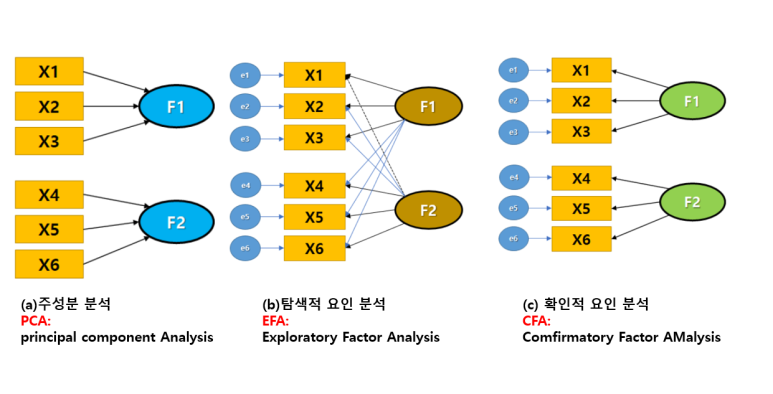

요인분석

요약하면 다음과 같이 설명된다.  
PCA는 오차항을 고려하지 않고, 변수들의 분산을 최대한 설명하는 주성분을 찾는다.  
EFA는 이론적 구조가 불분명할 때 사용되며, 변수들을 요인으로 축약하는 과정이다.  
CFA는 이미 존재하는 이론이나 가설을 데이터와 비교하여 검증하는 과정이다.

요인분석에서 **MLFA (Maximum Likelihood Factor Analysis)**와 **PCFA (Principal Component Factor Analysis)**는 각각 다른 접근 방식을 가지고 있습니다. 이 두 방법의 장단점을 살펴보자

PCFA (Principal Component Factor Analysis):

```
*장점:
 - 빠른 계산: 주성분분석을 통해 차원을 축소하면서 요인분석을 수행하므로 계산량이 적다.
 - 간단한 모델: 주성분분석은 간단한 선형 변환을 통해 요인을 추출하므로 모델 가정이 단순.

* 단점:
 -상관성 무시: 주성분분석은 변수들 간의 상관성을 고려하지 않고 분산을 최대화하는 요인을 추출
 - 모델 가정 부족: 데이터의 분포를 가정하지 않기 때문에 모델 가정이 부족할 수 있다.
```

요인분석을 선택할 때는 연구 목적, 데이터의 특성, 계산량, 모델 가정 등을 고려하여 적절한 방법을 선택해야한다.

MLFA (Maximum Likelihood Factor Analysis):

```
* 장점:
 - 모델 기반: 최대우도법을 기반으로 하기 때문에 통계적으로 더 강력한 모델을 제공
 - 정확한 추정: 데이터의 분포를 가정하고 모수를 추정하기 때문에 정확한 추정이 가능
 - 변수 간 상관성 고려: 변수들 간의 상관성을 고려하여 요인을 추출

* 단점:
 - 계산량: 최대우도법은 계산량이 많아서 큰 데이터셋에서 시간이 오래 걸릴 수 있다.
 - 모델 가정: 데이터의 분포를 가정하고 모델을 설정해야 하므로 가정이 잘못된 경우 결과가 왜곡될 수 있다.
```

#### 3.2.2.1. 주성분 요인분석(PCFA; Principal Component Factor Analysis)

주성분분석은 변수들 간의 상관관계를 갖는 많은 변수를 서로 상관관계가 없는 소수의 변수로 변환하는 차원 축소 기법이다. 이는 변수들의 선형결합으로 표현되는 주성분을 추출하며, 주로 자연과학에서 사용되는 경우가 많다. 주성분분석은 오차항을 포함하지 않으며, 변수들의 분산을 최대한 설명할 수 있는 주성분을 찾는데 초점을 맞추고 있다.

주성분분석은 Pearson(1901)에 의해 처음 연구되기 시작되었는데, Pearson(1901)은 p-차원 공간에 놓이는 데이터에 대해 가장 잘 적합하는 직선이나 평면을 찾는데 관심이 있었고 기하학적 최적화 문제로 접근하였다. 32년 후 Hoteling(1933)은 원래 p개 변수의 값을 대신 결정할 수 있는 저차원의 독립변수들의 집합이 존재할 것이라는 아이디어로부터 출발하여 원래 변수들의 분산을 최대로 설명하는 성분을 구하게 되었고 이와 같은 성분들을 ’주성분(principal component)’이라고 부르게 되었다.

주성분 분석의 목적은 다음과 같이 요약할 수 있다.

```
(1) 차원 축소
(2) 변동이 큰 축 탐색
(3) 주성분을 통한 데이터의 해석 등.
```

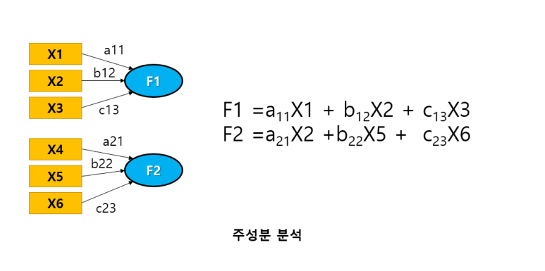

$$F1 = a_{11}*X1 + b_{12}*X2 + c_{13}*X3$$
$$F2 = a_{21}*X4 +b_{22}*X5
+ c_{23}*X6$$

SPSS에 보면 요인 추출방법에 **주성분**이라는 것이 보인다. 이게 바로 주성분 분석이다. 만약에 이것으로 요인 분석을 했다면 이는 요인분석을 한 것이 아니라 주성분 분석을 한 것이라고 할 수 있다. 주성분 분석은 서로 상관이 없다는 전제를 가지고 하는 경우가 많다. 보통 이 선형결합의 내적의 합이 0이되는 경우가 많은데, 내적의 합이 0이라는 의미는 90도를 나타낸다. 이 말은 상관이 없다는 말이다. 그래서 직각회전이라고 부른다. 이러한 회전방법에는 Varimax, Quartimax 등의 방법이 있다.

PCFA (Principal Component Factor Analysis)는 PCFA는 주성분분석(PCA)과 요인분석을 결합한 방법이다. 주성분분석을 통해 원변수들을 선형 변환하여 새로운 변수들을 생성한 후, 이를 요인분석에 활용하는 방법으로 사용된다. 주성분분석은 원변수들의 분산을 최대화하는 새로운 변수들을 찾는 기법인데, PCFA는 데이터의 차원을 축소하면서 요인분석을 수행하므로, 변수들 간의 상관성을 고려하면서 데이터를 설명하는 잠재적인 요인들을 추출하게 된다. R에서는 psych 패키지의 principal() 함수를 사용하여 PCFA를 수행할 수 있다.

먼저 사용해볼 데이터는 MVT 패키지의 examScor(Open/Closed book data)데이터이다.5개 과목에서 시험을 본 88명의 학생들에 대한 마르디아, 켄트, 비비의 데이터셋이다. 처음 두 과목은 일반적인 책 시험으로 시험을 치렀고 마지막 세 과목은 오픈북 시험으로 시험을 치렀다.

```r
# install.package("MVN")
library(MVT)
data(examScor)
examScor%>% str()
```

데이터의 일부를보면 다음과 같다.

```r
examScor%>% head()
```

이제 데이텨를 통하여 표준화 한 후에 상관계수를 구해보자.  
표준화(scale)를 하는 이유는 각 과목의 난이도와 수준, 척도가 다르기 때문이다.

```r
X = examScor #data
Z = scale(X, scale=T)  #표준화

R = cor(X)  # correlation matrix
R
```

```
           mechanics   vectors   algebra  analysis statistics
mechanics  1.0000000 0.5534052 0.5467511 0.4093920  0.3890993
vectors    0.5534052 1.0000000 0.6096447 0.4850813  0.4364487
algebra    0.5467511 0.6096447 1.0000000 0.7108059  0.6647357
analysis   0.4093920 0.4850813 0.7108059 1.0000000  0.6071743
statistics 0.3890993 0.4364487 0.6647357 0.6071743  1.0000000
```

분석을 위해 데이터에 대한 것을 살펴보자. pairs.panels()함수를 이용하여 전체 상관계수와 히스토그램, 산점도를 얻을 수 있다.

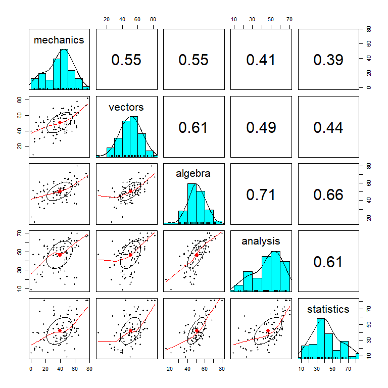

```r
examScor %>% psych::pairs.panels()
```

주성분의 개수를 추청하는 방법은 3가지가 알려져있다.  
첫째, 카이저 규칙(Kaiser’s rule)으로 고윳값이 1 이상인 값의 개수를 요인의 개수로 선택하는 방법이다. 둘째, 스크리 도표로 고윳값이 완만해지기 직전의 요인 개수를 선택한다. 셋째, 평행분석인데, 실제 데이터와 랜덤 데이터의 고윳값을 비교하여 요인의 개수를 추정하는 방법이다.

카이저 규칙을 체크하기 위해 고유값(Eigen-value)를 구해보았다. 이때 사용한 주성분 분석 함수는 prcomp()이다.

```r
prcomp(examScor, scale. = TRUE)$sdev^2
```

```
[1] 3.1809801 0.7395718 0.4449651 0.3878924 0.2465905
```

스크리플롯(scree-plot)를 그려보면 다음과 같다.

[figure not shown]

```r
examScor %>% cor() %>% prcomp()
```

```
Standard deviations (1, .., p=5):
[1] 3.767023e-01 2.266662e-01 1.959146e-01 1.475708e-01 3.334397e-17

Rotation (n x k) = (5 x 5):
                  PC1        PC2        PC3        PC4        PC5
mechanics  -0.5622832  0.4726783 -0.2925142  0.2455007 -0.5608722
vectors    -0.3370218 -0.7700178  0.3039673  0.0565188 -0.4448578
algebra     0.2443929 -0.1954052 -0.2313054  0.9144498  0.1112131
analysis    0.4745865 -0.2292351 -0.6604345 -0.2880708 -0.4506224
statistics  0.5341289  0.3048212  0.5765096  0.1316507 -0.5216274
```

상관행렬을 구한 후에 주성분 분석을 통해서 스크리플롯을 그려보자.

[figure not shown]

**nScree** nFactors패키지의 nScree()함수는 다양한 방법으로 적절한 요인의 수가 몇개인지 추천해주는 시스템을 가지고 있다. nScree 함수는 탐색적 주성분 분석 또는 요인 분석에서 유지할 구성 요소 또는 요인의 수를 분석한다. 이 함수는 Kaiser 규칙과 병렬 분석을 기준으로 유지해야 할 구성 요소/요인의 수에 대한 정보를 반환해준다.

| noc | naf | nparallel | nkaiser |
| --- | --- | --- | --- |
| 1 | 1 | 1 | 1 |

현재 nScree()함수를 활용하여 검증해보면, 요인은 1개로 추정된다.  
noc (Optimal Coordinates)는 최적 좌표가 이전 고유값의 외삽된 좌표를 나타내는데,최적 좌표를 유지하려면 Kaiser 규칙 또는 병렬 분석 기준 (parallel)도 동시에 만족해야 한다. naf (Acceleration Factor)는 가속도 요소로 스크리 플롯의 팔꿈치(굽어지는 곳)가 나타나는 위치를 나타낸다. 이는 곡선의 가속도, 즉 두 번째 도함수에 해당한다. nparallel (Parallel Analysis)는 병렬 분석을 나타내며, 무작위 데이터와 비교하여 유지해야 할 주성분 또는 요인의 수를 결정한다. nkaiser (Kaiser Rule), Kaiser 규칙은 주로 평균 또는 백분위수와 같은 위치 통계량 (일반적으로 1번째, 5번째, 95번째 또는 99번째)을 사용하여 계산된다. 주로 고유값이 평균 이상인 경우를 고려한다.상관 행렬을 사용할 때는 평균이 1이고, 공분산 행렬이나 요인 분석에서는 평균만 사용한다.

**평행분석과 연구자의 판단**  
평행분석 시뮬레이션은 데이터에서 발견되는 주성분의 개수를 추정한다(Glorfeld, 1995;Horn, 1965). 평행분석은 실제 데이터와 동일한 표본 크기를 가진 랜덤 데이터를 생성한 후, 두 데이터의 고윳값을 비교하는 방법이다. 실제 데이터의 고윳값이 랜덤 데이터보다 높은 지점의 요인 수를 선택하는 것이데, 이 방법은 이론적으로 타당하며 경험적으로도 요인의 개수를 정확하게 추정하는 것으로 알려져 있다. 주성분 분석의 요인의 개수를 추정하는 정확한 방법으로알려져있다.

```
Parallel analysis suggests that the number of factors =  1  and the number of components =  1
```

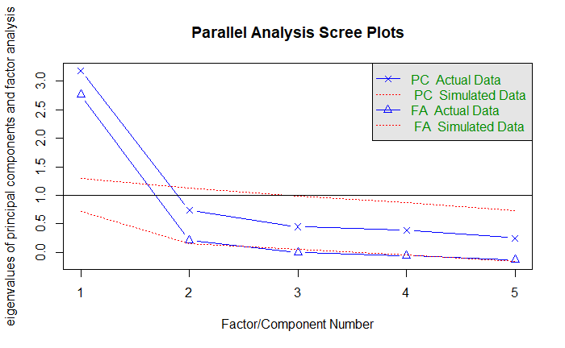

```r
psych::fa.parallel(R, n.obs = 88, cor="cor", plot =TRUE)
```

현재추천되는 요인은 1개로 나타나고 있다. 연구자 판단

```r
nFactors::componentAxis(R, nFactors=2)
```

```
$values
[1] 3.1809801 0.7395718

$varExplained
[1] 63.62 14.79

$cumVarExplained
[1] 63.62 78.41

$loadings
           [,1]       [,2]
[1,] -0.7127067  0.5550836
[2,] -0.7694490  0.3796873
[3,] -0.8976179 -0.1109959
[4,] -0.8150623 -0.3335926
[5,] -0.7816221 -0.4045832

$communalities
[1] 0.8160687 0.7362142 0.8180380 0.7756105 0.7746206
```

```r
psych::principal(R, nfactor = 2)
```

```
Principal Components Analysis
Call: psych::principal(r = R, nfactors = 2)
Standardized loadings (pattern matrix) based upon correlation matrix
```

|  | RC1 | RC2 | h2 | u2 | com |
| --- | --- | --- | --- | --- | --- |
| mechanics | 0.19 | 0.88 | 0.8160687 | 0.1839313 | 1.093424 |
| vectors | 0.35 | 0.78 | 0.7362142 | 0.2637858 | 1.376754 |
| algebra | 0.76 | 0.49 | 0.8180380 | 0.1819620 | 1.709568 |
| analysis | 0.84 | 0.27 | 0.7756105 | 0.2243895 | 1.199710 |
| statistics | 0.86 | 0.19 | 0.7746206 | 0.2253794 | 1.098246 |

```
                       RC1  RC2
SS loadings           2.18 1.74
Proportion Var        0.44 0.35
Cumulative Var        0.44 0.78
Proportion Explained  0.56 0.44
Cumulative Proportion 0.56 1.00

Mean item complexity =  1.3
Test of the hypothesis that 2 components are sufficient.

The root mean square of the residuals (RMSR) is  0.09

Fit based upon off diagonal values = 0.97
```

```r
psych::principal(R, nfactor = 2) %>% summary()
```

```
Factor analysis with Call: psych::principal(r = R, nfactors = 2)

Test of the hypothesis that 2 factors are sufficient.
The degrees of freedom for the model is 1  and the objective function was  0.53

The root mean square of the residuals (RMSA) is  0.09
```

| n_Factors | n_Methods | Variance_Cumulative |
| --- | --- | --- |
| 1 | 8 | 0.5675309 |
| 2 | 4 | 0.6325484 |
| 5 | 1 | 0.6383396 |

jjstat패키지의 pcfa함수를 통해서 분석을 해볼 수 있다.

[output not shown]

| eig.prop | Value |
| --- | --- |
| Dim1 | 63.619603 |
| Dim2 | 14.791437 |
| Dim3 | 8.899303 |
| Dim4 | 7.757848 |
| Dim5 | 4.931810 |

```
$communality
           mechanics   vectors   algebra  analysis statistics
mechanics  0.8160687 0.7591497 0.5781263 0.3957286  0.3324899
vectors    0.7591497 0.7362142 0.6485274 0.5004880  0.4478032
algebra    0.5781263 0.6485274 0.8180380 0.7686419  0.7465051
analysis   0.3957286 0.5004880 0.7686419 0.7756105  0.7720366
statistics 0.3324899 0.4478032 0.7465051 0.7720366  0.7746206

$specific_variance
 mechanics    vectors    algebra   analysis statistics
 0.1839313  0.2637858  0.1819620  0.2243895  0.2253794

$residual_matrix
             mechanics     vectors     algebra    analysis  statistics
mechanics   0.00000000 -0.20574447 -0.03137518  0.01366338  0.05660943
vectors    -0.20574447  0.00000000 -0.03888276 -0.01540672 -0.01135454
algebra    -0.03137518 -0.03888276  0.00000000 -0.05783606 -0.08176935
analysis    0.01366338 -0.01540672 -0.05783606  0.00000000 -0.16486231
statistics  0.05660943 -0.01135454 -0.08176935 -0.16486231  0.00000000

$factorloadings
                 PC1        PC2
mechanics  0.7127067 -0.5550836
vectors    0.7694490 -0.3796873
algebra    0.8976179  0.1109959
analysis   0.8150623  0.3335926
statistics 0.7816221  0.4045832

$prop_graph
```

[figure not shown]

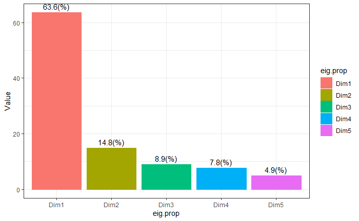

```r
jjstat::pcfa(R, nfactor = 2)
```

#### 3.2.2.1. 최대우도 요인분석(MLFA : Maximum Likelihood Factor Analysis)

MLFA는 최대우도법을 기반으로 하는 요인분석 방법이다. 최대우도법은 주어진 데이터를 가장 잘 설명하는 모수를 추정하는 기법으로, 요인분석에서는 잠재변수들의 모수를 추정한다. 또한 MLFA는 데이터의 분포를 가정하고 최대우도법을 적용하여 요인들을 추정하는 방법을 사용한다. `factanal()`함수를 사용하거나 psych 패키지의 `fa()`를 사용할 수 있다. 특히, `fa()`함수는 PCFA와 MLFA를 모두 지원하며, 요인의 수, 회전 방법, 요인부하량 등을 설정하여 요인분석을 수행할 수 있다.

```r
#factor analysis tools : factanal
mlfa <- factanal(Z, factors = 2, rotation = "varimax")
mlfa
```

```r
mlfa$loadings
```

```r
mlfa  %>%
  jjstat::pcfa_porp_plot(prop = F, ymax = 30)
```

```r
# library(semPlot)
#factanal diagram
semPlot::semPaths(mlfa, what="est", posCol="gray40",fade=T,
rotation = 2,style="lisrel",
sizeLat = 16, sizeLat2 = 10,
sizeMan = 14, sizeMan2 = 8,
nCharNodes=10, edge.label.cex=1.5)
```

```r
# library(psych)
# library(MVT)
library(GPArotation)

data(examScor)
 X = examScor
 psych::fa(X, nfactor=2)
```

#### 3.2.2.2. 탐색적 요인 분석

탐색적 요인 분석은 다음과 같은 것에 활용한다.

**(1) 데이터 탐색**: 탐색적 요인분석은 데이터의 특성을 파악하고, 변수 간의 관계를 이해하는 데 도움이 될 수 있다. 예를 들어, 고객 만족도 조사 데이터에서 어떤 요인이 고객 만족도에 영향을 미치는지 확인할 수 있다.

**(2) 변수 축소**: 다차원 데이터에서 주요한 요인들을 추출하여 변수의 수를 줄이는데 사용한다. 이를 통해 모델링이나 분석 과정에서 더 효율적으로 작업할 수 있다. 사회과학에서 복잡한 변수를 설명할 수 있는 주요 변수로 축소하여 현상을 설명하는데 도움이 된다.

**(3) 패턴 발견**: 탐색적 요인분석은 데이터 내에서 숨겨진 패턴이나 구조를 찾는 데 도움이 된다. 예를 들어, 소비자 구매 패턴에서 상품군 간의 연관성을 파악할 수 있다.

**(4) 변수 간 상호작용**: 요인분석은 변수 간의 상호작용을 이해하는 데 도움이 된다. 이를 통해 예측 모델을 개선하거나 정책 결정에 활용할 수 있다.

**탐색적 요인분석 vs 확인적 요인분석: 언제 어떤 것을 사용해야 할까?**

탐색적 요인분석은 아직 명확한 가설이 없을 때 새로운 변수들 간의 관계를 탐색하고 가설을 도출하는 데 활용된다.

확인적 요인분석은 이미 기존 이론이나 가설을 기반으로 한 요인 구조가 실제 데이터에 적합한지 검증하는 데 사용된다.

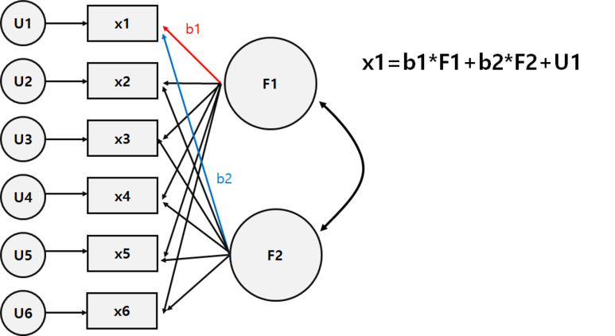

그림 요인분석

```r
# install.packages("ade4")
library(ade4)
data(olympic)
str(olympic)
```

**요인이 개수를 찾는 방법**

요인분석에서 중요한 것은 추출할 요인의 개수를 정하는 것이 가장 중요한데 이는 선행연구를 통해서 밝혀내는 것이 원칙이다. 밝혀낸다는 의미는 연구자가 미리 이론에 대한 연구, 선행연구 문헌들을 고찰하여 자신의 연구에 맞게 이론을 선정하고 연구모형을 만들고, 요인을 설정해야 한다. 그럼에도 불구하고 통계적으로 요인을 검토하는 방법들은 존재한다.  
요인개수를 선정하는 방법중 가장 유명하고 가장 많이 활용하는 것은 고유값(eigenvalue)이 1보다 큰 것을 찾아내는 카이저규칙이다. 분산이 1보다 작은 것은 변수 자신도 설명하지 못하는 것이기 때문이다.

```r
psych::fa.parallel(olympic$tab, fm="ml", fa="fa", n.iter=100)
```

2. nFactors 패키지의 nScree()를 이용하여 적정 요인 개수를 추천받기

```r
library(nFactors)
nFactors::nScree(olympic$tab)
```

4개의 방법 모두 2개가 적절하다고 추천하고 있다. 연구자가 요인을 얼마로 설정해야 할지 판단이 서지 않을때 활용하면 효과적이다.

```r
plotnScree(nScree(olympic$tab))
```

3. eigen value를 이용하는 방법

먼저 `cor()`을 이용하여 상관행렬 만든 후에 eigen()을 이용하여 분해한 값중에서 1보다 큰 값을 찾는 방법이다. 현재 데이터에서는 3.4182381 2.6063931 0.9432964, ….으로 가고 있으므로 1보다 큰 값은 2개이며, 이 데이터에 적합한 요인은 2개라고 판단할 수있다.

```r
eigen(cor(olympic$tab))
```

**factanal을 이용한 요인분석**

factanal(Perform maximum-likelihood factor analysis on a covariance matrix or data matrix) 함수는 R에서 데이터의 상관 구조를 고려하여 적은 수의 잠재변수(요인)로 설명하는 기법으로의 요인분석을 수행하는 함수이다. 이 함수는 최대우도법을 기반으로 하여 공분산 행렬이나 데이터 행렬에서 요인분석을 수행한다.

다음은 factanal 함수를 사용할 때 알아야 하는 주요 인자이다.

```
factanal(x, factors, data = NULL, covmat = NULL, n.obs = NA,
      subset, na.action, start = NULL,
      scores = c("none", "regression", "Bartlett"),
      rotation = "varimax", control = NULL, ...)
```

- x는 공식 또는 숫자 행렬 또는 숫자 행렬로 변환 가능한 객체이다.
- factors: 추출할 요인의 수를 지정한다.
- data: 데이터 프레임 또는 유사한 객체로, x가 공식일 경우에만 사용된다.
- covmat: 공분산 행렬 또는 cov.wt 함수로 반환된 공분산 리스트이다.

```r
fa <- factanal(olympic$tab, factors=2, scores="regression")
fa
```

요인을 회전시킨 결과

```r
 fa.p <- factanal(olympic$tab, factors=2, scores="regression", rotation ="promax")
fa.p
```

```r
library(GPArotation)
fa.o <- factanal(olympic$tab, factors=2, scores="regression", rotation = "oblimin")
fa.o
```

‘Loadings’ 이란 무엇인가?  
‘Loadings’ is a term from factor analysis, but because factor analysis and principal component analysis (PCA) are often conflated in the social science literature, it was used for PCA by SPSS and hence by princomp in S-PLUS to help SPSS users.  
Small loadings are conventionally not printed (replaced by spaces), to draw the eye to the pattern of the larger loadings. The print method for class “factanal” calls the “loadings” method to print the loadings, and so passes down arguments such as cutoff and sort.  
The signs of the loadings vectors are arbitrary for both factor analysis and PCA  
이 값은 요인적재값이라고 하는데, 요인적재값은 0.1보다 작으면 출력되지 않는다.

```r
print(fa$loadings, cutoff=0.001)
```

Loadings:  
Factor1 Factor2  
100 0.772 -0.089

이것을 해석하는 방법은 아래와 같다. Factor1과 Factor2의 선형결합으로 표현이 된다.

$$100=0.772\times (Factor1)+-0.089\times
(Factor2)+U_{100}$$

100이라는 변수의 분산은 Factor1에 의해서는 0.772의제곱인 59.6%가 설명이 되고 Factor2에 의해서는 (-.089)^2=0.8%가 설명된다는 의미이다. 통계는 분산의 마법과 같은 것이므로. 모든 것이 분산으로 설명된다고 생각하면 된다. 여기에서 두개를 합흔 60.4%가 두 요인에 의해 설명되는 변수100의 분산비율이다. 이것을 변수 100의 공통성(communality)라고 부른다. 공통성(communality)이라는 것은 공통요인에 의해서 섦여되는 분산의 비율이다. 값은 0~1사이의 값을 갖게 되는데, 공통성이 1이면 변수의 분산을 100%를 설명한다. 이 공통요인으로 설명이 안되는 것은 변수의 고유요인에 의해서 설명되는 것으로 가정하게 된다. 요인분석에서는 총분산에는 공통분산과 고유분산으로 나누어서 분석을 하기 때문이다. 고유요인에 의해서 설명되는 분산은 uniquenesses들어있다. 아래 그림을 참고해보자.

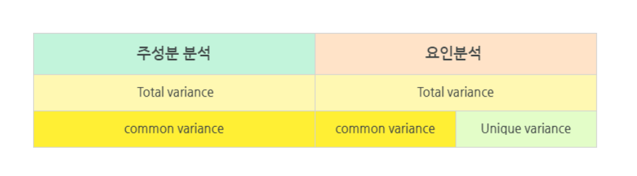

```r
print(fa$loadings, cutoff=0.5, sort = TRUE)
```

공통분산= 1 - 고유 분산

```r
round(1 - fa$uniquenesses, 3)
```

요인분석의 시각화

```r
# factor.plot(fa, labels=colnames(olympic$tab), pch=20, pos=4, title="Factor Plot")
```

```r
library(semPlot)
semPaths(fa, what="est", residuals=FALSE,
         cut=0.3, posCol=c("white", "darkgreen"), negCol=c("white", "red"),
         edge.label.cex = 1, title=TRUE)
```

# 4. 차이분석

차이분석은 카이제곱, t.test, 분산분석(ANOVA)에 이르는 전반적인 과정을 설명한다. 각각의 통계적 분석법에 대한 수식및 수기계산 그리고, 함수를 활용하여 가설 검정을 하는 과정을 설명하고자 한다. 독자는 계산과정에서 복잡하다고 느끼면 그 부분을 스킵(skip)하고 실제 함수를 이용하는 과정을 공부해도 된다. 다만, 분석의 노하우가 더 쌓이려면 분석하는 절차와 내용을 익히는 것이 중요함을 잊어서는 안된다.

## 4.1. Chi-square test

chisq.test performs chi-squared contingency table tests and goodness-of-fit tests

```
 chisq.test(x, y = NULL, correct = TRUE,
         p = rep(1/length(x), length(x)), rescale.p = FALSE,
         simulate.p.value = FALSE, B = 2000)
```

### 4.1.1. 적합도 검정

범주의 각 수준별 비율을 검정하는 방법이다.

$$X^2 = \sum_{i=1}^{k} \frac{(O_i -
E_i)^2}{E_i} \sim \chi^2(k-1)$$
$O_i$ : Observed frequency counts in each category
$E_i$ : Expected frequency counts in each category
$k$ : number of categrory
$df$: degree of freedom 모집단을 k개의 범주형 자료로 나누는 검정

카이제곱을 구하는 과정이다. 이 과정을 직접 계산하려면 다음과 같은 과정을 거친다.

‘차례로 생각해보면 개수나 횟수를 나타내는 데이터에서 기대도수를 구한 후에 관찰도수에서 기대소수를 뺀것을 제곱하고 기대도수로 나누어서 합을 구하면 카이제곱이 나오는 것이다.’ 아마도 수식을 말로 쓰니 와닿지 않을 수도 있다. 카이제곱 함수를 이용하면 금새 구해지는 과정이지만, 과정을 익히는 것도 중요하니 한번 과정대로 해보자.

먼저 Mendel(1865)의 데이터와 기대비율(유전형질)을 만들어보자. 멘델은 2세대 콩의 기대비율을 9:3:3:1로 설정하였다.

```r
## 데이터: Mendel(1865)의 유전법칙 : 형질별 콩의 개체수
df_chi = data.frame(
   observed = c(315, 101, 108, 32) ,
   p = c(9,3,3,1) ) # 기대비율
df_chi
```

기대값을 구할 때에는 영가설로 제시된 기대비율을 각각을 기대비율의 합으로 나눈후에 관찰된 값(observed)의 합과 곱하여 구한다.

$$E_{ij} = \frac {Row\;Total_i \times
Column \;Total_j} {n}$$

아래는 비율을 ratio로 하고 frac는 분수로 보여주기 위해서 구성한 것이다. fracture패키지를 이용하여 나타내었다.

```r
# 기대도수 구하기
df_chi0 <- df_chi %>% mutate(
                   ratio = p/ sum(p),
                   frac = fracture::fracture(p/ sum(p)),
                   expected =  sum(observed)*ratio)
df_chi0
```

이제 여기에 관찰도수 - 기대도수, 관찰도수-기대도수의 제곱, 기대도수로 나눈 값, 카이제곱을 데이터속에 순서대로 구해보자.

```r
df_chi0 %>%  mutate(
  `O-E` = observed - expected,
  `(O-E)^2` = `O-E`^2 /expected,
  chisq = sum(`(O-E)^2`)
)
```

이과정을 통해서 구한 카이제곱 값은 $\chi^2 = 0.470024$이다. 유의수준과 기각역 및 유의확률을 구해보자.  
카이제곱값이 0.47002이고 자유도는 $df = 4-1 = 3$이이므로 $p$값은 `pchisq()`함수를 이용하여 다음과 같이 구한다.

```r
1-pchisq(0.47002, df =3)
```

이 결과는 카이제곱분석결과 대립가설을 기각하고 영가설을 채택한다는의미가 된다.

x는 범주의 개수를 담고있는 벡터나 테이블 자료  
P는 영가설하 확률을 나타내고 있다. 멘델의 가설에서 가져온 결과이다.  
위에서 수기계산한 것을 이번에는 chisq.test() or jjstat::chisq_test()를 이용하여 계산해보자.

```r
chisq_test(x= c(315, 101, 108, 32), p = c(9,3,3,1)/16)
```

report패키지는 통계적 분서결과에 대한 결과보고를 APA양식에 맞추어서 보고해주는 패키지이다. 이 패키지를 이용하여 결과를 나타내보자.

```r
chisq_test(x= c(315, 101, 108, 32), p= c(9,3,3,1)/16) %>% report::report()
```

### 4.1.2. 동질성 검정과 독립성 검정

두 범주형 자료에 대한 검정으로 $r \times c$분할표(contingency table)를 만든후 이를 이용하여 chisq.test를 이용하여 동질성검정과 독립성 검정을 시행한다.

**동질성 검정 (Homogeneity Test)**:

목적: 동질성 검정은 한 가지 범주형 변수를 가진 여러 개의 모집단에서 데이터를 수집하여, 그룹 간의 분포가 동일한지를 확인하는 검정하는 방법을 말한다.  
예시: 여러 지역에서 다른 시기에 같은 조사를 통해 데이터를 수집하여, 그룹 간의 분포가 동일한지를 확인할 때 사용된다.

**독립성 검정 (Independence Test)**:

목적: 독립성 검정은 두 개의 범주형 변수 간의 관계를 확인하는 검정입니다. 두 변수가 서로 독립적인지 아니면 연관성이 있는지를 판단한다.  
예시: 성별과 선호하는 음료 종류 간의 관계를 확인하거나, 투표 결과와 지역 간의 관계를 확인할 때 사용된다.

요약하면, 동질성 검정은 여러 그룹 간의 분포를 비교하고, 독립성 검정은 두 변수 간의 연관성을 확인하는 것이다.

#### Perform homogeneity test

동질성 검정을 위해서 스마트폰(애플, 삼성, 회웨이)의 폰 사용이 연령별로 동질한지 검정해보자. 각 회사의 제품에 대한 사용경험을 10대, 20대, 30대의 모집단 그룹에서 추출한 결과이다. 그룹간의 분포가 동일한지 검정해보자.

가설은 아래와 같다.  
$H_0$ (귀무 가설): 그룹 간의 분포는 동일하다. $H_1$ (대립 가설): 그룹 간의 분포는 다르다

데이터는 아래와 같다.

```r
# Example data for homogeneity test (smartphone usage by age group)
homogeneity_data <- cbind(
   "Apple" = c(129, 195, 185),
  "Samsung" = c(185, 192, 126),
  "Huawei" = c(141, 194, 159)
)%>%`rownames<-`(c("10s", "20s", "30s"))

# homogeneity_data
homogeneity_data %>%addmargins()
```

이 교차표(contigency table)에 chisq.test을 통해서 확인해보자.

```r
# Print results
chisq.test(homogeneity_data)
```

동질성검정을 위한 카이제곱 분석 결과를 report패키지를 이용하여 해석해보자.

```r
chisq.test(homogeneity_data)%>%report::report()
```

통게적으로 유의한 결과가 나와 영가설을 기각할수 있다.

#### 독립성 검정

독립성 검정은 서울대, 고려대, 연세대에 합격한 남녀비율이 독립적인 확인하는 데이터이다.  
가설은 아래와 같다. $H_0$ (귀무 가설): 성별과 합격자수 결과는 독립적이다. $H_1$ (대립 가설): 성별과 합겹자수 결과는 연관성이 있다.

```r
# Example data for independence test (admissions by gender)


independence_data <- cbind(
  "Male Admissions" = c(96, 75, 71),
  "Female Admissions" =  c(95, 51, 55)
)%>%`rownames<-`(c("Seoul_National ", "Korea", "Yonsei"))

independence_data%>% addmargins()
```

카이제곰을통해서 독립성 검정이 가능하다. 두 변수의 독립성을 검정해보자.

```r
# Perform independence test
chisq.test(independence_data)
```

다음은 카이제곱 분석결과를 해석한 내용이다.

```r
chisq.test(independence_data) %>% report::report()
```

카이제곱을 계산하는 과정은 매우 중요한데, 이를 일일이 하기보다는 계산과정 함수를 만들었다.  
보통 $2 \times 2$형태의 검정에서 기대도수를 구하는 방법을 적용하여 다음과 같이 함수를 만들어서 분석해볼 수도 있다.

```r
# Define a function: Convert numbers to scientific notation or common number representations
format_number <- function(number, n=6) {
    # Use scientific notation when there are more than 18 decimal places
    if (nchar(sub("\\d+\\.", "", as.character(number))) >= n) {
        return(format(number, scientific = TRUE, digits = 3))
    } else {
        return(format(number, scientific = FALSE, digits = 5))
    }
}

chisqTest <- function(Obs, correct=FALSE, digits = 3, cat=TRUE) {
     Expected <- outer( rowSums(Obs), colSums(Obs)) /sum(Obs) #outer: 성분끼리의 곱

     if(correct){

       cat("\n  Pearson's Chi-squared test with Yates' continuity correction \n")
         chisquare <- sum(  (abs(Obs- Expected) - 0.5  )^2/ Expected  )
     }else{
      cat(" \n  Pearson's Chi-squared test\n")
       chisquare <- sum((Obs- Expected)^2/Expected)  #chi square 계산
     }



     df = (ncol(Obs)-1)*(nrow(Obs)-1) #자유도

     p_value = 1- pchisq(chisquare, df) #p값

     statistic <- cbind(Chisq = chisquare, df, p_value)

     rownames(statistic) = c("statistic")
     statistic<- statistic %>% jjstat::p_mark_sig("p_value") #%>%
      statistic$p_value <- format_number(statistic$p_value) %>%as.numeric()
      #  jjstat::Round(digits = digits)
    #  statistic
     if(cat){
     cat("\n", paste0( "X-squared = ",round(chisquare, digits),
                        ", df = ",df, ", p.value = ",
                        statistic$p_value," ", statistic$sig), "\n\n")
     }else{
     res2 = statistic
     res2
     }

}
```

```r
# independence_data %>% margin.table(margin = 1)

independence_data %>% margin.table(margin = 2)/margin.table(independence_data)
```

```r
chisqTest(independence_data)
```

```r
 MASS::caith %>% chisqTest()
```

```r
 MASS::caith %>% chisqTest(correct = TRUE)
```

독립성 검정과 동질성 검정

```r
#R base
table(mtcars$am, mtcars$vs) %>%
  chisq.test()
```

R함수에서는 X-squared = 0.34754가 나왔고, 우리가 만든 함수에서는 X-squared = 0.907가 나왔다. R함수에서의 값과 우리가 만든 함수의 값이 다르다. 그 이유는 셀이 기대값이 너무 작은 경우에는 correct를 조절해주어야 한다.

```r
table(mtcars$am, mtcars$vs) %>%  chisqTest()
```

다시한번 조절해서 해보자.

```r
table(mtcars$am, mtcars$vs) %>%  chisqTest(correct=TRUE)
```

혹은 R베이스에서 correct =FALSE로 해도 된다.

```r
table(mtcars$am, mtcars$vs) %>%
  chisq.test(correct=FALSE)
```

### 4.1.1. 일표본 t검정(onesample t.test)

t-test는 두 그룹의 평균을 비교하는 통계적 검정 방법이다. 주로 두 그룹 간의 차이가 우연히 발생한 것인지, 실제로 효과가 있는지를 확인하는데 사용한다.

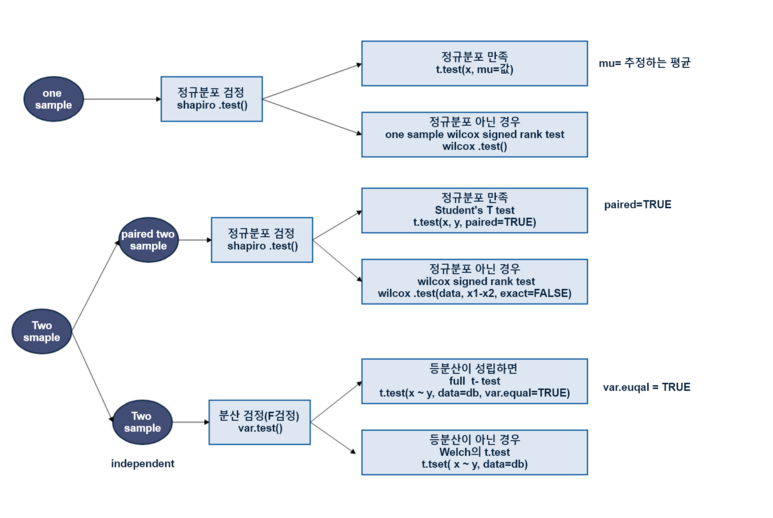

fig. t-test process

하나의 표본을 이용하여 모집단의 특정한 값과 같은지 추론하는 방법이다. 만약에 음료수를 사먹는데, 평균용량이 1L라고 할 때, 진짜 평균적으로 1L인지 샘플을 추출하여 평균을 구하여 일표본 t검정을 수행하면 된다.

검정에 필요한 t값은 다음과 같이 계산한다.

$$t =
\frac{m-\mu}{\frac{s}{\sqrt{n}}}$$

$\mu$는 평균, $n$:샘플사이즈, $s$:샘플의 표준편차

결과를 해석할 때에는 p값을 기준하여 설명하면 된다. $p < .05$이면 귀무가설을 기각하고 대립가설을 받아들인다. 즉, 표본평균은 이론적 평균과 유의하게 다르다는 결론을 내릴 수 있다.

예) 학생들의 기말고사 성적은 95%의 신뢰수준에서 볼때 24점보다 유의하게 높은 가?  
귀무가설: 학생들의 성적은 24점과 같다.

대립가설: 학생들의 성적은 24점보다 높다

*사용하는 방법*

```
t.test(관측치, alternative = 판별 방향, mu=특정기준, conf.level = 신뢰수준)
```

```r
#단일표본 t test
final <-  c(19, 22, 24, 24, 25, 25, 26, 26, 28, 32)
shapiro.test(final)

t.test(final, mu=24, alternative="greater", conf.level = .95)
```

결과를 요약하면 다음과 같다. 정규성 검정(Shapiro-Wilk normality test)결과 정규성은 확보되었다($W$ = 0.96, $p$ = 0.7332)

```
 The One Sample t-test testing the difference between final (mean = 25.10) and mu = 24 suggests that the effect is positive, statistically not significant,and small (difference = 1.10, 95% CI [23.10, Inf], t(9) = 1.01, p = 0.170.
```

```r
t.test(final, mu=24, alternative="greater", conf.level = .95)  %>%
  report_stat("t.test", trans = FALSE)
```

### 4.1.2. t검정 이해

- 두변수간 평균 비교
- 두 집단간 평균 비교

#### 4.1.2.1. 등분산성 검정

영가설: 등분산을 이루고 있다. $p >.05.$  
대립가설: 등분산을 이루지 않는다 $p < .05.$

등분산인 경우와 등분산이 아닌 경우에 사용하는 t값은 다르게 사용된다.

$$t =
\frac{(X_1-X_2)}{\sqrt{s_{pooled}^2×(\frac{1}{n_1} + \frac{1}{n_2}})
}$$

로 사용한다.이때 공통분산(pooled variance)는
$$s_{p}^2 = \frac{(n_1-1)S^2_1 +
(n_2-1)S^2_2} { n_1 + n_2 -2}$$
이다.

만약에 등분산이 아니라면 t값은 다음과 같이 사용한다.
$$t =
\frac{(X_1-X_2)}{\sqrt{(\frac{s_1^2}{n_1} +
\frac{s_2^2}{n_2})}}$$

자유도가 많이 복잡한 상태로 변경되어 사용된다.

###### (1) var.test()

var.test는 F검정(F Test to Compare Two Variances )이라고도 한다.

var.test는 다음과 같은 경우에 사용한다.  
(1) 두 표본의 분산이 동일한지 여부를 확인하고 싶을 때  
(2) 두 집단의 변동성이 서로 다르다는 것을 증명하고 싶을 때  
(3) t-검정을 수행하기 전에 두 표본의 분산이 동일한지 여부를 확인하고 싶을 때

```
* 귀무 가설 (H0): 두 표본의 분산은 동일하다.
* 대립 가설 (H1): 두 표본의 분산은 다르다.
```

F콩식은 다음과 같이 나타낼 수 있다.  
Performs an F test to compare the variances of two samples from normal populations.

$$F = \frac{S_12}{S_22} = \frac{\sum (X_i
- \bar{X})^2 / (n_1 - 1)}{\sum (Y_i - \bar{Y})^2 / (n_2 - 1)}$$
$F$ 는 검정 통계량 $S_1^2$ 와 $S_2^2$는 각각 첫 번째와 두 번째 집단의 표본분산 $X_i$와 $Y_i$는 각 집단의 관측값 $\bar{X}$와 $ {Y} $는 각 집단의 표본 평균 $n_1$과 $n_2$는 각 집단의 표본 크기

다음은 mtacars데이터에서 vs에서 0과 1의 그룹에 대한 등분산 가설검정이다.

```r
 var.test(mpg ~ vs, data = mtcars)
```

F검정결과, 현재의 vs데이터에 대한 등분산 검정은 p값이 0.05보다 크므로, 귀무가설을 기각할 수 없다. 즉, 등분산을 가정할 수 있다. 만약에 이 결과를 표로 만들어서 논문에 넣으려고 한다면 다음과 같이 tidy()함수를 이용하여 정리된 형태를 저장하여 편집하면 된다.

```r
var.test(mpg ~ vs, data = mtcars)  %>%
  broom::tidy()
```

jjstat패키지에서 var.test에 대한 분석결과를 간략하게 해석해줄 수 있다.

```r
 var.test(mpg ~ vs, data = mtcars) %>%
  jjstat::report_stat("var.test", trans= TRUE, show="data")
```

###### (2) bartlett.test

bartlett.test는 모수적 등분산 검정 방법이다. 비모수적 방법으로는fliger.test()를 사용한다.  
Bartlett 검정은 두 개 이상의 모집단의 분산이 동일한지 검정하는 모수적 검정 방법이다. 일반적으로 ANOVA 등 분산 분석을 수행하기 전에 가정하는 등분산성을 검증하는 데 사용된다. Bartlett검정의 일반적인 가정은 각 모집단은 정규 분포를 따른다는 것과 각 모집단의 변수는 서로 독립적이라는 사실이다.

Bartlett 검정의 검정 통계량은 다음과 같이 계산된다.

$$T = -2 × ln(L)$$
$$L = (n - 1) × ln(S^2) + ∑(n_i - 1) ×
ln(S_i^2)$$

$n$: 전체 표본 크기  
$n_i$: i번째 그룹의 표본 크기  
$S^2$: 전체 표본의 분산  
$S_i^2$: i번째 그룹의 분산

Bartlett 검정의 가설은 다음과 같다.  
- 귀무가설 ($H0$): 모든 모집단의 분산은 동일합니다. - 대립가설 ($H1$): 모든 모집단의 분산은 동일하지 않습니다.

Bartlett 검정의 p-값은 검정 통계량 T가 $χ^2$ 분포에서 $df = k - 1$ 자유도를 가지고 발생할 확률이다. p 값이 유의수준 ($α$)보다 작으면 귀무가설을 기각하고 대립가설을 채택한다.  
표본 크기가 작거나 모집단의 분포가 정규 분포를 따르지 않는 경우 Bartlett 검정의 결과가 정확하지 않을 수 있다.

```r
bartlett.test(mpg~vs,mtcars)
```

bartlett.test결과, p값이 0.05보다 커서 귀무가설을 기각할 수 없다. 따라서, 두 변수는 등분산이라고 할 수 있다.

###### (3) leveneTest()

car 패키지에는 Computes Levene’s test for homogeneity of variance across groups라고 설명되어 있다. 르벤테스트는 SPSS에서 사용하고 있어서 유명한 등분산 검정이다. Levene 검정은 두 개 이상의 모집단의 분산이 동일한지 검정하는 비모수적 검정 방법이다. ANOVA 등 분산 분석을 수행하기 전에 가정하는 등분산성을 검증하는 데 사용된다. Bartlett 검정과 달리 모집단의 분포에 대한 가정을 하지 않아 더 넓은 범위의 상황에서 사용할 수 있다.

Levene 검정의 검정 통계량은 다음과 같이 계산됩니다.

$$W = \frac{(N - k) \sum_{i=1}^{k} n_i
(X_{i.} - \overline{X})^2} {k \sum_{i=1}^{k} \sum_{j=1}^{n_i} (X_{ij} -
X_{i.})^2}$$
$N$: 전체 표본 크기 $k$: 그룹 수 $n_i$: i번째 그룹의 표본 크기 $X_{i.}$: i번째 그룹의 평균 $X_{ij}$: i번째 그룹의 j번째 데이터 $overline{X}$: 전체 표본의 평균

Levene의 가설  
귀무가설 ($H0$): 모든 모집단의 분산은 동일합니다.  
대립가설 ($H1$): 모든 모집단의 분산은 동일하지 않습니다.

Levene 검정의 p-값은 검정 통계량 W가 F 분포에서 $df1 = k - 1$, $df2 = N - k$ 자유도를 가지고 발생할 확률이다. p값이 유의수준 ($α$)보다 작으면 귀무가설을 기각하고 대립가설을 채택한다.

mtcars에서 vs에 따른 mpg의 등분산 검정

```r
car::leveneTest(mpg ~ factor(vs),mtcars)
```

##### (4) 비모수검정 Fligner-Killeen 검정 (Fligner-Killeen test)

Fligner-Killeen 검정은 두 개 이상의 모집단의 분산이 동일한지 검정하는 비모수적 검정 방법이다. Levene 검정과 유사하지만, 순위 통계를 사용하여 검정 통계량을 계산하기 때문에 더 정확한 결과를 제공할 수 있다. 특히, 표본 크기가 작거나 모집단의 분포가 정규 분포를 따르지 않는 경우 유용한 방법이다. 비모수 검정을 사용하는 경우 chi-square(카이제곱)으로 통계치가 나타난다.

Fligner-Killeen 검정의 검정 통계량은 다음과 같이 계산된다.

$$F = \frac{12}{n(k-1)} \sum_{i=1}^{k} n_i
\sum_{j=1}^{n_i} R_{ij}^2$$
$n$: 전체 표본 크기 $k$: 그룹 수 $n_i$: i번째 그룹의 표본 크기 $R_{ij}$: i번째 그룹의 j번째 데이터의 순위

귀무가설 ($H0$): 모든 모집단의 분산은 동일합니다.  
대립가설 ($H1$): 모든 모집단의 분산은 동일하지 않습니다.

Fligner-Killeen 검정의 p-값은 검정 통계량 F가 χ^2 분포에서 $df = k - 1$자유도를 가지고 발생할 확률이다. p값이 유의수준 ($α$)보다 작으면 귀무가설을 기각하고 대립가설을 채택한다.  
Fligner-Killeen 검정은 Levene 검정과 유사하지만, 순위 통계를 사용하기 때문에 더 정확한 결과를 제공할 수 있다. 표본 크기가 작거나 모집단의 분포가 정규 분포를 따르지 않는 경우 Fligner-Killeen 검정을 사용하는 것이 좋다.

```r
fligner.test(mpg ~ vs,data= mtcars)
```

```r
plot(mpg ~ vs, data= mtcars)
```

### 4.1.3. 독립표본 t검정

등분산 검정(동질성 검정)결과, vs의 두 개의 레벨은 등분산이므로 var.equal = TRUE로 해서 분석을 한다.

```r
t.test(mpg ~ vs, data= mtcars, var.equal = TRUE)
```

보고서 작성

```r
t.test(mpg ~ vs, data= mtcars, var.equal = TRUE) %>%
  jjstat::report_ttest( trans =TRUE)
```

##### 4.1.3.1. 등분산이 아닌 경우

등분산이 아닌 경우에는 var.equal = FALSE로 하게 되는데 이 경우에는 Two sample t-test가 아닌 Whelch Two t-test를 수행한다. 자유도가 바뀌어서 나타나게 된다.

```r
t.test(mpg ~ vs, data= mtcars, var.equal = FALSE)
```

다음은 jjstat패키지의 report_ttest를 이용하여 보고서를 작성한 경우를 나타낸 것이다.

```r
t.test(mpg ~ vs, data= mtcars, var.equal = FALSE) %>%
  jjstat::report_ttest(trans = TRUE)
```

ex) 오렌지 주스와 비타민을 복용시킨 2개의 그룹에서 기니피그의 이빨길이는 통계적으로 유의미한 차이가 있는가?

A data frame with 60 observations on 3 variables.  
[,1] len numeric Tooth length  
[,2] supp factor Supplement type (VC or OJ).  
[,3] dose numeric Dose in milligrams/day

```r
# Two-samples unpaired test
data("ToothGrowth")
ToothGrowth %>%str()
```

**1. 등분산 검정**

```r
var.test(len ~ supp, ToothGrowth)
```

귀무가설:H0:등분산이다.  
F검정결과 두 변수는 등분산을 충족하였다, *F*(29) = 0.64, *p* = 0.23.

```r
t.test(len ~ supp, data = ToothGrowth, var.equal=TRUE)
```

**APA보고**  
기니피그의 supplement(오랜지주스와 비타민C)이 차이에 따른 이빨길이의 차이에 대하여 독립표본t검정을 시행한 결과 유의하지않았다, *t*(58) = 1.92, *p* =.06.

**report package**를 이용한 결과

```r
t.test(len ~ supp, data = ToothGrowth, var.equal=TRUE) %>%
  jjstat::report_ttest()
```

##### 4.1.3.2. t.test 요약보고 함수

이번에는 필자가 개발한 jjstat package에 있는 t_test_report()함수를 이용하여 독립표본 t검정을 진행해보자. 이 함수는 먼저 var.test를 통하여 분산의 동질성 검정을 시행한다. 그리고 var.test의 결과에 대한 결과보고를 해준다. 이후에는 t.test()를 수행한 후에 t.test의 결과에 대한 보고를 해준다. 그리고 평균을 비교하는 것을 시각화하기 위해서 boxplot을 그려서 보여주는 함수이다.  
위에서 배운 개념을 모두 활용하는 것들을 모아서 보여주는 함수이다. 분석을 하면서 여러가지를 편리하게 만들어주는데 중요한 것은 t.test에 대한 깊은 이해를 한 후에 나타나는 결과는 매우 편리하게 만들어주지만, 정확한 이해없이 사용하면 그저 복잡한 결과만 출력되는 것이 된다. 따라서, 명확하게 인식하고 사용하는 것이 중요하다.

```r
jjstat::t_test_report(data = ToothGrowth,
              iv= "supp",
              dv="len",
              translate = FALSE)
```

### 4.1.4. 대응표본 t검정

대응표본 t검정은 주로 실험에서 많이 쓰이는데, 어떤 처치에 대한 효과를 알아보고자 할 때 사용하는 경우가 많다.

예를 들면, 아래의 데이터는 시험데이터이다.  
학생이 중간고사를 본 후에 학원을 다녔다. 이후에 기말고사를 보았다. 학원을 다닌 후에 성적의 차이가 유의하게 나타났는지 검정해보고자 하였다.

대응표본 t-test는 분산의 동질성 검정을 하지 않는다. 같은 그룹에서 표집을 진행했기 때문이다.

$$t = \frac{d1-d2}{SE} = \frac{차이값의
평균}{차이값의 표준오차}$$
표준오차는
$$SE = \frac{sd}{\sqrt{(n)}}$$
으로 계산한다. t의 임계값을 구하여 유의성을 검정하거나 p값을 구하여 통계적 유의성을 검정한다.

ex) 시험성적은 학원을 다닌후에 유의하게 향상되었을까?

| mid | final |
| --- | --- |
| 16 | 19 |
| 20 | 22 |
| 21 | 24 |
| 22 | 24 |
| 23 | 25 |
| 22 | 25 |
| 27 | 26 |
| 25 | 26 |
| 27 | 28 |
| 28 | 32 |

이 데이터를 롱포맷으로 만들어서 분석해보자.

```r
exam_long = data.frame(
  grp = factor(c(1:10, 1:10)),   #group
  test = c(rep("a_mid", 10), rep("b_final", 10)),  #variable
  score = c(16, 20, 21, 22, 23, 22, 27, 25, 27, 28,
            19, 22, 24, 24, 25, 25, 26, 26, 28, 32)
)
exam_long
```

```r
exam_long  %>%
  ggplot(aes(x = test, y = score))+
  geom_point(size = 4, aes(col= grp))+
  geom_line(aes(group = grp))+
  ggrepel::geom_text_repel(aes(label = score), hjust = 1, vjust= -.4)+  #겹치지 않게
  labs(title = "paired data")+
  theme_bw()+
  theme(axis.text =element_text(size=14),
        axis.title = element_text(size=14))
```

```r
t.test(score ~ test, data= exam_long, paired=TRUE)
# exam_long
```

paired t.test결과, 학원을 다닌후에 성적을 유의하게 올랐다고 할 수 있다, t(9) =-4.47, p = .002.

데이터가 롱포맷이면 수식을 이용하여 분석한다. 종속변수 ~ 독립변수로 입력하면된다.

```r
library(report)
t.test(score ~ test, data= exam_long, paired=TRUE) %>%
  report_ttest()
```

##### 데이터가 와이드 포맷인 경우

데이터가 와이드포맷일 때에는 변수명을 선택하여 분석하면 된다.

```r
#데이터 생성
exam = cbind.data.frame(
  mid = c(16, 20, 21, 22, 23, 22, 27, 25, 27, 28),
  final = c(19, 22, 24, 24, 25, 25, 26, 26, 28, 32) )
exam
```

t.test(변수1, 변수2, paired=TRUE)의 형식으로 분석하면 된다.

```r
t.test(exam$mid, exam$final, paired= TRUE)
```

paired t.test결과, 학원을 다닌후에 성적을 유의하게 올랐다고 할 수 있다, $t$(9) = -4.47, $p$ = .002.